# 助推2.0（助推如何改变社会和我们的生活？为个人、组织和社会改变的实现提供有效路径,哈佛大学法学院教授、《噪声》《助推》作者卡斯·桑斯坦全新力作）

卡斯·R.桑斯坦

2022-01-09T16:00:00+00:00

[figure not shown]

版权信息

本书纸版由四川人民出版社于2022年1月出版

作者授权湛庐文化（Cheers Publishing）作中国大陆（地区）电子版发行（限简体中文）

版权所有·侵权必究

书名：助推2.0

著者：卡斯·R．桑斯坦

电子书定价：116.99元

HOW CHANGE HAPPENS

Copyright © 2019, Cass R. Sunstein

All rights reserved

# 测一测

### 你了解助推吗？

● 自助餐厅里食品的摆放方式会影响人们的选择。这是真的吗？

A．真

B．假

● 人类有两种思维方式，直觉思维系统和理性思维系统，这是真的吗？

A．真

B．假

● 人们在大多数情况下会接受默认的规则，以下哪项不是其中的原因？

A．人们的惯性和拖延

B．主动选择有风险，默认规则相对比较安全

C．人们无法做出自主选择

D．损失厌恶

扫码鉴别正版图书  
获取您的专属福利

[figure not shown]

扫码获取全部测试题及答案，  
测一测你了解助推吗

我们都是表现主义的一部分。有时候，我们只是想对不公正发声，或者想站起身让旁人意识到自己的存在。这些都是高尚的动机，但任何严肃的革命家都必须常常提醒自己不要沉溺于表现自我的乐趣中。必须通过给制度带来的最终影响来检验自己的行为。

——赫伯特·西蒙（Herbert Simon）

# 目 录

前言 改变是如何发生的

第一部分 社会规范与价值

第1章 社会规范的力量

政治正确的影响

社会规范的修订

偏好掩饰与规范倡导者

从开始对抗到社会规范的坍塌

社会级联效应

可用性启发式

思维方式的革命

部分自适应偏好

歧视者的偏好

公开与匿名

规范内化行为

第2章 群体极化现象

群体极化的产生

风险转移与谨慎转移

愤怒启发式

对群体极化的解释

进一步理解群体极化

迭代极化博弈

推动群体极化

孤立的局外群体

纷争与冲突

舆论飞地与被压制的声音

第3章 法律的表达功能

法律表达的引导作用

解决集体行动问题

法律进行价值引导的风险

以金钱为行为动机的社会规范

社会规范与平等

关于法律的价值引导作用的两个基本问题

第二部分 助推的作用与局限

第4章 助推

选择的自由

透明度与有效性

助推的实证检验

10类重要的助推

实施助推的最佳方法

第5章 助推与选择

主动选择的意义

选择者的选择

促使选择的家长主义

家长主义是正当的吗

第6章 助推与福利

第7章 无效的助推

为何默认规则能被接受

强烈的先验偏好

反助推

如果助推失效该怎么做

助推无效的5种原因

第8章 助推与道德

选择与默认规则

7种对助推的反对意见

助推的道德问题

第9章 助推与控制权

委托人、代理人与理性选择

控制权溢价

实施控制的缘由与时机

第10章 助推与命令

关于命令的5个反对理由

有关命令的例证问题

降低风险

第11章 助推与评估

消费者的评估

政治领域的评估

全局评估与现实生活

少即是多吗

联合评估与单独评估

如何赢得朋友并影响他人

净福利收益

法律与政策

条件价值评估法

评估助推

福利与经验

第三部分 加速改变的力量

第12章 透明度

透明度的作用

信息披露的根本使命

输入透明度

谁对谁说了什么

输入透明度出现的两种条件

输入透明度的成本

输入透明度的分类账

第13章 预防性原则

什么是预防性原则

自相矛盾的预防性原则

预防性原则的运作

损失厌恶

可得性启发式

不确定性与不可逆性

更宽广的视野下

第14章 道德启发式

一般性启发式与古尔德的小矮人

道德启发式的作用

弱结果主义

进化与规则功利主义

道德启发式与法律及政策的关系

离奇案例的道德判断与反思均衡

第15章 权利

电车难题与天桥困境

神经系统科学领域的证据

行为证据与义务论

义务论思维

道德推理与道德合理化

嘈杂的直觉

第16章 美国的党派主义

内隐联想测验

爱情与婚姻

面试中的偏好

党派主义观念与实际行为的关系

一种反对之声

美国党派主义的成因

政治极化

僵局理论

3种对党派主义的可能解决方案

制度评价的脆弱性

结语 源自社会规范的约束效应

注释

# 前言

### 改变是如何发生的

社会改变是如何发生的？其中一个答案是社会规范的作用，它既可能是强大的（对行为产生较大影响），也可能是脆弱的（短时间内就会坍塌）。如果规范使人们保持沉默，那么即使有人或许多人讨厌现状，或那些看似支持现状的人实际上对其漠不关心，现状也会持续下去。直到有一天，有人提出了挑战：也许是说出了皇帝并没有穿衣服的事实的那个孩子。在这个小小的挑战之后，其他人可能也会开始说出他们的想法。一旦这种情况发生，就会形成燎原之势。

我们中的大多数人，至少在某些时候，是依照自己所厌恶的规范生活的。我们可能不会去探究，因为这就像家居生活的一部分。但在内心深处，我们却可能在厌恶这些规范。可问题是，没有人能靠自己改变一项规范。诚然，我们可以挑战一项规范，但挑战是有代价的，且挑战的最终结果可能是巩固而非打破现有的规范。我们需要的是由那些明确表示不赞同这项规范的人发起运动，当达到某个临界点时就会成功；到那时，说出“我也是”几乎没有社会成本，并且也许是有益的，甚至是义务性的。

同样的动态过程也存在于一系列社会运动中，其中包括那些众所周知的政治性或社会性大事件，如法国大革命、年龄歧视和奴隶制废除等。当然，这些运动在诸多重要方面的意义是不同的，其中一些无疑是好的，而另一些难以评估，还有一些则令人深感不安。但在所有这些事件中，被压抑的信仰、价值观和愤怒都会重获生机。一旦人们行动起来，改变将不可避免。

预测这些社会运动很困难，甚至是不可能的。其中一个主要原因是人们会掩饰自己的偏好，同一社会中的个体并不知道彼此的真实想法。存在偏好掩饰的情况正是释放社会改变信号的恰当时机，但又因为偏好是经过掩饰的，所以很少有人能意识到这个事实。

另一个原因是社会互动的首要性。要使改变发生，需要通过互动在适当的时间和地点产生一种日益强烈的认识，即现有的规范是脆弱的。这种认识可能会出现，也可能不会出现。机缘巧合可能至关重要：谁在恰当的时候与谁进行了交谈？报纸在恰当的时候报道了什么？谁又在恰当的时机转发了什么？

科幻作家往往喜欢探索“反事实历史”（counterfactual history）：南方赢得了美国南北战争，约翰·肯尼迪没有遇刺，唐纳德·特朗普决定使自己的房地产事业再上新台阶而不是竞选总统。在他们看来，最有趣的是强调反事实历史引发了巨大改变这一过程中的小转变（或助推）。他们让人们相信，只要稍加推动或拉动，整个社会最终可能会变得截然不同。

但历史不能重演，我们不知道什么时候才是真理时刻，但我们确实在短时间内看到了巨大的转变。如果对导致这些转变的机制有所了解，我们可能会重新意识到，现在认为理所当然的事情在多大程度上并非完全是命中注定的，以及如何在适当的时候施加一点助力，未来几十年可能就会走上完全不同的道路。

本书共有16章。虽然并未构成一个整体的叙述，但它们之间是存在联系的。这种联系在于将行为科学的发现与法律和政策中的长期问题结合起来，并努力向人们阐释：看似微小的扰动往往可以引发巨大的变化。本书的前3章探讨了社会规范的力量、社会级联效应（social cascades）的重要性、群体极化现象以及法律的表达功能。我要强调的是，在多数情况下，人们的思想得到了解放，不管这是好还是坏；而在其他情况下，一些非常不同的事情发生了，因为人们最终持有了他们以前不会持有的观点。这一部分的主题是从不可言说甚至不可想象的观点向传统观念转变（反之亦然）。

第4章到第11章探讨了“助推”作为改变工具的优势和局限性。这里的问题是，公共或私营机构如何通过看似微小的步骤改变甚至“放纵”人们的行为。

助推是一种保留选择的干预措施，由行为科学提供信息，可以极大地影响人们的选择。助推并不是什么新鲜事物。在《创世记》中，上帝轻轻地说:“你可以随意吃园中所有树上的果子；唯独分辨善恶树上的果子，你不可以吃，因为你吃的那天就是你的忌日。”蛇也是一个助推者:“上帝知道，当你吃它的时候，你的眼睛会睁开，你将像上帝一样知道善恶。”上帝和蛇以威胁、承诺，以及一种独特的架构，维护了选择的自由。

近年来，政府官员在助推项目方面开始变得训练有素起来，他们往往会借鉴最新的行为科学研究成果。有时他们会跨过助推，征集关于人为错误的调查结果，包括“现状偏差”（present bias）和不切实际的乐观主义，以证明授权和禁令（或征税）是合理的。在这里，我会尝试探讨当前最紧迫的话题，这些话题在法律、经济和政治哲学等多个领域引发了深刻的问题。例如：评估助推的标准是什么？我们该往哪边助推？什么时候助推会失败？当助推失败时，我们应该怎么做？助推是否合乎道德？人们控制自己命运的欲望又如何呢？

在回答这些问题的过程中，我强调了两个相互矛盾的要点。第一个要点涉及人的主观能动性的重要性。人们常说:不要告诉我什么事不能做！这是人们发自内心的呼唤，表明人们重视自己控制生命进程的能力，应该被理解、欣赏和珍惜。

第二个要点涉及合法使用强制手段。在某些情况下，授权或禁令是合理的，至少在我们关心人类福祉的情况下是这样。如美国的反式脂肪禁用令、社会保障项目、能效要求及香烟税。在过去的10年里，助推一直是行为科学应用领域讨论的主题。鉴于自由和能动性的重要性，这没什么好抱怨的。但是，如果我们真的关心人类福祉就会发现，我们正处于更认真地思考更激进的工具和定义这些工具在何种情况下更有意义的早期阶段。

第12章到第16章探讨了公共政策、行为科学和政治哲学领域的交叉问题。我认为，透明度通常是至关重要的，因为它促进了问责制，也允许人们获得可以用来改善自己生活的信息。透明度可以起到极大的助推作用，并且往往会推动社会改变。

我认为，在许多国家流行的预警原则（Precautionary Principle）是一种概念上的混淆，因为它禁止了预警原则所要求的关键步骤，而我们可以通过参考行为科学的研究成果来更好地理解它的流行及其表面上的混乱。或许最具争议的是，我建议最好将对人权的一些思考理解为“道德启发式”（moral heuristics）的产物，即简单的经验法则。这通常是明智的，也是获得人类福祉这一最重要事物的一种天然方式。最后，我讨论了美国“党派主义”的兴起。在某些方面，党派主义是社会改变的一大障碍，尤其是在国家立法层面。但是，正如我们将看到的，探索出一条有希望的前进之路仍然是有可能的。

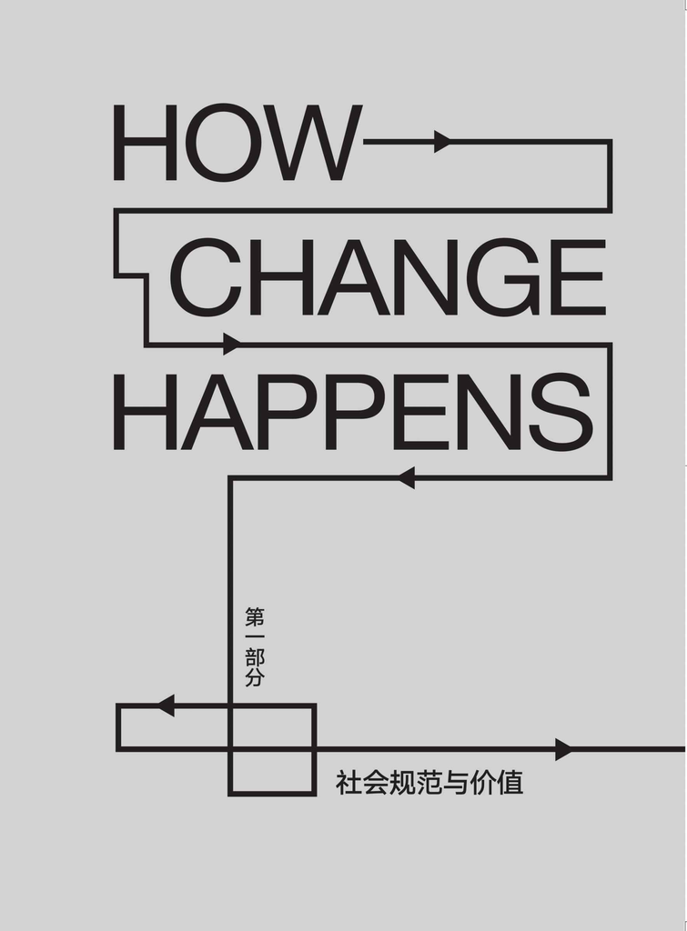

# 第1章 社会规范的力量

20世纪80年代末，我在哥伦比亚大学法学院担任客座教授时，有一次在办公室附近的走廊上撞见一个法律系的女学生和一个年长的男教授正在交谈。我惊讶地发现教授竟然在摩挲女学生的头发，我确信有一瞬间我看到她的脸因反感而扭曲，不过扭曲的神情只是一闪而过。教授离开后，我对她说：“教授的做法非常不合宜，他不应该那样做。”她却不屑地说：“没关系，他是个老人，这样做真的没问题。”

但30分钟后，我听到一阵敲门声。那个女学生泪眼婆娑地站在门口，哭诉道：“教授总是做出那样的举动，实在是太可怕了。我男朋友认为我应该义正词严地反对，但我不想这样做，真的，我不想大惊小怪。你可千万不要和教授谈论这件事，也不要告诉任何人。”

社会规范犹如枷锁，束缚了这名法律系学生的言行。尽管她讨厌教授的所作所为，感到自己被骚扰了，并且听到我的微词后，她也愿意告诉我她的真实想法，但现有的规范依然使她畏首畏尾、不敢反抗。

有趣的是，我发现社会上存在着两种针对社会规范的不同主张。第一种主张认为，当社会规范开始坍塌时，人们就会得到解放，即人们可以自由地表达自己的信仰和偏好，谈论过去难以启齿的经历，随心所欲地交往和生活。当然，旁观者在这个解放过程中起着重要作用。新的社会规范及相关法律可能会将人们的信仰、偏好和价值观展露于世人面前。这一发现是振奋人心的。它还可用于解释20世纪60年代的民权运动、女权运动、残疾人权利运动和反堕胎运动。

第二种主张认为，社会规范的修订有助于构建新的偏好和价值观。新的规范及相关法律有助于催生不同于以往的信仰、偏好和价值观。在这个过程中，人们不是被解放了，而是被改变了。禁烟运动和安全带的推行就是最好的例证。

就第一种人们得到解放的情境而言，当某些规范生效时，人们会掩饰自己的偏好或保持沉默。因此，陌生人甚至朋友和家人可能都无法了解他们的真实偏好。<sup>1</sup>某些拥有特定政治或宗教信仰的人索性三缄其口。一旦社会规范得到修订，人们便会重拾先前被压抑的偏好和价值观。曾经遮遮掩掩的想法，如今可以大方地谈论；曾经不敢妄想之事，转眼成为现实。

上述观点可以解释前例中女学生被性骚扰一事：女性不喜欢甚至十分厌恶被骚扰，因此修改旧有社会规范对于鼓励她们勇敢表达自己的情感和信仰来说至关重要。<sup>2</sup>显然，法律在维护既有社会规范或加快其修订进程方面经常发挥着重要作用。<sup>3</sup>禁止性骚扰的司法规范之所以重要，部分原因就在于它有助于纠正陋习。<sup>4</sup>正如选举新的领导人或颁布新的法案往往传递出一个关键的甚至是变革性的信号一样，它为人们提供了关于他人想法的信息。<sup>5</sup>又由于人们会受到自认为的他人想法的影响，因此一旦人们接收到这个信号，社会规范的变迁便应运而生。<sup>6</sup>

但是一些规范的修订及相关法律并不能使人们得到解放。随着规范被修订，人们开始持有或假装持有他们从未有过的偏好和价值观。规范的修订及相关的法律改革并不能释放被压抑的欲望，它们只是催生了新的欲望，或者至少是与新的欲望一致的言行。

### 政治正确的影响

现在来看看“政治正确”（political correctness）这一概念。在美国，政治正确指的是“左倾”的社会规范，它严禁人们表达与左派正统观点相悖的观点，从而使一部分人噤若寒蝉。政治正确意味着人们不能吐露自己的心声，他们犹如被锁入某种“密室”。“密室”这一术语应被视为试图与现有规范作斗争的一种努力。此术语的巧妙之处在于，它将那些遵循现行观点的人视作懦弱的墨守成规者，而不是不畏艰难困苦实现道德准则变革的勇士。<sup>7</sup>“政治正确”在现实中屡见不鲜。在美国的许多大学校园里，那些持右倾观点的人不再言论自由，他们学会了保持缄默以明哲保身。这是多么可怕的事情：他们被束缚住了。若置身于其他的社会规范中，他们则能说出自己的真实想法。因此，有时他们的朋友和同事会感到惊讶，甚至震惊：“他真的这么认为吗？我不知道。”

在美国的教育领域，政治正确带来的一个问题是左派学生并不清楚社区内意见的真实分布情况，因为他们可能误以为每个人都与自己无异，都保持左派立场。政治正确带来的另一个问题是人们越来越难以从差异化的见解中相互借鉴和学习。但是当人们勇于表达真实想法时，情况或许会发生明显的变化。20世纪80年代初，我在芝加哥大学法学院任教，当时一群优秀的学生创建了联邦党人学会（Federalist Society），这是一个致力于探索和捍卫以保守立场看待美国法律制度的组织。联邦党人学会对美国的政治和法律生活产生了巨大的影响，因为它创建了一个论坛或者说一方净土，人们可以在那里畅所欲言。

但是，无论是左派还是右派，政治正确的触角都超越了对观点的压制。它还试图重建人们的偏好和价值观，使某些观点变得不可思议，无论这种做法对社会而言是利还是弊。如果某些观点超出了政治正确的范围，人们便不再说下去。最终，这些观点可能再无人问津。这是耸人听闻吗？有时是，但也未必。

源于沙特阿拉伯的一项惊人的研究揭示了政治正确力量的强大。沙特阿拉伯仍然延续着“监护权”的习俗，丈夫对妻子是否能外出务工享有最终决定权。绝大多数年轻的已婚男性私下支持女性进入劳动力市场。但是他们对大众观点的预估出现了明显的偏差，他们误以为其他男性都不希望女性进入劳动力市场。当研究人员随机选择部分年轻男性并纠正了其看法后，他们变得更愿意让妻子参加工作。对部分年轻丈夫的信念的干预对妻子的生活产生了重大影响。4个月后，该研究中受到干预的男性的妻子更有可能会去申请和面试一份工作。<sup>8</sup>

对这项研究的最好解读是社会规范的存在使沙特阿拉伯男性在某种意义上受到了束缚，他们的妻子也因此受到了禁锢。大多数年轻人私下支持女性进入劳动力市场，但即使是对自己的妻子，也只有在获悉其他年轻人的想法与自己不谋而合后，他们才会勇敢地表达自己的观点。客观地说，在研究人员揭示了年轻男性的真实想法后，男性和女性最终都变得更加自由了。

### 社会规范的修订

明确规范的修订究竟是可以让人们自由地表达自己的想法，还是构建出了新的偏好和价值观，这重要吗？对于理解社会现象而言，这当然重要。如果偏好和价值观被隐藏起来，那么急剧的社会变迁便可能出乎意料地发生。<sup>9</sup>当人们对自己的偏好或价值观闭口不谈或选择掩饰时，其他人便很难知道其真实偏好。一旦人们隐藏自己的偏好，局外人往往无法轻易识别。如果人们对现状敢怒而不敢言，且一旦现行的社会规范遭到冲击和挑战便立即转变态度，那么他们的行为突然发生非常大的转变也是可能的，尽管无人能预测社会改变何时会来临。<sup>10</sup>

形成反性别歧视和反性骚扰的社会氛围就是一个例证（我们很难说性别歧视和性骚扰都已消失）。允许或鼓励歧视变性人的社会规范的局部坍塌也是一个例证：对于许多变性人来说，其效果是不再沉默或掩饰偏好。

当社会规范的修订促进新的偏好和信仰形成时，社会习俗也可能会迅速变迁，但这与上述机制有所不同。推动这种改变的人不会试图颠覆人们既有的偏好、信仰和价值观。随着社会规范的转变，人们不是放弃了原有需求，而是受新兴规范的影响萌发了全新的思想和感情，或者至少假装如此。<sup>11</sup>

除了以上两种情形，应该还存在着一种折中的情况。人们并未持有为社会规范所不容的先验偏好，但他们的脑海中始终回荡着一个不甘但不被重视的声音，人们只是觉得何必费心聆听心底的呐喊呢？但是随着社会规范的转变，人们的态度也发生了转变：“也许它在试图告诉我一些重要的事情，或者是一些可以唤醒我的真实感受和信仰的事情。”在此情形中，个人的情感一定会出现转折，经此转折，心底的答案变得更清晰且笃定，人们的言行也随之改变。

虽然我引用的例子大多与歧视有关，但这套逻辑的适用范围很广，例如：吸烟、系安全带、饮酒、使用绿色能源、购买有机食品、善解人意<sup>12</sup>、素食主义者、使用新语言<sup>13</sup>等。在这些情况下，先前的规范约束了人们的先验偏好，新规范则将人们解放了出来，或促进了新偏好的形成（至少使人们表现出新的偏好）。在上述情况下，规范的修订会以惊人的速度引起包括社会及相关法律改革在内的大规模变化。

### 偏好掩饰与规范倡导者

让我们从政治理论家乔恩·埃尔斯特（Jon Elster）提供的一个合乎直觉的观点谈起，他强调：“社会规范同样作用于其他人，某种程度上可以说它是由人们的赞同或反对意见构成的。一个人因违反社会规范而遭受的尴尬、焦虑、内疚和羞耻感也在支撑着社会规范体系。”<sup>14</sup>埃尔斯特提出的这4种情绪值得注意，但尴尬、焦虑、内疚和羞耻感的含义各不相同。哥伦比亚大学法学院的那名学生同时产生了这4种情绪。在性骚扰案例中，这种情形并不鲜见。

由于违反社会规范会使人产生尴尬、内疚等负面情绪，从这个意义上说，与征税一样，它们或多或少会让违规者付出代价。<sup>15</sup>然而有一点值得注意，有些人天生便是或后天会变为叛逆者，对他们而言，蔑视和打破社会规范可能会带来益处而不是代价。后面我会阐述这类叛逆者的重要性。

举一个简单且普遍的例子，被歧视者拥有先验偏好，而社会规范阻止他们表现出这种倾向。正如那位法律系学生最初明确表示她不反对教授的行为那样，人们可能会掩饰偏好。因此，被歧视者就像戏剧演员背诵台词一样，按照人们的期望生活。这种情况常常发生在遭到性别或种族歧视的人身上。被歧视者诉求的合法化使他们得以挣脱思想的牢笼，回忆一下对女性进入劳动力市场没有异议的沙特阿拉伯年轻男性的做法便知事实确实如此。

在这种情况下，出现声势浩大的社会改变是很有可能的。假设一个族群中有许多人反对歧视，但迫于现有的规范而不敢声张，同时我们还假设反对现行规范的人响应反对呼声的心理阈值不同。若只有一个人挑战或公然对抗规范，则仅有少数人会呼应他；如果有一小部分人挑战或公然对抗规范，则更多的人会效仿；如果不只少数人挑战或公然对抗规范，那么便会激励更多人勇敢抗争；以此类推。在适当的条件和阈值分布情况下，星星之火可以燎原，并最终摧毁原有的社会规范。<sup>16</sup>

在这方面，私营或公共机构的规范倡导者发挥着重要作用，他们反对并试图改变现行规范。<sup>17</sup>规范倡导者会将公众的注意力引至他们认为的现行规范中愚蠢、造作或具有入侵性和丑陋性的部分。他们可能认为，许多或大多数人私下也反对现有规范，从而减少多数无知（pluralistic ignorance），即对大多数人的真实想法的无知。<sup>18</sup>他们向大家讲述着自身的经历。那些仅仅为了违反规范，以及拒绝按照规范行事的规范破坏者，不一定会成为规范倡导者。这取决于他们是希望引发某种社会改变，还是为了独善其身，只做他们想做的事。

如果社会机制向规范倡导者期望的方向转变，他们的努力便可能是卓有成效的。规范倡导者不仅表达了自身冲破规范的愿望，也传递出普遍潜藏于人们心中的反对声音。“沉默的大多数”可能是用以描述这种反抗精神的一个有效且精确的概念。重要的是，规范倡导者也可能会改变遵守规范的社会意义：一旦他们取得成功，遵守规范的行为可能就变成了令人叹惜的毫无主见的表现，而那些公然对抗规范的人则成了英勇无畏、正直坚毅的象征。

### 从开始对抗到社会规范的坍塌

值得强调的是，社会初始状态和关键节点上的社会惯性、阻力或参与程度的不同，决定了社会改变是否会发生。假设一个社会长期以来都是重男轻女的，而其中许多人对这个规范深恶痛绝，也有些人仅仅是讨厌或不在意它，还有部分人倾向于支持重男轻女，另一部分人则是其坚定的拥趸。在该社会中，如果规范倡导者公开对抗这种规范，并且呼声传达到了呼应阈值相对较低的人群，反对浪潮就会如滚雪球般增加。同时如果反对意见越来越多，且最终传播至呼应阈值相对较高的人群，那么旧有的社会规范便可能会迅速坍塌。但是，如果早期的公开对抗之声几不可闻，或者如果它只被传达给了那些呼应阈值相对较高的人，结局将惨淡收场，原有社会规范甚至不会发生丝毫改变。

上述情形是两种极端情况。我们很容易便能想象出一种中间的情景，其中的社会规范正在缓慢而平稳地趋于灭亡，或者正遭受冲击但苟延残喘。正是由于这个原因，初始条件相似的社会可以趋于多个不同的均衡状态。我们可将其理解为由截然不同的社会规范形成的稳态。某些社会的人员流动很频繁，其他社会则不是。某些社会的人可能喜爱饮酒，其他社会则不然。

基于以上事实，人们很容易认为，正是由于规范有别，社会之间才截然不同，而且人们还坚持认为不同社会之间存在着根本的文化差异。但这种想法可能是一种错觉，人们没有意识到一些小的社会影响、冲击或随机事件才是导致某种社会规范延续或解体的原因。历史会捉弄人，但因为它无法重演，因此我们无法参透其中的招数。

### 社会级联效应

关于社会影响力的几项有趣的研究涉及了信息和声誉“级联”（cascades），这种研究显然与社会规范的修订及最终的法律改革相关。<sup>19</sup>

信息级联（informational cascades）往往是由缺乏大量非公开信息的个体（甚至有时他们拥有这些信息）密切关注他人的言辞或行为所蕴含的信息开始的。如果A不确定转基因食品是否有害，那么当B认为需要警惕转基因食品时，A也会倾向于保持戒备。如果A和B认为警惕是合理的，那么当缺乏与之抗衡的非公开信息时，C最终可能也会对转基因食品抱有警惕心态。如果A、B和C都认为转基因食品是一个严重的问题，那么D将需要对转基因食品有足够的信心才能拒绝接受他们的共同结论。当大部分人仅仅因为其他人似乎相信某些事情就最终也选择相信时，级联效应便产生了。很明显，社会级联效应发生与否取决于一些看似微小的因素，如信仰的初始分布、人们公开自己想法的顺序，以及人们为了尊重他人的观点而放弃个人信念的阈值。

虽然对于社会级联效应的讨论主要与事实判断相关，但在社会规范的形成过程中也伴随着社会级联效应，我们可以很容易联想到基于信息或其他因素的规范级联，这对法律改革有很好的促进作用。<sup>20</sup>某些社会级联效应可能是信息的产物，而某些可能与价值观有关。在这种情况下，许多缺乏独立而坚定的信念的人最终可能会跟随他人做判断。社会公众对吸烟、饮酒、气候变化、循环利用和性骚扰的态度转变就与这些效应密切相关。初始条件、迫于声誉压力而放弃个人信念的阈值，以及人们接触到的他人意见的微小差别，都会导致结果呈现巨大差异。

### 可用性启发式

可用性启发式（availability heuristic）<sup>21</sup>，通常在规范级联中扮演着重要角色<sup>22</sup>。首先必须明确一点：人们是以相关事件是否会在脑海中呈现来判断事件发生的概率的。例如，一个极端歧视案件若受到公众的广泛关注，那么人们可能会意识到或开始相信这种歧视是普遍存在的。在可用性启发式的变体中，单个事故可能演变为一件非常严肃的事件，最终影响人们对某事件发生概率的判断，甚至影响人们对道德和规范的判断。在性骚扰方面，广为传播的安妮塔·希尔（Anita Hill）指控克拉伦斯·托马斯（Clarence Thomas）性骚扰案，给20世纪80年代公众对性骚扰的看法带来了重大影响。始于2017年的“我也是”（Me Too）运动也是如此，包括女演员阿莉莎·米兰诺（Alyssa Milano）、阿什莉·贾德（Ashley Judd）和乌玛·瑟曼（Uma Thurman）在内的知名女性，引起了社会对众多女性面临的性骚扰或性侵犯的关注，并最终引发了世界范围内的轰动。

包括希尔和“我也是”运动成员在内的这些人扮演着可用性倡导者（availability entrepreneurs）的角色。她们渲染的这些特定事件，产生了一个包含事实或规范的可用性级联效应。

到目前为止，我们的讨论着重于阐述纯粹的信息压力和信息级联。由于人们不知道该持何种观点，所以他们关心别人的见解，根据别人的意见来判断什么样的观点才是正确的。但在规范方面，还存在着声誉压力和声誉级联效应。为了维护自身的声誉，人们选择吐露心声或保持沉默，有时甚至需要付出不能说出真实想法的代价。例如，假设A认为气候变化是一个极其严重的环境问题，同时B对此持怀疑态度，但B为了维护A的观点可能会选择保持沉默或者甚至选择同意A。C看到A赞同气候变化是一个严重的环境问题，而B似乎同意A，因此即使C私下持反对或将信将疑的态度，也依然会表示同意。

我们很容易理解声誉压力和声誉级联在政治生活中的表现，如政治家即使私下持怀疑态度，但依然公开表达他们对持枪权利、死刑、阻止移民潮和消除歧视变性人的支持。由此可见，当许多人只是跟随其他人的立场行事时，结果便是引发朝着某一个方向发展的大规模社会运动的级联效应。

### 思维方式的革命

当然，尽管被歧视者往往对歧视行为持反对态度或保持沉默，我们也仍然不能简单地认为被歧视者都是这样想的。因为当歧视现象普遍存在且被社会规范默许时，被歧视者可能理所当然地认为歧视是与生俱来的。在某些情况下，他们甚至可能感觉不到自己的偏好和价值观受到了限制，人们可以适应某些由不公正的社会施加给自己的价值观。如果性骚扰的受害者发自内心地认为“这没什么大不了的”，这可能是因为坚信此事无关紧要是最让人舒服或最容易的。

我们可以参考历史学家戈登·伍德（Gordon Wood）对美国革命前殖民地时期的描述。当时“平民”被迫承认和感受他们比绅士低一等的身份，“所以那些地位低下的人……变成了所谓的‘下等公民’”，并且“清楚地知道自己所处阶层的位置，当绅士们骑马时，他们就心甘情愿地选择步行；到目前为止，他们很少表现出任何强烈的改变自身状况的意愿”。<sup>23</sup>在伍德的叙述中，我们“只有了解当时众多平民依然接受自己低人一等这一状况的程度有多深，才能理解这个前现代世界等级的森严”。<sup>24</sup>

伍德竭力主张：随着美国共和制的确立，社会规范会发生巨大改变，人们不会再接受自己的卑微。他的主张产生了一定的级联效应，但这种级联效应并不是通过唤醒人们先前存在的偏好形成的，因为过去平等的思想从未浸染过人们的内心。随着时代的发展，人们的认知发生了根本性转变。美国前总统约翰·亚当斯（John Adams）惊叹道：“对君主的盲目崇拜和对傲慢贵族的卑躬屈膝，从来没有在这么短的时间内从这么多人的大脑中彻底被根除。”<sup>25</sup>美国历史学家大卫·拉姆齐（David Ramsay，在美国革命战争期间被英国人俘虏）惊呼美国人已从“臣民转变为公民”，这个转变是“巨大而深刻”的，因为公民“拥有自主权，臣民仰望主人，但公民之间是如此平等，没有人拥有比其他人更优越的世袭权利”。<sup>26</sup>政治家、思想家托马斯·潘恩（Thomas Paine）这样说：“我们的模式和思维方式经历了一场比一个国家的政治革命更非凡的革命。我们换了眼睛，换了耳朵，也换了思想，我们摒弃了过往。”<sup>27</sup>

亚当斯、拉姆齐和潘恩谈论的是全新的偏好、信仰和价值观，而不是被压抑的那些。但人们还不能完全理解新偏好产生的机制。虽然我正在研究的领域很大部分都与偏好掩饰有关，但与此同时我也会探讨适应性偏好被全新的或经过修正的社会规范转变的机制。

### 部分自适应偏好

事实上还存在一些中间的情形，也就是所谓的部分自适应偏好（partially adaptive preferences）。这些情形十分有趣，因为它们不仅普遍存在，而且是急速的社会改变得以壮大的沃土。

被歧视者和其他遭受不公正或被剥夺权利的人，或许并不完全接受歧视、不公正或被剥夺，但因为他们自觉难以改变现状，于是只能平静且无奈地接受这个事实。不撞南墙不回头并不有趣。在部分自适应偏好的情况下，被歧视者不会像戏剧演员一般掩饰自己的真实偏好，他们能感觉到异样，脑海中萦绕着微弱的反抗声。而关键在于他们选择摒弃心底的声音，还是试图侧耳倾听。

一旦社会规范发生改变，一些过去被压制的或者始终盘旋于心底的不成熟的信仰或价值观就可能会被激活。我们固然可以认定人们在此过程中获得了解放，但这并不像哥伦比亚大学法学院的那名学生那样简单明了，毕竟她完全明白自己想要什么。而部分自适应偏好者只是对内心的呐喊感到亲切且熟悉，因此规范倡导者的任务便是把他们从思想的桎梏中解放出来。

### 歧视者的偏好

到目前为止，我的注意力一直集中在“歧视”上。但是沙特阿拉伯年轻男性的案例表明，歧视者也会受到社会规范的影响。我们可以把那些基于性别和种族（或其他特征）因素而歧视他人的人划分为4种类型：

1．想要歧视他人，并且规范允许他们这样做。

2．想要歧视他人，但规范不鼓励或禁止这种行为。

3．不想歧视他人，同时规范也肯定他们的做法。

4．不想歧视他人，但规范鼓励或要求他们这样做。

在类型1和类型3中，偏好和规范之间没有冲突。类型2则是我们熟悉的情形，这里规范充当着规训和约束者的角色。需要注意的是此情境中，至少在相关规范有效的情况下，人们不会表现出歧视他人的言行。歧视者会掩饰自己的偏好，或者至少不会将其泄露，他们会假装自己并不想歧视别人。与此同时，他们可能希望至少可以改变所在社区的规范，而问题的关键在于这能否成功。为达目的，他们很可能必须集体行动。如果他们的这种有组织的活动被广泛传播，那么其目标便更有可能实现。显然，一些歧视者会公然对抗规范。

类型4可能是最有趣的情况。许多歧视者也会掩饰自己的偏好。正如沙特阿拉伯男性一样，即使自己并不是性别歧视者，他们也会表现出性别歧视者的样子。这在人类历史上经常发生。面对此类矛盾，他们除了公然对抗规范外是否已无计可施？

其实不然，规范倡导者也可以采取行动来修改规范。他们可以要求或呼吁立法。思考一下这个发人深省的事实：一些受美国1964年《民权法案》（the Civil Rights Acts）监管的餐馆和酒店实际上也在大力游说颁布该法。<sup>28</sup>也许你会好奇，为什么这些公司会坚持呼吁立法来禁止种族歧视？如果他们不想歧视他人，大可以直截了当地停止歧视。他们为何还需要法律？

规范可以帮助我们找到答案。企业的固有偏好就是实现利润最大化，而实现利润最大化的最好方法是为所有愿意买单的人提供服务。因此，他们不想歧视任何人，对于他们而言歧视黑人的代价是难以承受的。但根据现行规范，如果不表现出歧视，将会招致来自本社区的敌视，他们也将为此承担高昂的代价。正如法学家劳伦斯·莱斯格（Lawrence Lessig）所说：“对于一个白人来说，为黑人服务或雇用黑人会被其他白人视作利欲熏心或对黑人怀有特殊感情。”<sup>29</sup>因此，人们需要借助法律的力量重新定义人人平等的含义。1964年《民权法案》一经颁布，人人平等就成了必须遵守的准则，此后以营利为目的的公司便获得了解放。

我们可以在其他领域看到类似现象，修订后的规范或新颁布的法律起到了反歧视的作用。毋庸置疑的是，许多有过性别歧视行为的男性其实内心并不愿这样做，但他们遵从了自己不认可甚至是深恶痛绝的规范。随着规范倡导者的积极反抗，规范开始发生改变，再加上法律也开始禁止歧视行为，他们终于可以按照自己的内心行事。诚然，这还远不是反歧视运动带来的所有好处，但至少是其中的一部分。

不仅是反歧视，我们也借助法律工具实现了其他方面的解放。许多人对于交通法规中系好安全带的要求非常赞同，因为这使他们既能遵从内心所愿系好安全带，也不需要去指责他人危险驾驶。许多人支持酒驾法，部分是因为这部法律保障了他们酒后拒绝驾车的权利。新规范、修订后的规范及相关法律，可以被人们用作事先承诺策略以帮助他们可以按自己的意愿行事，这一点是原有规范做不到的。

### 公开与匿名

一些规范减少了歧视，但另一些则增加了歧视。假设人们对某社会群体的成员有成见和敌意，而规范限制他们这种带有敌意的言行。这是“政治正确”有利的一面，因为它防止了人们冲动之下的口无遮拦。但是约束性别主义和种族主义的社会规范有时比较严格，有时却可以被放宽或取消。我们很难严格地检验这个论断，不如思考下面这个具有高度启发性的实验。

芝加哥大学的莱昂纳多·布尔茨坦（Leonardo Bursztyn）、美国西北大学的乔治·埃戈罗夫（Georgy Egorov）和加州大学洛杉矶分校的斯特凡诺·菲奥林（Stefano Fiorin）曾尝试对特朗普的上任是否影响了美国人公开支持排外组织的意愿进行测试。<sup>30</sup>2016年，在美国大选前2周，他们从明智预测网站（Predict Wise）预估的特朗普将获胜的8个州（亚拉巴马州、阿肯色州、爱达荷州、内布拉斯加州、俄克拉何马州、密西西比州、西弗吉尼亚州和怀俄明州）中招募了458人。一半的参与者被告知特朗普会赢，另一半则没有收到关于预计特朗普将获胜的信息。

随后，所有参与者都被问到各种各样的问题，包括他们是否授权研究人员向美国移民改革联合会（Federation for American Immigration Reform）捐赠1美元。准确地说，这是一个反移民组织，该组织的创始人曾写道：“我认为要使欧美社会和文化延续下去，需要欧美人占多数，这一点是毋庸置疑的。”<sup>31</sup>如果参与者同意捐赠，他们将被告知会额外得到1美元。研究人员向其中一半的参与者承诺他们授权捐赠的决定是匿名的，而另一半则没有得到这样的保证。相反，他们被告知研究人员可能会与他们联系，以向他们表明其授权捐赠的意愿可能会被公开。

对于那些没有收到关于预计特朗普将获胜的信息的人来说，在匿名的情况下授权研究人员向反移民组织捐赠更具吸引力：当授权以保密方式进行时，54%的人同意捐赠；而当公开授权时，只有34%的人同意授权。但对于那些得知特朗普很可能会获胜的人来说，匿名与否变得无关紧要！当被告知特朗普可能获胜时，大约一半的参与者表示无论是否得到匿名承诺都愿意授权捐赠。因此我们得出的关键结论是，关于特朗普或将取得胜利的信息改变了社会规范，使许多人更愿意公开授权捐赠，并消除了匿名捐赠相对更受欢迎的现象。

此外，研究人员还进行了附加测试，在特朗普2016年选举胜利后的第1周，布尔茨坦等人在相同的州重复了这个测试。他们发现特朗普的胜利也消除了匿名对捐赠意愿的影响：大约一半的参与者表示无论授权是否公开都会同意捐赠。因此，我们可以推断出如果特朗普没有到达权力中心，许多美国人会拒绝授权向反移民组织捐款，除非他们得到匿名的承诺。但在特朗普担任总统后，人们感觉获得了解放。显然这是因为特朗普的当选削弱了舆论对反移民运动的阻力，匿名变得无足轻重。现在人们仿佛更容易接受这种观点：欧美社会和文化的延续需要欧美人在社会中占多数，这一点是毋庸置疑的。

这一重要发现也可以被用来解释那个法学院学生和教授的案例。对于某些人来说，对反移民群体的不满是一件私事，他们不想在公共场合表达这种敌意。但如果规范正在被削弱或改变，他们将愿意公开表达自己的想法。沙特阿拉伯男性的情况基本亦是如此。

我们可以很容易地联想到削弱社会规范的约束力衍生出来的负面影响，如警察执法事件增加，以及社会歧视、暴力冲突愈演愈烈等。出现以上情形的其中一个原因便是过去对这些现象具有抑制作用的规范已被削弱或改变。<sup>32</sup>在某些情况下，类似征税那样的惩罚效果被消除了；而在另一些情况下，这部分则被转化为类似财政补贴的奖赏效果。这种奖赏足以激起破坏性行为，但对于那些渴望得到解放的公民来说，仅仅去除规范中原有的那些征税般的惩罚就已足够了。

### 规范内化行为

在前文的论述中我一直将重点放在这类情形上：人们怀有先验偏好或价值观，既有规范阻碍了他们的自由表达，而修订后的规范则解放了他们，使其能够随性而为。性欲望可能是最贴切的例子，在规范被修订后人们可能会吃惊地发现自己并不排斥性欲望，尽管此时我们还难以分辨人们究竟是发现了自己固有的性欲望还是建立了这种新的偏好，毕竟这两者之间可能存在着盘根错节的相互作用。对于性欲望，规范的削弱能够且确实使人们得到了解放，因为人们可以自由地承认和表达这种潜在的偏好。有时人们甚至不承认自己有这些偏好，这时就需要一个评论、一个形象或一个伴侣来释放它们。

但我也注意到，一些规范被人们内化了，因此人们根本不会感到被束缚。一旦规范被修订，人们会迫于新规范的压力或形成了与新规范一致的偏好和价值观，开始改变自身的言行。

这是规范内化的负面性。但让我们回到性骚扰的案例上，许多男性一想到性骚扰就会感到震惊。对于他们来说，反性骚扰的规范和法律规则不是问题，超过反对盗窃和攻击范畴的规范和法律规则才是问题。一部分年长男性在其一生中可能会经历思想上的转变，一些年轻男子则可能无法想象对别人进行性骚扰怎么会是一个“有趣的经历”。

对于这样的男性，我们不能用偏好掩饰来解释。对于其中一部分人而言，适应偏好可能更有助于解释他们的言行，也更清晰易懂。但与其如此，倒不如认为这些人已将规范内化，恪守规范已成为一种本能，因此公然反抗规范不仅代价高昂且是难以想象的。

生活中还有许多将规范内化的行为。比如大多数人不会认为反对打架斗殴的社会规范是一种困扰。对于许多人来说，扣上和松开安全带也不是代价，而只是每日惯例，对于那些扣上或松开安全带的人来说，这种行为对自身是有益的。当社会上盛行的是一种体贴入微的社会规范时，那些同样善解人意的人通常不会觉得自己被束缚了，因为体贴他人、推己及人正是他们需要的。若事事如此，便能形成和谐社会。规范倡导者无法识别普遍但隐蔽的对规范的不满。无论局内人还是局外人都很难判断是真的出现了规范内化，还是只是一种假象。因此，有时发生出人意料的社会改变也是无法避免的。

# 第2章 群体极化现象

我们可以设想以下3种情形：

1．一群关心移民问题的美国公民认为非法移民在社会中会犯下累累罪行。他们还担心合法移民已“深深扎根本土”，占用了“我们的就业机会”。这群公民决定每两周举行一次会议，来讨论他们共同的忧虑。一年后，我们是否可以判断出他们对于移民问题的真实想法？

2．发生在美国某高中的一起枪击事件在全国范围内被广泛报道后，社区里的一群人聚集在一起讨论实施新的枪支管制措施的可能性，其中大多数人暂时支持加强枪支管制。经过讨论后，人们的观点会发生怎样的变化？

3．平权运动在得克萨斯州受挫。得克萨斯大学某一分支机构的大多数教授倾向于支持平权运动，他们组织会议进行意见交流，并在必要时计划下一步行动。这些教授在交流后，可能会持有哪种观点、采取哪种行动？

这一章的主要内容是探讨一个惊人的符合统计学规律的现象——群体极化（group polarization），并将这一现象与群体商讨在多元民主社会的“公共领域”中的作用之间存在的潜在问题联系起来。简而言之，群体极化意味着群体成员的观点会可预见性地朝着成员们的先前倾向所指示的更极端的方向前进。正如极端主义者那样，群体成员在他们先前倾向的方向上变得更加一致。<sup>1</sup>因此，第一种情形下的人们将可能对移民产生强烈的敌意；第二种情形下的人们最终可能热烈欢迎枪支管制；第三种情形下的人们可能更坚定地支持平权运动。

值得注意的是，由具有极端主义倾向的个人组成的群体更容易走向极端，也可能在极化的道路上走得更远，同样的结果也会在具有某种显著共同身份的群体中出现。当志同道合的人参加“迭代极化博弈”（iterated polarization games），也就是定期见面且没有持续地接收到矛盾性观点时，发生极端行动的可能性会增加。

群体极化有3个主要机制。第一个机制是信息领导机制，尤其是群体可能只存在有限的“观点池”，这些观点对成员有引领作用；第二个机制则是社会对言行的约束机制，尤其是人们都希望在保留自我意识的同时还可以维护好自己的社会声誉；第三个机制强调了信心、佐证和极端主义之间的关系。其基本思想是，当人们发现自己的观点被他人证实时，就会充满自信，从而变得更加极端，激进行动就会通过这种方式得到加速传播。

这3个机制为理解社会改变和民主制度提供了许多见解。它在很大程度上揭示了政党、立法机构和多成员法庭内部意见达成一致的可能进程。

本章的另一个主要内容是评估“舆论飞地”（enclave deliberation）的社会影响。舆论飞地，即一小群志同道合的人围簇在一起自由交流见解。我认为，舆论飞地是社会稳定的隐患，是社会分裂的根源之一，同时也是防止社会不公正和不合理的保障。正如我们将看到的那样，群体极化有助于解释为什么社会同质化会严重破坏良性的社会思考氛围，而这一传统观点在许多国家的宪法中都有明确体现。因此，深入了解群体极化现象有助于在社会实践中降低舆论飞地可能给社会带来的风险。

### 群体极化的产生

群体极化是每个小群体最有力、最强势的特征之一，在群体的许多不同的任务中都有体现。群体极化的结果是与其中的典型或普通个体相比，群体通常会做出更极端的决策（这里的极端仅仅相对于群体内部的初始观点分布而言，不涉及与其他外部群体的比较）。群体极化与级联效应的关系十分明确，前者和后者一样，都与信息和声誉影响密切相关。一个关键的区别是，群体极化还涉及群体商讨的效果。

虽然这是一个标准的心理学概念，但是“群体极化”这个词可能会引起误解。群体极化并不意味着群体成员的观点两极分化。相反，这个术语指的是在讨论一个案例或问题时，群体内成员的观念转变是可预见的。并且群体极化发生时，群体和群体成员的观点并不是朝着他们初始偏好的中间立场移动，而是朝着这些倾向所指示的更极端的方向移动并趋于一致。群体商讨的效果是减少群体成员之间的差异，并在初始偏好的一个相对更极端的点上趋同。

我们可以思考以下几个现象：<sup>2</sup>

1．参与群体商讨后，一组激进程度中等的女权主义者将转变为更坚定的女权主义者。<sup>3</sup>这一发现显然与“我也是”运动的发酵有关。

2．参与群体商讨后，法国公民对美国及其在经济援助方面的意图越来越多地持批评态度（这一发现显然与各国对美国的怀疑有关）。<sup>4</sup>

3．参与群体商讨后，有种族偏见倾向的白人，在面对白人种族主义是否需要对美国城市的非洲裔美国人所面临的糟糕状况负责这个问题时，给出了更多的否定回答（这一发现显然与种族敌对情绪的上升有关）。<sup>5</sup>

4．参与群体商讨后，无种族偏见倾向的白人对上述问题给出了更多的肯定回答（这一发现显然与种族分裂形势的趋缓有关）。<sup>6</sup>

根据统计规律，那些对正在进行的战争持适度批评态度的人会在群体商讨后强烈反对这场战争；那些认为气候变化问题很严峻的人在群体商讨后可能会更坚信这一观点。

群体极化现象与社交媒体和通信市场有着显著的相关性。在这些领域，具有独特观点和身份的群体经常进行内部商讨。群体极化现象也与许多和法律、政治有关的审议机构的运作有着显著的相关性，这些机构包括立法机构、委员会、多成员法庭和陪审团。我将在下文中对这一点进行阐述。现在，我们只需注意一些明显的可能性。如果公众之间存在明显的分歧而同时不同群体依然各说各话，那么结果可能会是公众意见的进一步分裂。因为群体成员会在初始倾向的基础上互相推动，朝着更极端的方向移动。而由志同道合的人构成的群体大多数时候只与内部成员讨论，所以不同群体之间可能会越来越疏远。

同理，内部商讨的存在可能会促使政党或主要政党的成员走向极端，这种理论可以部分解释按党派路线投票的成因。极端主义组织往往会变得更加极端。一组由三个具有相似偏好的法官构成的小组，很可能会产生一个比任何一个成员在自己审判时所形成的裁决更为极端的裁决。正如我们即将看到的那样，最突出的群体极化通常发生在群体中的成员已经有极端主义倾向的情况下。

### 风险转移与谨慎转移

在需要受试者做出一系列涉及风险决策的实验中，研究人员首次发现了群体极化现象。1961年之前的传统观点认为，与提出某项计划的个人相比，决策小组、委员会或董事会可能会赞成中间立场，从而避免风险。但最初由管理学家詹姆斯·斯托纳（James Stoner）进行的相关实验却产生了另一个结果，即风险转移（risky shift）。<sup>7</sup>群体商讨倾向于使群体成员愿意承担更大的风险，而寻求达成一致决议的小组，它的风险偏好程度通常高于甚至远高于单个成员的初始平均风险偏好。

在这一点上，我们有必要对这些实验结果的两个层面进行区分，这两个层面都与法律和政策有关。第一个层面是指当需要达成一个群体决策时，讨论组会朝着极端目标移动——这有时被描述为群体的立场转移（choice shift）。这意味着，当需要达成群体决策时，该群体将倾向于采纳一个相较于群体成员初始观点分布更极端的观点。换言之，该群体将比中间或平均成员观点更极端。毫无疑问，群体决策准则在此过程中扮演了重要的角色；少数服从多数的准则可能产生不同于全员一致通过准则的结果。如果那些持极端观点的人最固执，也最自信，那么全员一致通过准则可能会导致群体向最极端的观点转变。

第二个层面涉及群体如何影响个人（甚至是私人）的判断，这是群体极化一词的标准含义。群体商讨后形成的成员私人判断会朝着比其初始观点倾向更为极端的方向发展。群体成员的观点只朝着某一个方向推进而非另一方向是可能的，尽管两种截然相反的观点通常是相伴而生的。

我们可以这样解读斯托纳的早期研究，即群体动力（group dynamic）通常会使群体和个体朝着承担更大的风险的方向移动，但这个结论过于简单。后续研究表明，在某些条件下，群体商讨可能（甚至容易）会使群体和成员的态度更谨慎。事实上，某些问题确实产生了谨慎的态度转变。<sup>8</sup>例如决定是否结婚和在腹部剧痛可能需要医疗救治的情况下决定是否登机。在这些情况下，群体和成员都转向更谨慎的态度。事实上，尽管窃贼一起偷盗时倾向于承担更大的风险，但他们在讨论后则会趋于谨慎。<sup>9</sup>

研究人员注意到，在斯托纳的原始数据中，当群体成员“有相当大的初始风险偏好时，群体可能会表现出最大的向高风险决策转变的倾向”，群体商讨的结果会倒向高风险的一端；那些“稍微改变或根本不改变风险倾向的群体，其成员最初的观点往往接近于天平中间的位置”。<sup>10</sup>因此，群体态度转变的方向似乎取决于最初的偏好分布，且转变程度取决于原始倾向的极端性。由一组非常谨慎的人构成的群体将显著地向更谨慎的方向转变；由一组倾向于冒险的人构成的群体将显著地向更冒险的方向转变；由一组持中间立场的人组成的群体将产生朝着初始倾向的较小转变。而转变的具体方向由他们的原始倾向决定。

在许多与法律和民主有关的议题中也有类似的群体极化现象，例如经济援助、建筑、政治领袖、种族主义、女权主义和有罪或无罪判决等。人们对事实不明的问题（如淹没于死海的索多玛城距离海平面有多远），以及政治和法律问题，甚至是幻灯片中人物的魅力大小等评价性问题都出现了观点极化的现象。

### 愤怒启发式

几年前，我曾参与一系列关于愤怒、惩罚性意图和罚款的研究。我们的基本发现是，当普通人在考虑如何实施惩罚时，会使用愤怒启发式（outrage heuristic）方法。<sup>11</sup>他们首先判断潜在行为引起的愤慨程度，对惩罚的衡量就建立在这一判断上。我们发现，在有限的数值尺度上，通过人们的愤怒程度几乎可以准确地预测出他们的惩罚性意图的强烈程度。这意味着人们是凭借愤怒的直觉进行惩罚性报复的，认为人们应该因自己的错误行为受到惩罚，以此作为对社会愤怒情绪的回应。除非受到引导，否则人们不会去思考什么样的威慑才是最合适的（即使有提示，也不愿意去思考）。

我们在一项研究中测试了群体商讨对惩罚性意图和罚款的影响。<sup>12</sup>该研究涉及约3000名符合陪审团资格要求的美国公民，主要目的是确定观察和讨论他人的惩罚性意图是如何对个人情绪产生影响的。我们的核心目标是探索社会互动加剧愤怒情绪的机制。

首先，受试者需要在一个给定的范围内私下记录自己的个人判断，然后加入6人组群体，讨论并产生一致的“惩罚判决”。最初，受试者需要填写一个由0到8标识的“惩罚判决”，其中0代表根本不应惩罚被告人，8则代表应极其严厉地惩罚被告人。通过这种尺度量表进行衡量，惩罚判决的严重程度能反映出人们的愤怒程度，所以我们实际上是在衡量愤怒程度。在记录每个人的判决之后，陪审员需要和其他成员讨论以达成一致的惩罚判决。预测陪审团的最终裁决将是单个陪审员惩罚判决的中间值看似是合理的，但其实大错特错。

值得强调的是，与陪审员各自独立的初始判决的中间值相比，群体商讨后原本较低的处罚等级进一步下降，而原本较高的处罚等级则有所上升。当组内的陪审员不希望进行惩罚时，该小组最终的结果会呈现出向宽容态度的转变，这意味着该处罚等级系统性地低于陪审员各自独立进行的初始判决的中间值。这说明，当人们的初始愤怒程度较低时，经商讨后人们的愤怒水平会更低。但是，当陪审员都赞成严惩时，整个陪审团的决议产生了向严厉态度的转变，这意味着这一处罚等级系统性地高于陪审员各自独立进行的惩罚判决的中间值。群体中的愤怒情绪不断地被渲染和加剧就是群体极化的表现之一。

### 对群体极化的解释

对群体极化的解释主要有以下几种，每种解释都有坚实的理论支撑。<sup>13</sup>

#### 信息的作用

第一种解释强调信息的作用。我们先从一个简单的假设开始：每个人的立场都将受到其最终听到的信息，以及群体中提出的似乎最具说服力的论点的影响。因此，人们努力采取与群体内普遍认同的信息和论点相适应的立场。因为（这是关键点）一个其成员已有既定倾向的群体，将收到越来越多的支持同一倾向的论据，所以群体商讨将加深成员的初始倾向。

产生群体极化的关键是有限的信息和有限的具有一定倾向的论点池的存在。一个群体的成员会想到一些而非全部可以证明其初始倾向的论点。在商讨中，人们陈述和倾听他人的不同论点，但群体整体的观点将朝着其中一个方向倾斜，至于朝哪个方向倾斜则取决于群体成员的初始倾向。因此，群体商讨加深了群体成员的初始倾向。

#### 社会对照的作用

第二种解释强调社会对照的作用，也就是说，人们希望得到群体内其他成员的认同，因此一旦听到他人的想法，便会根据主流观点调整自己的观点。例如，人们可能希望表明自己并不懦弱或谨小慎微，尤其是在一个排斥该特征的创业者群体中，因此他们将明确自己的立场，以便在与其他群体成员相比时，不会显得懦弱胆怯。

在进行风险决策方面，人们希望在与他人的竞争中占上风；在听到别人的想法之前，他们很可能会假设自己确实处于优势地位。但当他们听到别人的想法后，往往会发现自己所处的位置与预期有所不同，因此可能会相应地做出调整。其结果便是将群体的整体立场推向极端，并诱导其他持相反立场的群体成员转变态度。

在其他情况下也会发生类似过程。例如，人们可能希望自己在平权运动、女权主义或国防建设方面不要显得过于热情或过于克制，因此当他们意识到群体其他成员的想法时，其观点可能会随之改变，结果将是个人观点的转变和群体观念的极化。由此可见，人们调整观点是为了维护自己和他人的形象。值得注意的是，即使没有经过讨论，仅是提供与其他人实际想法相关的信息就足以使人们的态度发生变化。相关证据已经证明了这一事实：仅仅获悉他人的信息便会引发巨大的风险偏移（尽管它比群体商讨产生的风险偏移程度少了近一半）。<sup>14</sup>这种效应也有助于解释为什么人们有时会向谨慎立场偏移。

#### 佐证、信心与极端主义的关系

第三种解释指出了佐证、信心和极端主义之间的关系。<sup>15</sup>那些缺乏信心和不确定自己应该持有何种立场的人倾向于成为中间派。正是由于这个原因，手足无措的谨慎之人很可能会在两种极端之间选择中间值。但如果其他人似乎也认同你的观点，你可能会更加确信自己的观点是正确的，从而朝着更极端的方向发展。

### 进一步理解群体极化

在这里我将对群体极化做出一些补充说明，这会使关于群体极化的基本描述更加复杂化。在理解极化现象、群体和民主之间的关系时，有两点十分重要。首先，人们是否认为自己与其他成员属于同一个社会群体，这种归属感扮演着重要的角色，它会加剧人们态度的转变，而不认同感会减少并可能消除这种转变；其次，如果群体由持有对立观点的成员组成，且成员在其立场上有一定的灵活性，那么该群体将倾向于“去极化”。

#### 群体极化的走向

当然，并非所有的群体都会出现观点极化的现象，有些群体最终会处于中间立场，而不是走向任何一个极端。注意，在斯托纳最初的测试里，12个群体中有一个根本没有发生极化。其实这也不难理解，如果捍卫初始倾向的人极其缺乏说服力，那么群体极化就不太可能发生。如果标新立异者的观点十分令人信服，那么群体甚至可能会偏离其最初的趋势，朝着少数人甚至某一个人所持有的观点倾斜，电影《十二怒汉》（*Twelve Angry Men*）<sup>(1)</sup>便是这种可能性的生动体现。

此外，外部约束或“冲击”有时可能会阻止或减弱群体极化。对某一问题有明确立场的群体成员可能有极化倾向，但为了保持政治效力乃至基本信誉，他们有时会公开地甚至是私下里也保持中立的态度。为了提升自身的合法性或者由于某种新启示，原本已经开始走向极端的群体可能会向中间靠拢。

#### 情感因素

情感因素在群体决策中起着十分重要的作用，情感因素会显著地增加或减少群体走向极端的可能性。如果群体成员之间有情感联系，彼此了解并喜欢对方，那么成员间频繁发生分歧的可能性就会大大降低。因此，情感纽带的存在减少了分歧的产生，人们选择观点时也更容易受群体的影响。如果观点倡导是由关系不睦的群体成员推动的，人们就不太可能遵守；当人们认为同伴友好、招人喜欢且与他们相似时，人们改变观念、遵循新观点倡导的可能性就会增加。<sup>16</sup>共命运感和相似感会促进群体极化，引入外部竞争对手则会增强本群体的共命运感，从而增加极化倾向。<sup>17</sup>

特定成员对自身观点的笃定程度在群体决策中也发挥着重要作用。事实上，造成群体极化的部分原因似乎是极端分子的立场往往不仅不易被驯服，而且会表现得更坚定、自信。这一点是对群体极化的第一种解释的重要补充：论点的说服力显然不仅取决于论据本身，还取决于表达论点时的笃定程度。想想陪审团和多成员法庭。成员因拒绝接受群体的观念趋势而选择离开，群体极化通过退出机制得到强化。如果群体普遍存在退出机制，极化倾向将会大大增加。

#### 身份认同与团结

无论人们是原本就意识到了自己属于一个联系紧密且团结的群体还是之后才逐渐意识到的，这种意识对改善日常生活都是十分必要的。如果他们对群体有认同感，那么群体极化的可能性就更大，而且可能更极端。<sup>18</sup>因此，当环境试图强调每个人在社会群体中的成员身份时，极化的可能性就增加了。

更普遍的证据证实了以上观点，即群体成员之间紧密的社会联系往往会压制很多反对意见，从而导致群体决策失误。<sup>19</sup>这并不奇怪。如果群体极化是社会比较和有限的论据池的产物，那么我们有理由推断当群体成员在一个显著维度上认为彼此相似，或者某个外部因素（政治、地理、种族、性别）将他们联合起来时，群体极化效应就会增强。

#### 去极化

是否可以构建一个倾向于采取中间立场或成员态度不朝着极端演化的去极化群体？这两种情况在需要做出慎重讨论和思考的群体中似乎是真实存在的。事实上，有令人信服的理论指出，一旦有人提出全新的、有说服力的且与成员初始偏好相反的论点，群体将有可能去极化。当群体由持有两种极端观点的个体组成时，也会出现去极化，而非偏向某一极端。<sup>20</sup>因此，如果赞成谨慎的人与赞成冒险的人组成一个群体，那么该群体的判断将趋于中间立场。

持有极端立场的成员很少由于群体商讨或群体意见转向温和而改变自己的极端看法。我们可以参考这样一项研究，每个实验组由6名成员组成，每组包含两个持有相反的极端观点的子组（每个子组3人），小组讨论的结果是群体观点趋于温和。<sup>21</sup>一个可能的原因是两个极端立场都存在能被部分成员接受的有说服力的论据。<sup>22</sup>有趣的是，这项研究显示，显著的去极化现象往往存在于对不明事实的看法中（如1900年的美国人口）；对高度透明、被反复探讨过的公共问题（如死刑是否合理）的辩论产生去极化效果的可能性最小；有关个人品位的问题，例如选择篮球、足球或房间油漆颜色方面的偏好，会表现出适度的去极化趋势。<sup>23</sup>

这些结论与第一种解释强调信息和有说服力的论据的描述非常吻合。当人们对一些非常突出的公共问题有固定的看法时，他们很可能已经听到了各种各样的论据，形成了一个完整的论据库，因此额外的讨论不太可能对既定看法造成冲击。对于熟悉的问题，人们的观点不太可能发生改变。当群体中的一个或多个成员知道一个事实性问题的正确答案时，这个群体的观点很可能会朝着这个正确的方向转变。当人们灵光乍现，惊呼“我找到正确答案了”时，群体极化现象出现的可能性就会很小。这就是人们通常认为群体擅长解决复杂问题的原因之一。

#### 关于群体极化的简单结论

接下来我们将阐述一些关于群体极化的简单结论：基于大量论据的观点是最不可能被轻易转变的；去极化会在含有势均力敌的对立子群体的群体中出现；如果一个或多个成员知道真相，则群体观点通常会朝着准确的事实判断转变；但如果群体普遍持有的观点没有被完全证实，且群体存在一个初始偏好，那么群体极化往往随之产生。群体商讨在成员观点转变方面的效果可能取决于成员对群体的认同感，以及他们与其他成员间的关系。一个由各种各样的“人”组成的群体发生群体极化的可能性比由“共和党人”或“第二修正案的捍卫者”组成的群体要低。

在包含相反倾向且势均力敌的子群体的群体中，去极化很可能发生。但是，在以下两种情形中去极化发生的可能性较低或即使发生也不甚明显：第一，子群体成员持有坚定的难以被动摇的观点；第二，子群体成员知道他们和另一个子群体成员分属于两个截然不同的流派。

### 迭代极化博弈

以上所述的关于群体极化的研究仅涉及一次性实验。我们将很快转向现实世界中的群体极化现象，但首先让我们考察一下这些实验的有趣含义，其中一个对于民主审议特别重要，即民主商议不是一次完成的，成员需要定期见面交流。

如果参与者进行重复多次的讨论，例如每月都开例会、发表意见并投票，那么群体观点势必会多次突破极点。再例如，如果一组公民正在考虑与食品基因工程、最低工资或恐怖主义有关的观点，那么随着时间的推移他们的讨论结果应该会朝着非常极端的方向发展。在这些迭代极化博弈中，随着时间的推移，群体商议应导致一种情况，即成员所持的立场比他们在这一系列讨论开展前更为极端。事实上，迭代极化博弈比单次实验更接近现实。

似乎没有人对这种迭代极化博弈进行研究，迭代极化博弈的结果并没有看上去那么离奇。在上文提到的陪审团案例中，陪审团经常得出等同甚至高于任何个人初始偏好的惩罚等级的结论。不难想象，随着时间的推移，现实世界中的群体进行讨论的结果似乎是将群体和个人推向他们从未设想过的前所未有的极端。

迭代极化博弈是个重要的现象，但这里存在两个问题：第一，为什么及何时会停止极化？第二，群体极化为什么及何时会在某一点终止，不再继续或甚至向相反的方向移动？有关群体极化的文献都无法充分回答这些问题，但我们可以推测，由于一些外部冲击，如当新成员带入新的争论点时，或当群体政治领袖的个人利己主义导致方向发生转变时，抑或当事实上或价值上的新动态改变了成员的观点和动机时，群体极化往往会终止或逆转。社会级联效应往往会由于新信息的发布等外部冲击而改变方向，同样的过程似乎也会终止或逆转群体极化。

### 推动群体极化

群体极化对许多群体和机构产生了重大影响。与之相关的调查证据表明，马丁·路德·金遇刺和民权运动等戏剧性的社会事件往往会导致大众态度的极化，使积极和消极两方的极端态度都得到了增强。<sup>24</sup>一般来说，群体辩论往往会使人们对外来者和社会变化的态度更加强硬，因此，“形成一个折中方案或采取矫正措施的建议通常会引起公众的忧虑，经过讨论发酵，这些忧虑会被极化成明显的偏执和敌意”。<sup>25</sup>

我们可以很容易地联想到职业极化者或极化促进者——政治活动家，他们的目标之一是创造一个领域，在这个领域里，志同道合的人可以从一个或多个表达清晰的人那里听到一个特定的观点，并直接或间接地参与一场讨论，从而使得某种观点变得更加根深蒂固。对于那些寻求社会改变的人来说，一个理想的策略是在倾向于支持相关改革的人之间组织讨论，这种讨论可能会强化潜在的信念和关注度。这里我们可以参考一个数十年前的案例，洛伊斯·玛丽·吉布斯（Lois Marie Gibbs）是拉夫运河（Love Canal）的居民，她成功地唤起了美国人民对向运河倾倒危险废弃物的关注，并在此过程中扮演着中坚角色。<sup>26</sup>吉布斯主动投身动员美国公民关注这一问题的活动，她先是组织少部分环保人士对这一问题进行探讨，然后逐步吸引更多的人士加入讨论。在环境保护和公民权利领域，类似的利用级联效应和群体极化的意见领袖数不胜数。

具有独特优势的渠道方或东道主也可能会推动群体极化，他们拥有一群相关受众。由于群体极化的结果不能抽象地加以评价，因此这些努力没有什么不光彩的。可以抽象地说，确保具有相似倾向的人之间尝试进行讨论，可能有助于增加个体参与者的信心，并将他们推向更极端的立场。在任何社会中，无论是面对面的、无线的、网络的还是平面的，未来的社会变革推动者都会很好地创建这样的论坛：具有相似倾向的人经常进行交谈，并形成清晰的身份认同感。

### 孤立的局外群体

群体极化对孤立的局外群体（out-groups）也有着特殊的影响，这些群体可能是政治群体、族群或以任何其他可识别的方式定义的群体。回想一下，当群体成员能以某个显著维度定义自己的身份，特别是当群体成员可以通过与另一个群体的对比来定义自己时，群体极化就会增强。从定义上讲，局外群体就是那些与某一群体成员特征截然不同的人群。可以说部分由于存在群体极化，那些选择或被迫无法与其他人交流的群体可能会走上极端。当一个局外群体被孤立时，它的成员往往会有一种认同感和耻辱感。当我们考虑到极端群体通常表现出更大的极化倾向这一事实时，局外群体的极端主义便在意料之中了。

局外群体的极化趋势有助于解释人们对排外言论的担忧和惧怕，群体极化的存在让我们确实有理由害怕这种言论带来的后果。在分析群体极化时，人们可能会质疑群体商讨是否真的提升了人们的“认知水平”。群体商讨可能不仅仅是或主要是为了提高人们的认知水平（这个模棱两可的观点有待阐明），而是引导群体成员形成某个方向上的极化的一致观点，并使他们坚信此新观点。但这并不意味着人们的认知水平永远不会被提升，毫无疑问，群体商讨可以识别并澄明以前被压抑的或被理解为个人独有的观点其实是社会公众的普遍看法这一现象（见第1章）。但因为商讨使观点已经发生了改变和合并，且在商讨后被群体成员高度拥护，这样一来就很难判断人们的认知水平在此过程中是否得到了提升。

对群体极化的理解也为共谋罪（criminal conspiracy）的责任追究提供了线索。在大多数司法审判中，共谋罪同样可以被追加到实体罪的处罚中。人们很容易认为这种“双重惩罚”过度了，是为道德所不容的。但如果预谋行为使人们实施犯罪行为的倾向超过了适度范围，那么因为他们是共同预谋的，基于威慑目的采取额外的、独立的惩罚是合理的。一些法院在讨论对共谋罪实施明确制裁时已接近承认这一点。<sup>27</sup>

### 纷争与冲突

在各种各样的纷争中，群体极化正在发挥作用。纷争的一个特点是，存在纷争的双方往往只与彼此交谈，他们的愤怒情绪被逐步助长和放大，对相关事件的印象更加刻板化。信息和声誉力量在此过程中发挥了重要作用，通常会促进级联效应的产生，而群体极化会导致双方的态度越来越极端。

尽管存在较高的民族异质性，但这些影响在民族群体甚至民族内部依然存在。在美国，白人和非洲裔美国人之间在某些突出事件或更普遍的事件上的明显分歧，就可以用群体极化来解释。通常人们更愿意倾听志同道合者的意见或与之交流。民族、种族冲突或敌视“多元文化主义”（multiculturalism）也是因群体极化产生的。

### 舆论飞地与被压制的声音

我已经提到但还没有探讨异质性的潜在缺陷，以及由一群志同道合的人形成的审议“飞地”的潜在益处。显然，这种群体在一个多元社会中非常重要，尤其是某些特定群体成员在参与面向更广泛人群的审议活动时往往沉默不语。从这个角度来看，舆论飞地的一个特殊优势是，它有助于促进在公众辩论中不可提及、沉默或被压制的观点的发展。

在许多情况下，这是舆论飞地的一大优势。许多社会运动都是通过这一途径得以实现的，如女权主义、民权运动、环境保护主义等。舆论飞地有助于解释为什么边缘群体倾向于排斥局外人，甚至政党也往往把初选权利限制在党员范围内。也许正是因为群体极化发挥了作用，舆论飞地才发挥出了广泛的社会效益，尤其是它极大地丰富了社会的“观点池”。

实证研究表明，在民主审议机构中，由于地位较低的成员对自己的能力缺乏信心或者害怕遭到报复，导致地位较高的成员与地位较低的成员相比可以发起更多沟通，他们的想法也更有影响力。<sup>28</sup>例如，女性的想法产生的影响力往往较小，甚至有时在男女混合的群体中“被完全压制了”。<sup>29</sup>因此，促进形成小众群体成员自由交谈的氛围，形成舆论飞地对多元文化社会的繁荣兴盛有着深远的意义。

但这种舆论飞地同样存在着严重的隐患。这种隐患在于舆论压力和貌似有说服力的论据，会把人们导向有害但却是舆论飞地所在的特定境况下可预见的立场。在极端情况下，舆论飞地甚至可能危及社会稳定（无论是喜是忧）。

没有可以杜绝舆论飞地存在的隐患的简单方法。有时这种对社会存在的威胁是可取的。正如美国前总统托马斯·杰斐逊所言，动荡也能“产生好的结果，它可以防止政府堕落，并滋养了公众对……公共事务的普遍关注。我认为……偶尔有一点反叛是一件好事”。<sup>30</sup>抛开动荡不谈，在不了解飞地与社会主流的实质区别的情况下，我们很难对舆论飞地做出判断。从制度设计的角度来看，问题在于任何促进舆论飞地的政策都将使广泛的群体间产生群体极化，有些是追求正义所必需的，有些则可能会引发不公正，还有一些甚至可能招致祸患。

从这个意义上说，我们应该能够更清楚地意识到爱尔兰政治思想家埃德蒙·伯克（Edmund Burke）反对“局部目的”和“局部偏差”而赞成“普遍的一般原因”不是偶然的，而是本质上的保守主义。<sup>31</sup>换句话说，这是对现行惯例的维护。其原因是，“局部目的”和“局部偏差”淹没在一个反映多元声音的“审议大会”中必然会削弱各个群体坚信自身立场的决心，尤其是地位低下或边缘化的群体，而这些群体的内部讨论原本是会导致高度的群体极化的。<sup>32</sup>

因此，美国前总统詹姆斯·麦迪逊（James Madison）担心大众的热情会导致“对纸币、债务废除或任何其他不正当项目的愤怒”<sup>33</sup>，因此，不出所料他会被埃德蒙·伯克的代议制观点吸引，即倾向于以大选区和长任期来抵消群体极化的影响。相比之下，那些认为“打破社会稳定状态”本质上是好事的人，或者认为现状存在不公正，即使冒着增加群体极化的风险也要支持构建舆论飞地的人，更倾向于或理所当然地支持促进包含狭隘的审议飞地形成的制度。

在一个普遍遭受不公正待遇或以各种方式被误解的国家里，舆论飞地可能是树立正确价值观或正义感的唯一方法，至少对于某些国家来说是这样。因此，舆论飞地可能对飞地内的成员多有裨益。飞地可能有不同于外部社会的规范，人们在飞地里通常会感觉更放松、更好。民权运动的孕育离不开飞地。虽然飞地可能会减少其内部成员观点的多样性，但如果有足够多的飞地，它们将有助于增加整个社会的多样性。多样性飞地的一个优势是，它们可能会产生二阶多样性，即整个社会范围内的多样性，这对所有人来说都是有益的。<sup>34</sup>

但即使在上述国家里，舆论飞地也很难引发社会改变，除非成员之间有互相交流。在宪政民主国家中，对飞地最好的应对措施是确保飞地成员的观点不被孤立、隔绝，并且在某些时候，飞地成员和不同意其观点的人之间可以进行切磋和交流。正是飞地成员的观点完全或近乎完全地被隔离，而不是纳入公众辩论中，才招致了最严重的危机，不幸的是这往往是以极端主义和边缘化相结合的形式呈现的（有时甚至是致命的）。

由于对群体极化的作用持肯定态度，因此宪政民主国家会采取措施保护飞地内的言论自由，确保飞地成员能听取外部意见，同时也确保特定飞地外的人能获悉飞地成员的见解。最重要的是，要避免人们只囿于自己所在的圈子，不断重复已被认同的观点。在一个多元社会中，这种形式的自我隔离会导致社会成员互相不理解或产生更糟的情形，从而给社会造成严重困扰。异质性从来不是社会分裂的根源，它是社会创造力的源泉，有助于发现和解决那些原本很可能被忽视的问题。

# 第3章 法律的表达功能

行为是具有表现力的，它们能传达出特定的含义。这几乎适用于一切言行，从最平凡的到最重要的。一位在法庭上系着一条会发出声响的领带的律师，一位穿蓝色牛仔裤讲课的教授或一位穿着西装听课的学生，往往都有着独特的对自我和他人的认知。同样，人们的语言也在表达着他们的立场。当一位银行行长使用“小姐或夫人”这个称谓，或者某人把非洲裔美国人称为“黑佬”时，他们在性别和种族问题上的态度就已经被充分展示出来了。

很多时候个人语言传达的或者被他人解读出来的含义不一定能反映他的真实意图。从这个意义上讲，行为传递的含义并不完全在个人的掌控之中。实际上，有些人甚至可能不知道相关言行的含义，例如一个不了解自己行为的社会意义的外国人，他所说的也可能与他想表达的意图完全不同。

行为的社会意义在很大程度上是由现行社会规范决定的。当社会规范禁止人们在公共场所吸烟时，公共场所吸烟就是失礼的象征甚至更糟。当社会规范认为人们在晚餐时只需穿休闲服即可时，穿着正式服装便会“传递出”一些负面的含义，如给人一种急于彰显优越感或者过于守旧死板的印象。当社会规范发生变化时，某种特定行为的社会意义也会随之改变。由于社会基本规范发生了深刻的变化，如今吸烟、性骚扰、使用安全套或拒绝吃肉的社会意义与1961年相比已大不相同。

与言行举止一样，法律的价值导向与其后果也不一定一致。许多人因为赞成法律条款传递的态度和目的而支持某项法律，而对法律提出异议的人往往是不满于法律的价值导向而非执行该法律的后果。例如，关于学校种族隔离的许多争论都是围绕实施种族隔离的法律条款的含义展开的。普莱西诉弗格森案（Plessy v. Ferguson）主张，此类法律“并不意味着”黑人的卑微；<sup>1</sup>布朗诉托皮卡教育委员会案（Brown v. Board of Education）则试图通过实证研究传达相反的观点。<sup>2</sup>

同理，关于移民问题的争论可能也不聚焦于移民带来的经济发展和就业问题，辩论双方可能更关心移民政策所传递出的态度。那些试图减少移民的人想宣称：这是我们的国家，而不是他们的国家。而那些寻求增加移民数量的人则希望表现出对外开放的态度。诚然，支持和反对移民的双方都关心移民的后果，但他们更关注移民政策所传达的内容和价值导向。

在20世纪80年代，美国人关于焚烧国旗是否应该受宪法保护而进行冗长且激烈的辩论，这个辩论往往充斥着他们对这一规定的价值导向的担忧。人们希望通过禁止焚烧国旗这一行为来彰显自己的爱国精神。如果我们认为这是阻止焚烧国旗的最优方法，就会发现这场辩论是莫名其妙的。因为在20世纪80年代，焚烧美国国旗的人数并不多。因此我们有理由推断，将焚烧国旗定为刑事犯罪的宪法修正案，反而可能导致每年焚烧国旗的事件大幅增加。事实上，该宪法修正案的通过可能正是促进焚烧国旗事件发生的最可能的诱因：人们可能会通过焚烧国旗表达他们对该修正案的不满情绪。

在这种情况下，那些支持该宪法修正案的人事实上对该法案的价值导向的关注多于其颁布后的结果。他们反对焚烧国旗这一行为，也许是为了促进爱国的社会规范的形成，也许仅仅是因为他们认为表明自己的这一立场是符合道德规范的。美国前总统唐纳德·特朗普鼓励美国国家橄榄球联盟（National Football League）惩罚那些在演奏国歌时拒绝下跪的球员。当然，特朗普没有言明拒绝下跪应该被判为犯罪行为，但他确实希望那些球员受到惩罚。人们对此观点展开的辩论多是基于其价值导向。比如，拒绝下跪就象征着对国家的不尊重吗？这是一种可接受的抗议不公正的方式吗？

在许多国家里，对是否应约束充满戾气的言论这一问题进行争论时也是如此，即人们更关心这种约束对社会价值导向的影响。禁止仇恨言论是否“意味着”仇恨言论的受害者需要特殊的家长式保护，他们柔弱不堪、脸皮薄且无法照顾好自己？或者这些禁令是希望传递出一种偏执在自由社会里是完全不可接受的观点吗？这种辩论通常不可能聚焦于结果，因为焚烧国旗产生的危害通常很小，不值得我们花费时间和精力讨论它的后果。由此可见，关于是否应该出台法律禁止焚烧国旗和仇恨言论的辩论有很多共同点：它们都更关心法律的价值导向作用。

同样，让我们来思考一个与宪法无关但直接关系到法律在民主社会中的作用的主题：风险监管（risk regulation）。在环境保护议题中，公众的争论往往集中在相关法律的社会意义上。因此，美国《濒危物种法案》（Erdamgered Species Act）的实施彰显了人们对人类与环境关系的态度。无论“削弱”《濒危物种法案》是否会对濒危物种产生重大影响，倡导保护濒危物种的人都会坚持他们的价值观。强制回收（尽管从经济角度看似乎不如路边收费）很可能会因其价值导向而得到公众的支持。同样的，尽管很多律师拒绝提供公益性法律咨询服务，但强制要求律师提供法律服务工作的法律倡导广受欢迎。

在这一章中，我将探讨法律的表达功能，即法律在“表明态度”而非直接控制人们的行为上的作用。至少在没有制裁的情况下（见本书第二部分），这种法律声明可以被视为对社会规范的一种补充。我的关注点在于法律“声明”是如何被制定以改变社会规范这一特定问题的。我列举了一系列可能的（以及在我看来是合法的）通过法律传递恰当的价值评判标准来改变社会规范的努力。我还认为，法律的表达功能的主要意义在于促进良好社会规范的形成，如果法律产生了不良后果，那么即使它们看起来是合理或高尚的，也不应予以颁布。

### 法律表达的引导作用

我们可以用两种不同的方式理解法律的表达功能。首先，显然法律对分心驾驶风险的“陈述”可能会影响社会规范，并最终影响人们的判断和行为。法律的目的是减少分心驾驶，从而使人们幸免于难。从这一观点来看，法律表达方式的好坏取决于其对社会规范产生的影响；某些表达之所以受到青睐，是因为它们会（或最终）促成良好的结果。

我们做出以下基于事实的推测：一个恰当的法律框架可能会影响社会规范，并将其推向正确的方向。如果法律强制要求垃圾回收利用，可能会促成更加理想的环保规范。而假如法律把性服务作为可以销售和交换的商品，社会规范可能趋于混乱，卖淫的合法化可能会破坏正常的社会关系。

有时法律会影响社会规范的说法是合理的，毕竟偏好和信仰等普遍的规范通常不是社会出现前就天然存在的，而是包括法律在内的复杂的社会力量共同作用的产物。我旨在研究促进社会规范改变的法律。但有时人们支持一项法律，不是因为它促进了良好社会规范的形成，而是他们认为相关法律“陈述”在本质上是有价值的，有时法律对社会规范的影响很小或几乎没有。

因此，对法律表达功能的第二种理解根本不涉及其对社会规范的影响，而是建立在人们的正义感上的。哲学家伯纳德·威廉姆斯（Bernard Williams）指出了一个简短但具有启发性的事实，人们通常拒绝采取冒犯性或令人反感的行为，即使他们的拒绝会导致更糟糕的后果。<sup>3</sup>威廉姆斯认为，我们的行为不仅取决于其后果，还取决于我们对个人情操、承诺、人生连续性，以及个人行为对于个人和社会来说是否有意义的相关判断。行为的表达程度是人们实施某种行为时会考虑的一个重要因素。威廉姆斯还提供了相关的案例。有人可能会拒绝应恐怖分子的要求去杀害无辜的人，即使拒绝这个要求会使更多的人被杀害；或者和平主义者可能会拒绝在军火厂工作，即使这一拒绝本身对军火厂的运作没有任何影响。

在不考虑表达性的前提下讨论人们对上述案件的回应是不充分的，威廉姆斯认为人们的反应总是正确的。可以肯定的是，拒绝杀害一个无辜的人的决定是人们权衡再三后做出的，因为人们总是会采取效用最大化的行为。但这是一个复杂的问题，这不是威廉姆斯的观点，也不是那些为了表达这个理由而捍卫法律的人的观点。

在我看来，威廉姆斯的论据并不具有说服力。他在从道德角度判断什么是重要的，即福利（见第14章和第15章）。即使我们都相信行为的后果也很重要，而且人们也不应该过度关注和纠结于此，但我在这里的观点是：人类行为具有表达思虑的功能。

社会和法律层面上也有类似的情况。一个社会能显示出它坚守的规范，并通过法律来捍卫这些规范，即使这种坚持的结果是模糊的或未知的。一个社会可能会出于价值观倡导的需要而坚定支持宪法赋予的反对种族歧视的权利或支持民权法，即使不确定该权利或法律能在多大程度上真正帮助到少数弱势群体。一个社会可能赞成或拒绝死刑，因为它希望以此表明自己对于杀人行为该受何种正当处罚的立场。一个社会可能出于同样的诉求而保护动物福利。

这一点关系到法律、司法审判甚至最高法院判决的文化作用。这些判决的实证效应是具有争议性的。如果美国最高法院裁定种族隔离是非法的，对仇恨言论的某些限制违反了第一修正案，或者认为不能强制学生在学校里祈祷，但这些判决的实际作用可能比我们预想的要小得多。但是，美国社会依旧密切关注法院审判，这与这些审判结果的象征意义有关：法院的裁定通常被认为反映着国家的意志和承诺。法院的判决具有价值传导功能，这才是问题的关键。

我并不认为法律的引导作用对于促进社会规范的转变具有决定性意义，也不认为它不会被墨守成规的较差的执行力所抵消。事实上，我会提出相反的观点，从而试着为赫伯特·西蒙的话进行辩护。他说：“我们都是表现主义的一部分，有时候，我们只是想对不公正发声，或站起身让旁人意识到自己的存在。这些都是高尚的动机，但任何严肃的革命者都必须常常提醒自己不要沉溺于表现自我的乐趣中，必须通过给制度带来的最终影响来检验自己的行为。”<sup>4</sup>我的主要目的是捍卫尝试改变社会规范的法律，而不是只说不做的法律。然而，不能否认的是法律的价值引导功能十分显著。如果不了解法律的价值引导功能，我们将很难充分理解公众在公民权利、言论自由、福利、环境、移民、濒危物种、死刑和堕胎等问题上的意见。

### 解决集体行动问题

许多社会规范可以解决集体行动中的协调问题与囚徒困境问题。<sup>5</sup>社会通过规范对背叛者实施制裁来解决这些问题。当背叛者违反规范时，他们很可能会感到内疚或羞耻，内疚和羞耻感是重要的处罚机制。社区可以通过非正式惩罚来执行其规范，其中最极端的形式是排挤。但最有效的处罚往往发生在一项行为还未付诸实施之前。内疚或羞耻感通常足以使人们遵从规范，它作为一种社会“税”，有时能达到很高的程度。

因此，社会规范如果能保障人与人之间的合作，人们就可能会以符合他们共同利益的方式交流与合作。官员们要写任期信或从事各种冗长乏味的行政工作，而违反这些制度规范需要付出一些小的情感代价，即内疚或羞耻感。我们还可以假设有一个普遍且热烈地支持禁止乱扔垃圾的社区。如果这一规范确实深入人心，那么环境退化问题自然就可以得到解决，无须任何法律干预。规范能实现法律需要付出更高的代价才能达到的目标。注重礼貌和善解人意的规范是促成陌生人、朋友和家庭内成员良好互动的一个尤为重要的因素。<sup>6</sup>

然而，有时优良的社会规范并不存在，而社会恶习则普遍存在。我们会通过社会规范在解决群体行为问题过程中发挥的作用来分辨其“好”与“坏”。例如，想象一个没有任何制止乱扔垃圾的公序良俗或者干脆支持乱扔垃圾的社会。此时乱扔垃圾可能是独立和无畏的象征，清理或不乱扔垃圾则可能是挑剔、懦弱甚至神经质的象征。在这种情况下，我们能想象到这样的社会本可以通过自发的尝试很好地重新思考和重建其规范。

我们已经看到，私营领域的规范倡导者试图通过识别其不良后果和改变内疚、羞耻感和自豪感的触因来改变规范。许多规范倡导者会对集体行动问题保持警惕。公共利益集团会通过将个人行为推向合乎大环境所需的方向来发挥作用，有时也会通过改变使人们感到自豪（非正式的社会补贴）和内疚或羞耻（非正式的社会税）的触因来实现。

但有时这些个人努力也会以失败告终，这时就可能需要法律发挥其矫正作用。事实上，法律在作为解决集体行动问题的尝试性解决方案时，人们对其具有表达功能的争议最小。法律的目标是重建现有的规范，并通过陈述什么才是正当的行为来改变某种行为的社会意义。规范性法律致力于解决集体行动中存在的问题，尤其是在环境、汽车安全、职业安全与健康等诸多方面的问题。换句话说，法律致力于形成足够多的社会规范。法律要么充当与社会规范一样的引导角色，要么充当促进现有规范发挥作用并将其推向新的正确方向的角色。后一种情况正是基于这样的假设，即法律具有道德效应，能使人们相信现有的规范存在问题，应该被新的规范所取代。

有时，法律通过法定要求及其配套执行措施，跨过了社会规范约束公众言行的步骤，从而直接促进某些特定行为的实施。例如，环境法严格规定企业需控制工业污染，为此还制定了相关条款保障法律的实施。

但是，还有一类更微妙和有趣的案例有助于我们理解法律的价值引导功能。有时法律的变动向人们展示了一个全新的社会规范，但没有给出配套执行措施。例如在很多地方，公共场所禁烟、禁止乱扔垃圾和要求人们处理好宠物排泄物的法律就很少通过刑事程序来执行，但它们在传达和灌输什么是适当或应该被唾弃的行为方面具有重要作用，那些偏离法律要求的人会有内疚感或羞耻感。

无论法律有无配套执行措施，它们都有助于重建行为规范和改变某些行为的社会意义。如果有人在其宠物狗排泄之后不及时清理，那么这种行为可能会被视作对他人的不尊重甚至蔑视。如果许多人、大多数人甚至所有人都这样想，人们的行为将发生巨大变化。最终，随着声誉激励促使人们的行为向新的方向转变，社会规范的级联效应就可能会随之产生。毫不奇怪，即使人们心中十分不乐意，即使相关法律很少真正被执行，很多时候人们还是会自觉清理宠物狗的排泄物。

当法律引导的规范转变有助于解决集体行动问题时，原则上不应该再有反对意见。因此在这里，法律的价值引导作用的争议是最小的。

### 法律进行价值引导的风险

法律的价值引导作用往往会触发危险行为，仅或主要包括对自己做出的危险行为。当然，所有的行为都有风险：开车、在城市街道上行走，甚至志愿兵服役都伴随着风险。政府意识到有时人们表现出某些行为并不是因为这些行为给人们带来了效用，他们只是受到了社会规范的声誉效应的影响，因此政府试图通过改变那些不良社会规范以杜绝恶习，增进社会福利。我们接下来就探讨一些由于存在鼓励有害行为的社会规范，而导致这些行为屡禁不止的案例。

这样的案例不胜枚举。社会学家伊莱贾·安德森（Elijah Anderson）对非洲裔美国人聚居区进行的鲜明社会学分析揭示了社会规范引导各类风险形成的机制。<sup>7</sup>安德森指出，在毒品、怀孕和使用枪支方面，人们的行为很大程度上受到了声誉效应的影响。社会规范可能极大地促进了风险行为的形成，尤其是在年轻人中，如吸烟、饮酒、使用违禁药物、开车时发短信、携带和使用枪支等。人们吸烟或不系安全带并不是因为这种行为的内在或潜在效用，而是受到了声誉效应的影响。

私营机构的规范倡导者可以在完善社会规范上发挥重要作用，因此，20世纪90年代初，非洲裔美国年轻人中的吸烟人数急剧下降。<sup>8</sup>吸烟不再是魅力、独立和叛逆精神的象征，而是肮脏和易受骗的代名词。

但有时个人努力也可能落空。鉴于此，法律可以尝试通过传达价值判断从而改变社会规范。如果我们将社会规范对个人行为产生的影响视为征税或补贴，法律可能会试图将某种社会舆论影响从补贴转变为征税，或者相反。事实上，这是许多监管政策背后的核心和隐含的目标。政府发起的教育和宣传活动往往具有改变某些风险行为的社会意义。除了提供信息和助力外，强迫可能被认为是增加针对某些行为的社会制裁的一种方式。例如，通过对时间、地点和方式实施限制或直截了当的禁令，法律试图将吸烟、吸毒或从事不安全的性行为描述为愚蠢或软弱的表现。

这种尝试是一种难以接受的家长式作风吗？答案显然是否定的。人们常常身不由己，被迫顺应社会规范，尽管很多人可能并不认可这些规范。人们在这些社会规范问题上可能会保持沉默，依旧遵守这些规范，尽管他们在内心深处会持鄙夷的态度。因此在探讨是否应该制定法律以尊重这些看似是公众普遍接受的“偏好”或“选择”时，偏差和混淆便产生了。

在这一方面，社会规范往往是现有信息的反映。如果人们开始相信吸烟对自己和他人都是具有危害性的，那么社会规范就更倾向于禁止吸烟。当然，在过去的50年里，吸烟已经历了巨大的规范级联效应，这个效应在很大程度上是由吸烟有害健康的判断推动的。新研究发现的某项行为的潜在风险很可能会促进社会规范的转变，尽管社会规范可以向两个方向转变，甚至有时某行为的危险性反而会增加该行为的吸引力。我们可以想象，类似的由信息引致的规范级联效应还体现在规律饮食、减少糖分摄入、加强锻炼和杜绝不安全性行为上。事实上，人们经常会调整规范，使其与现有信息相匹配。

作为一种助推方式，提供信息是最不具侵入性的策略，所以它应该是修正社会规范时的首选，当然除此以外还有其他的调整措施。是否还需要采取更加激进的策略取决于它们的成本和收益结构（见本书第二部分）。

### 以金钱为行为动机的社会规范

货币使用方式是由一个复杂的社会规范网络决定的。这体现在两个不同的方面：第一，一些社会规范会对以金钱为出发点的行为实施制裁。如果人们的目的是攫取经济利益，他们就不应该从事这些行为；第二，现行的社会规范要求不同类型的货币用于不同的目的。<sup>9</sup>社会规范和法律的价值引导作用增加了金钱交易合宜性这一问题的复杂性。总之，笼统地评价某种金钱交易是否可接受是不合适的，因为这取决于金钱交易发生的环境。

让我们从惩罚以金钱为行为动机的社会规范开始。经济学家乔尔·瓦尔德福格尔（Joel Waldfogel）的一篇有指导意义的文章《圣诞节的无谓损失》（*The Deadweight Loss of Christmas*）将有助于解释这一议题。<sup>10</sup>瓦尔德福格尔发现，由于人们在圣诞节时倾向于以实物为礼物而非现金，导致每年产生至少400万美元的无谓损失。瓦尔德福格尔的分析很简单。对于那些圣诞节送礼物的人来说，若只送现金的话，他们的成本可以降低很多，因为送礼物的成本不仅包括金钱支出，还包括挑选礼物的时间和精力。对于那些收到礼物的人来说，他们收到现金比收到礼物的效用更高，因为很多人不喜欢自己收到的礼物，即使喜欢，也只是对礼物有一点点好感罢了。如果接受者收到的是现金，他们将能自由地支配这些现金，从而获得更高的效用。食品券与现金不同，它只能用于购买食品，正如食品券的价值低于它所代表的美元的价值，400万美元的“无谓损失”就这样产生了。

瓦尔德福格尔的这一发现很有趣，但他忽略了社会规范在赠送礼物这一过程中的作用。在许多情况下，社会规范严格限制了人们以现金为礼物的做法，却没有对领带、书或毛衣等礼物做出任何限制。在美国现行的社会规范下，丈夫送给妻子或父亲送给儿子现金可能是态度轻蔑或冷漠的象征，甚至可能是个笑话，这是因为现金不仅是没有人情味的同时还是可替代的。以一条领带或一本书作为礼物，无论领带是否漂亮，书的内容是否精彩，至少它们都符合社会规范对赠送者的预期，即礼物必须体现个性。瓦尔德福格尔没有关注与赠送礼物相关的各种社会规范及不同的赠送方式的社会内涵。

在社会生活的许多其他领域，以金钱为行为动机的做法同样不被社会规范所认可。通过付钱的方式要求邻居给自己的步行道铲草或修剪草坪，通常会被视为一种侮辱他人的行为，因为这是在对邻居进行不适当的估价。这种要求在美国现行的规范下被认为是不合宜的，因为邻居不是仆人。即使被要求者在接受任务后获得一笔可以使自身境况更好的现金回报，社会规范依旧不认可这种行为。

一般来说，在美国无论是为了弥补给朋友造成的伤害或失望，还是希望朋友帮忙或表达对朋友的喜爱而送金钱给朋友都是不恰当的。如果你之前对朋友出言不逊，那么向朋友道歉才是个好主意，而不是赠送支票。事实上，社会规范不允许金钱交换的范围是非常广泛的，但因为我们对这些情况见怪不怪了，以至于常常忽视了它的存在。在一些国家，听到朋友的父母去世后赠予他一笔钱，或者出钱让一个同事帮你打扫办公室都是令人匪夷所思的。我们会和朋友、邻居或伴侣交换礼物，尽管赠送金钱是出于好意但还是会让人觉得奇怪。

公民之间人人平等的观念可能是导致这种规范形成的原因。社会规范往往倾向于反对金钱交易，原因在于尽管每个人的经济财富可能存在差异，但在社会地位上应该保障人人平等的权利不受侵犯。禁止贿选就是一个贴切的例子。用金钱购买他人的服务或商品有时也会成为一种社会禁忌，如购买他人的器官（我的目的不在于探讨这种禁忌的好与坏）。在美国，反对朋友和陌生人之间进行金钱交易的错综复杂的社会规范与公民平等原则有关。在某些领域金钱交易是不合法、不平等的体现。

一些常见的对“商品化”的反对意见是禁止金钱交易的社会规范的重要组成部分。<sup>11</sup>人们不应该在市场上出售性服务或生殖能力，因为这些“东西”的市场交易不符合社会规范。这并不是说社会规范认为市场对这些服务的估价“过高”或“过低”了，而是根本就不应该以这种市场估价的方式出售性服务或生殖能力。在现实中，显然社会规范还限制拐卖儿童交由他人抚养的行为，并对任何拐卖儿童的人，甚至是愿意抚养和疼爱被拐卖儿童的养父母施行严厉的制裁。事实上，附带保障措施的领养体系使得这类“销售”至少是含蓄的，这也是在重申现有的规范。

这一点与法律有很大关系。法律试图用各种方式维护约束货币使用方式的社会规范，并防止新的社会现实侵蚀这些规范。这是法律价值引导作用的重要体现。法律试图创造两种相互独立的社会领域：在一个领域内，以金钱作为行为动机是恰当的；而在另一个领域内，这种金钱交易是不合适的。因此法律禁止了很多种金钱使用方式。

### 社会规范与平等

公序良俗的偏颇性是社会不平等的重要组成部分。<sup>12</sup>社会规范可能要求妇女尽可能多地从事家务劳动；在某些地方，拒绝从事家务劳动的妇女可能会受到社会制裁，甚至可能会感到内疚或羞愧。女性拒绝从事家务劳动传递的社会意义可能是她对作为女性的本分的拒绝，还可能会被其他人解读为她有一系列不良品质。对种族或性别怀有歧视的社会规范是人与人之间不平等的缘由。此时，与很多其他情况一样，集体行动有时是重组现有规范所必需的。

私营机构中的规范倡导者也许可以发挥巨大作用。而在男女家务分工方面，个人努力发挥了重要作用。拒绝洗衣服或做饭等个体行为表现出的性格特征是现代女权主义的一个重要组成部分。但是，法律的价值引导作用也很重要，法律可以指引公众讨论的方向。如果歧视他人符合现行社会规范，那么歧视行为将显著增加。如果歧视者为自己歧视他人的行为感到羞耻，那么歧视现象可能会相应减少。法律的一大作用就是改变社会规范和行为的社会意义（见第1章）。

回想一下，许多餐馆和旅店的老板都支持美国于1964年颁布的禁止歧视他人的《民权法案》。为什么人们希望国家制定这样的法律？答案在于法律有助于打破不良的社会规范，以及重新定义人人平等的含义。先前情况下的非歧视意味着保持中立，往往使种族歧视的社会规范愈演愈烈，但自从相关法律制定后，非歧视将意味着自觉遵守法律，不会反向刺激不良社会规范的产生。

社会规范构建了许多针对不同行为的定性评价，这些评价在很大程度上影响着人们的行为选择和特定行为的社会意义。这些规范无处不在，通常被认为是理所当然的。例如，假设有两个不同寻常的人，简将种植的植物当作自己的孩子，桑迪则将车视作艺术或文学作品。反歧视法通常旨在改变规范，以确保人们的尊严得到重视，尊重而非抨击那些和公众不一样的行为。

平等不仅限于种族和性别平等，还包括与自然界中的其他生物之间地位的平等。动物权利运动正在如火如荼地展开。有些人认为动物应该受到尊重，而不是仅仅为了人类的消费、玩耍和利用存在。在很大程度上，人们在谈论此观点时其实是在谈论需要改变原有的社会规范，因此没必要进一步主张动物的生命是无限宝贵的。这种观点其实是在表达人们改变粗暴对待动物的社会规范的愿望，且认为新的社会规范对人类也大有裨益，即如果我们以这种友善的方式看待动物和大自然，我们将能够解决人类面临的自然生态问题；我们需要逐步将维护动物基本尊严的理念扩展到所有生物。动物权利运动的宗旨是确保所有生物都能得到善待和尊重，而不是仅仅被当成物品。法律的价值引导作用有助于促进这种可能性成为现实。

### 关于法律的价值引导作用的两个基本问题

到目前为止，我们对法律的价值引导作用的讨论当然是不够全面的。在许多领域，法律的价值引导作用主要是改变现行的社会规范。刑法充分体现了法律的这一功能。正如我们所看到的，关于美国焚烧国旗的辩论也与法律的这一功能息息相关。我希望可以充分阐明了法律具有的价值引导作用及其对社会规范的影响。

我即将讨论两个基本问题。第一个问题是如果法律陈述看似正确，但执行结果却很糟糕，还应该支持这样的法律吗？第二个问题是需要对法律的价值引导作用施加何种制约？

#### 结果

我曾指出一些表达主义者（关注法律的价值引导作用的人）会关注法律对社会规范的影响，而其他人则更关注法律“陈述”，且完全不考虑法律的执行结果。表达主义者可能既狂热又低效，这是最不幸的情形。

对于那些表达主义者来说，最重要的矛盾在于：人们会因为某项法律的陈述而支持该法律，但这些法律的效果似乎并不理想或不甚明确，甚至在其支持者所倡导的价值观的贯彻上效果也不明显。如何理解这种矛盾？我的基本主张是，任何对法律“陈述”内容的支持都应基于它在改变社会规范上的执行效果，即对其结果的“平衡”判断上。因此我们可以通过向人们表明合格的表达主义者也是结果主义者这样的论断，来填平两者之间的鸿沟。他们都想让世界变得更好，而不是仅仅停留在号召层面。如果这些号召能促成一个更美好的世界，那就应该大声宣扬；如果不能，那不说也罢。

例如，环境法中关于污染权的规定引发了热烈的讨论。通过排放交易，污染者可以买卖污染权，目的是以适当的成本将污染降至适当的程度。针对排放交易的一些最普遍的反对意见本质上是表达主义。<sup>13</sup>批评人士声称，排放交易通过将优质的环境视作为可由市场定价机制定价的商品，从而对社会规范产生破坏性影响，使人们误以为污染是无法避免的，无须呼吁大众保护环境。在某种程度上，我们可以对这种观点进行实证预测和评价。排放交易体系真的会对社会规范中与环境相关的部分产生重大影响吗？

我们也许能在这个问题上取得一些进展。实证问题原则上应该通过实证方式解决。如果排放交易项目真的会给社会规范带来不良影响，那么即使它有再多的其他优点，我们也不能接受这些项目；也许这些项目的整体影响确实十分糟糕。将该问题与是否需要回收相比较，强制回收比路边收费更有助于有环保意识的社会规范的形成。但在排放交易项目方面，我们应该对表达主义者的担忧持怀疑态度，事实上没有证据表明这些项目削弱了人们保护清洁空气和水的意愿。公众对环境的态度不太依赖于政府是否有管控体系，也不依赖于是否有排放交易或其他经济激励措施。

有些人似乎认为，利用法律宣称优良的环境是价格合理的普通商品，在本质上是有问题的。如果（我们可能会这样设想）排放交易项目可以在同等程度的环境保护下节省数十亿美元，那么上述的反对意见是否还能站稳脚跟？事实上，如果排放交易的社会成本比想象中更低，能创造更多工作机会，可以使空气更清洁，使穷人更少，且不会削弱人们的环保意识，那么我们就很难再去反对它。引起公众关注的法律“陈述”到底应基于什么理由？

我们可以再考虑一个问题，即是否应该大幅提高最低工资标准。认为应该提高最低工资标准的观点可能在本质上是也是表达主义。许多人认为，政府应该做出一个清单，表明人力劳动的价值至少是每小时几美元；也许任何少于该数额的标准都是对人类尊严的侵犯。但也要预料到实施最低工资标准的后果是增加社会弱势群体的失业率。如果某项法律的总体效果并不理想，我们为什么还要只关心该法律的陈述呢？如果最低工资标准的大幅增加真的会使大量弱势群体失业，那么人们就不应该支持这项法律。我并不打算就是否应大幅提高最低工资标准这一问题发表最终看法，毕竟这取决于相关政策和法律的执行结果。非常关键的一点是当法律对规范并未起作用或产生了不良后果时，还一味地大谈特谈法律的引导功能就有点近乎狂热主义了。

#### 制约

政府在管理社会规范方面会面临哪些阻力？答案其实很简单：那些同样适用于任何其他类型的政府行为的阻力。

因此，无论我们如何定义权利，政府都不应该侵犯人们的权利。用于约束政府行为的准则在这里也完全适用。如果政府试图通过立法改变社会规范，使女性而非男性承担所有家庭责任，将违反宪法中的平等保护条款。如果政府行为是强制性的，至少这些结论是有道理的。

除了上述的权利限制外，政府还面临着其他制约，其在社会规范管理方面的努力有时是徒劳或适得其反的。当政府试图将社会规范推向某个特定的方向时，它可能会惨遭失败（见第9章）。因此政府有必要确保从事规范管理的人能得到人们的信任，最好设法招募私营机构，以确保相关社区的权威人士可以参与这一进程。

有人进一步讨论了政府面临的阻力。他们认为政府在社会规范管理方面的所有努力都是不合法的，这根本就是一个政府不应插手的禁区。但这一论点很难令人信服，毕竟政府对社会规范的影响是不可或缺的，任何政府的制度都可能通过建立基本的合同制、侵权认定标准和财产制度等影响着社会规范。而且，在预防暴力犯罪方面，有意识地进行社会规范管理是政府的一项传统职能。当然，政府还致力于解决各种虐待问题，甚至是那种难以言说的虐待。无论如何，正确的立场应该是坚持以广泛的权利为基础，通过法律来对社会规范的管理进行约束。

任何法律体系都在发挥着管理作用，即便是在很大程度上作为法律产物的市场体系，也是规范管理的实践。在这种情况下，政府最好实事求是和因地制宜地推进相关改革，去发现那些不利于提高人民福祉的规范，并在法律能有效地对其产生纠正效果时保障法律的实施。

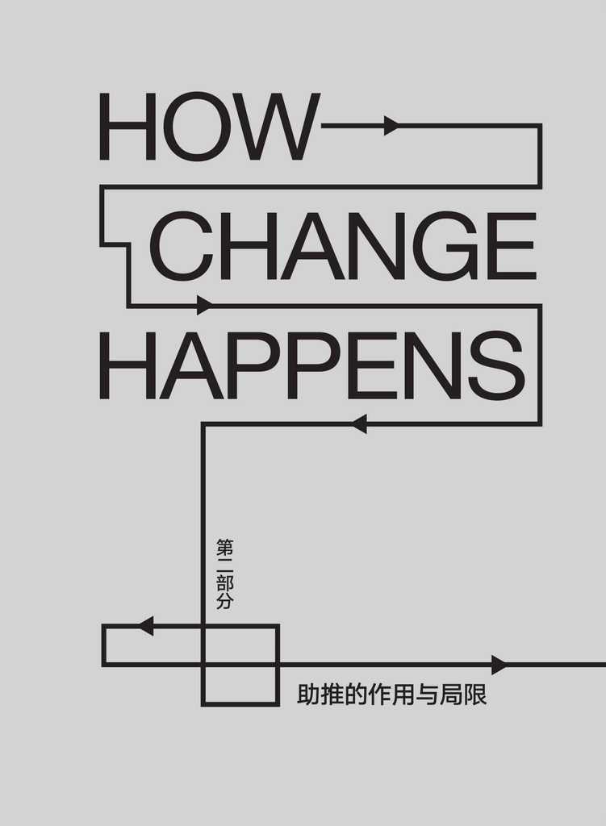

# 第4章 助推

有些政策的实施采取的是行政命令和禁令的形式。例如，刑法禁止盗窃和袭击他人。有些政策的实施采取的是经济激励（或抑制）的形式，如对可再生能源补贴、对某些活动收费、对汽油和烟草产品征税。还有一些政策的实施采取的是助推形式，即一些维护自由的方法：为人们指引特定的方向，但允许他们各行其是。近年来，私营及公共机构都对助推的使用表现出越来越强烈的兴趣，这是因为助推的成本通常很低，并且能够促进经济目标和其他目标（包括公共卫生领域）的达成。

在日常生活中，全球定位系统就是一个助推案例。这样的案例还包括：告知人们前一天摄入总热量的应用程序，通知消费者账单即将到期或第二天要与医生碰面的短信，闹钟，自动加入养老计划，电脑或手机的默认设置，信用卡账单及按揭自动还款系统。在政府方面，助推的应用包括：香烟的警告图示，能源效率标识或燃油经济性标签，食品上的“营养成分表”，“我的餐盘”计划（MyPlate）即为健康饮食而提供简单的指南，公共援助项目的默认规则（如获得免费校餐的贫困儿童的“直接认证”），向公众开放的大数据网站，以及政府网站上用大号字体标识的条目。

### 选择的自由

助推的目标在于使生活变得更简单、更安全或更易于应对，意识到这一点是非常重要的。路标、减速带、健康信息或金融信息的披露、教育措施、减少文书工作及公共警告都是如此。公职人员减少或消除文书要求，提高工作的简便性和透明度，这样就能减轻人们的负担；某些产品（如手机和平板电脑）使用起来更加直观且容易。因此，许多助推的目的在于确保人们在与政府互动的过程中，或者在实现目标的过程中不会感到麻烦或吃力。

诚然，一些助推可以被看作“温和家长主义”（soft paternalism）形式，因为它们可以引导人们朝着某个方向前进。即便如此，助推也是为了保护完全的选择自由而被特意设计出来的。全球定位系统会为人们指引特定的方向，但人们可以自由地选择路线。必须强调的是，影响人们选择的社会环境（或者说“选择架构”）永远都存在。助推与人类历史形影相随。新的助推通常会取代旧的助推，但不会在原本不存在助推的地方产生。

### 透明度与有效性

任何官方的助推都必须是透明公开而非隐秘的。透明度确实应被纳入基本实践。假设政府（或私营雇主）启动了一个让人们自动加入退休金项目的计划，或者假设有一个大型机构（如在政府办公楼内经营食堂的私营连锁商店或公司）决定让健康食品变得更醒目、更方便获取。在这两者情况下，相关行为无论如何都不应被隐藏。政府决策尤其应该接受公众的监督和审查。助推与行政命令和禁令相比的一个主要优势在于它避免了使用强迫。虽然如此，助推的实施也绝不该采取操纵或欺瞒的方式。与任何其他类型的政府行为相比，公众在助推方面的审查和监督权限不应更低。

在世界范围内，许多国家都对助推产生了强烈的兴趣。例如，英国设立了“行为洞察小组”（Behavioral Insights Tearn，有时也被称作“助推小组”）；美国设立了“白宫社会和行为科学小组”（White House Social and Behavioral Sciences Team），如今已更名为“评估办公室”（Offce of Evalvation）。各国对助推的兴趣与日俱增，这并非什么谜题。助推的成本通常较低（或为零），有时能即刻产生结果（包括大量的经济上的节约），它们能够维护自由，可以非常高效。在某些情况下，助推能比更昂贵、更具强制性的工具产生更大的影响力。例如，默认规则、简化，而且社会规范有时比重大经济激励措施的影响力更大。

对于退休计划而言，自动加入在促进效果和增加储蓄方面起到了极大的作用。在消费行为方面，披露要求和默认规则（明确人们如果什么都不做会产生什么结果）可以使人们避免遭受严重的经济损失，节省了数以百万计的金钱。简化金融援助形式与为每位学生增加援助金额一样，能在提高大学入学率方面产生同样有益的效果。在用电量显著上升时，告知人们其用电情况及与邻居的对比情况同样能够促进节约。如果设计得当，信息披露可以避免经济和人身损失。政府信息的公开，即数据和绩效的披露能够防止低效，甚至可以抵制腐败。

### 助推的实证检验

对于所有政策而言（包括助推），依靠实证而非直觉、轶闻、愿望或教条是极其重要的。最有效的助推往往会引入行为科学（包括行为经济学）的研究成果，因此能够反映出人们对政府相关举措的反应的现实理解。但有一些政策，包括一些助推，从理论上看希望很大，但在实践中却惨遭失败。因此，实证检验，包括随机对照实验都是不可或缺的。糟糕的意外肯定也会出现，如意想不到的不良后果；而明智的政策制定者必须尽量提前预测到这些意外，并在发生意外时进行弥补。实证检验表明，有时候计划周详的改革确实有效，但做出一些变动或采取一些替代方案将会产生更好的效果。

精心控制的实验是助推的首要目标。幸运的是，许多助推实验可以低成本快速进行，并且可以进行连续测量和改进。其中的缘由在于这类实验有时只需对已有项目做细微的改动，并且能以相对较低的成本或较少的精力在当前的举措中做改动。例如，公务部门想要鼓励人们缴清欠税，他们可以对当前的催缴信做各种各样的改动，从而检验改动之后是否能有更好的效果。

### 10类重要的助推

助推的范围非常广泛，其数量和种类也在不断增加。以下是10类重要的助推及其说明。对于政策的实施而言，这几类助推很可能是最重要的。

**1．默认规则**（如自动加入教育、健康、储蓄等方面的计划）

默认规则也许是最有效的助推。如果人们自动加入退休计划，他们的储蓄就会显著增加。自动加入医疗计划或健康改善计划都能产生显著效果。各种各样的默认规则，如双面打印，可以促进环境保护。请注意，若非涉及主动选择（这同样是一种助推），某些类型的默认规则基本上是不可避免的，因此反对使用这样的默认规则是错误的。诚然，让人们自主做出选择而不依赖于默认规则是有意义的。但在许多情境下，默认规则是必不可少的，因为要求人们做出选择既麻烦又费时间。

**2．简化**（部分是为了促进现有计划的实施）

无论是在富裕国家还是贫穷国家，复杂化都是一个严重的问题。首先，它会造成混淆，并且可能造成违法；其次，它会增加成本，从而可能会阻碍经济增长；最后，它会阻碍人们参与重要的项目。许多项目会因为复杂而失败或未达到充分的成功。一般来说，项目应该易于“通航”，甚至是直观的。在许多国家，形式和规则的简化是一个优先事项。简化的效果很容易被低估。在许多国家，重要项目（包括教育、健康、金融、贫困和就业项目）的益处由于复杂程度过高而被大大削减了。

**3．社会规范的使用**（强调大多数人的所作所为，如“大多数人打算参与投票”“大多数人按时交税”或“90%的酒店客人减少了毛巾的使用”）

最有效的一种助推就是告诉人们大多数人在做什么。如果这类信息尽可能地本地化和详尽，如“你所在社区的绝大多数人都按时交税”，那么它的效力就能最大化。社会规范的使用可以减少犯罪行为及有害行为（如酗酒、吸烟和歧视）。诚然，有时大多数人或许多人会做出不良行为。此时，强调大多数人认为人们应该如何行事而非实际上如何行事是有益的，如“在爱尔兰，90%的人认为应该按时交税”。

**4．增加易用性和便利性**（如让低成本的选择或健康食品显而易见）

人们通常会做简单的选择，因此精辟的口号是这样说的：大道至简。要想鼓励某种行为，减少各种障碍（包括减少理解该做什么所需的时间）是有益的。拒绝改变通常不是因为不同意或怀疑，而是因为感知到了困难或不够明确。同时，如果简单的选择还很有趣，那么人们更有可能做到。

**5．披露**（如披露与能源使用相关的经济成本或环境成本，某些信用卡的全部成本，大数据）

美国最高法院前大法官路易斯·布兰代斯（Louis Brandeis）曾经说过，“据说阳光是最好的防腐剂”，而披露可以让市场和政府更加“干净”。<sup>1</sup>对于消费者而言，如果披露的信息易于理解和获取，则披露政策将会非常有效。简化极为重要。感兴趣的人可以在网上获取更加详细和完整的披露信息。在某些情况下，披露可以用来检查私营或公共机构的粗心、疏忽、无能、不法行为和贪污情况。“开放政府合作伙伴”（Open Government Partnership）如今已覆盖数十个国家，这反映了世界范围内将开放作为促进实质性改革的工具所做出的努力；各国必须制定包含提高透明度新政策的国家行为规划。

**6．警示、图示或其他方式**（如香烟警告）

如果涉及严重风险，最好的助推可能是私下的或公开的警示。大号字、粗体字和鲜艳的颜色可以有效地引起人们的注意。关键在于，注意力是一种稀缺资源，而警示正是利用了这一事实。警示的优点之一在于它可以阻止人类本性中不切实际的乐观倾向，并即刻增加人们关注长远的可能性。然而，这也存在着一种风险，即人们可能会忽视警示（“我没事的”）；在这种情况下，利用积极信息进行实验也合乎情理。例如，为某些倡导行为给予奖励，哪怕奖励的不是金钱，就像某些应用程序会进行统计和发送祝贺。研究还表明，如果警示还附有可以降低相关风险的具体步骤，如“你可以通过某些行为来降低自身的风险”，那么人们忽视警示的可能性就会降低。

**7．激发执行意图**（“你打算投票吗？”）

如果有人激发了人们的执行意图，那么这些人更有可能参与某项活动。在健康方面，一个关于未来行为的简单问题，如“你是否打算让孩子接种疫苗？”就能产生明显的效果。强调人们的身份也很有用，如“过去的做法表明，你是一位选民。”

**8．预先承诺策略**（人们为某种行为做出承诺）

通常人们都会制订一些目标，如戒酒或戒烟、参加某项生产活动或存钱，但他们的行为又无法使这些目标达成。如果人们预先承诺采取某项行动，如参加戒烟计划，则更有可能根据目标来行事。值得注意的是，及时地为未来某个确切时刻的某种具体行为做出承诺能更好地激励行动并减轻拖延症。

**9．提醒**（如通过电子邮件或短信提醒逾期账单、即将到期的债务或约会）

人们脑海中的事情总是很多，他们没有采取某些行动（如支付账单、服药或赴约）的原因有可能是懒惰、拖延、抵触，以及忘记。提醒可以发挥重要的作用。对于提醒而言，时机非常重要；确保人们能够按照信息立即行动也很关键，尤其是在偶然忘记的情况下。有一种密切相关的办法是提示选择，人们不需要做选择，而是被询问是否愿意做选择。例如，是否愿意选择清洁能源或新能源供应商，是否愿意选择电脑的隐私设置，或者是否愿意成为器官捐献者。

**10．告知人们过去所做选择的本质与后果**（美国的智能披露）

私营和公共机构往往拥有关于人们过去所做选择的大量信息，如人们在医疗保健上的支出记录或电费账单。问题在于，个人通常缺少这些信息。如果人们能获取这些信息，他们的行为就可能会发生改变，能让市场更好地运行并节省大量资金。例如，如果人们知道去年的电费，那么他们就能采取措施，降低未来在这方面的支出。

### 实施助推的最佳方法

实施助推的最佳方法是什么？当然可以完全依靠现有机构。我们可以假设存在这样一个系统，现任的公职人员，包括领导和高层人员，都在运用他们对助推的理解。例如，相关研究可以由促进竞争力、环境保护、公共安全、消费者保护和经济增长的机构，或减少私营和公共腐败，以及消除贫困、传染病和肥胖的机构主持。身居高位的公职人员通常关注的是具体问题而不是抽象理论，他们可以利用这样的研究，至少可以偶尔利用一下。

如果相关公职人员既有知识又有实权，他们就不仅仅是研究团队或智囊团（即便是个人，如果被赋予了适当的权力和使命，也能产生很大的影响力），他们或许可以发起重大改革。有一种模型是这样的，相关公职人员不参与新研究，至少不会大量参与。他们会在已知的基础上构建模型，并且有可能与私营机构中处理同样问题的人建立正式或非正式的伙伴关系。重要的是，这个方法是最简单的。因为它不需要新的办公室或大量的额外资金，只需要关注相关问题和工具，以及恰当的任命即可。在美国，采用包含各种助推的此类方法已被证明是非常成功的。

还有一种完全不同的方法，那就是成立一个新的机构，如建立一个行为洞察小组、助推小组或其他类似的机构。此类机构的组织方式、形式及规模各有不同。在极简的模型中，会有一个由资深人士组成的小团队，他们让相关的发现开花结果，并且也可能参与或促进自身发起的研究。在更为宏大的模型中，团队的规模可以更大，他们会参与大范围的相关研究。行为洞察小组可以被设立为政府的正式部门（这是首选模型，以确保真正产生影响），或者仅担任咨询的角色。

无论具体情形如何，此方法的优势在于它拥有一个专职的、专业化的团队，他们消息灵通、拥有设计实验的专业技能，致力于相关的工作。如果团队可以与其他人合作开展研究，包括随机控制实验，或许可以产生重要的研究结果。而这也存在风险，因为这样的团队通常是学术兼职团队或局外人，没有能力激发或发起真正的改革。权力是极其重要的。英国在采用此类方法方面的经验最丰富，它的成功部分源于获得了高层的支持和授权。

在这个议题上，并不存在放之四海而皆准的标准模式，但值得关注的是，越来越多的国家认为拥有专职团队是值得的。当然，以上两种模式或许可以相辅相成。

# 第5章 助推与选择

有时你在大城市乘出租车去机场，司机很有可能会问你：“你想走哪条路？”不出意外的话，你可能不太喜欢这个问题，甚至有可能憎恶它。毕竟，如何到达机场是司机需要考虑的事情，并且大多数情况下他们都有全球定位设备。对于你而言，做选择就像一种心理上的赋税，这肯定是一种认知税（因为需要思考），并且还有可能是一种享乐税（因为思考如何到达机场并非乐事）。当然，这种税并不重，但它极有可能是不受欢迎的。

如果医生或律师向患者或客户抛出一连串的问题，他们的反应也许会是：“对于其中的部分问题，你为什么不能帮我做决定？”如果情绪强烈或者问题很棘手，这种享乐税和认知税就会很高。如果政府公职人员要求人们为参加培训或获得某项福利而填写复杂的表格，这种税就会产生抑制作用，至少对部分人来说会产生这种效果，甚至会导致人们放弃申请。因此，复杂的表格填写要求不仅仅是一种文书负担，还会危害甚至完全阻碍潜在的项目。

对此，我们需要思考3个问题：

1．一家线上服装公司正在进行决策：一是采用具有隐私默认设置的系统；二是要求初次使用的用户明确隐私设置，然后才能访问网站。

2．一家大型用人单位正在以下选择中徘徊：第一，让员工自动加入医保计划；第二，在征求员工同意的情况下让他们加入医保计划；第三，告知员工必须在入职前明确是否愿意加入医保，如果愿意则选择其中的一类。

3．一家公共事业公司正在决策：为消费者选择采用“绿色默认设置”，成本稍高，但使用的是环保能源；或者采用“灰色默认设置”，成本稍低，但不如之前的选项环保；又或者，询问消费者愿意采用哪种能源。

在以上案例及其他无数案例中，公共机构、私营机构或个人都在对是使用某种默认规则，还是要求人们做出主动的选择进行决策。对于拒绝家长主义、珍视自由选择的人来说，主动选择具有明显的吸引力。的确，主动选择似乎比任何一种默认规则都要好得多，因为它尊重个人的自主性，有利于推广责任理念，可呼吁行使个人自由。它似乎反映了对人类尊严的维护。

鉴于以上因素，人们很容易认为主动选择应该占据首要位置，特别是当它还能够提升或“增强”人们的能力，为其提供信息，或提升其统计素养时。人类的大脑分为两个系统，系统1：直觉思维系统；系统2：理性思维系统。<sup>1</sup>理性思维系统会告诉你，航空旅行是非常安全的，哪怕直觉思维系统认为飞机不能长距离飞行。或许最佳的办法是强化理性思维系统并坚持主动选择。

近年来，人们针对自由选择、家长主义、行为经济学、个体自主性、默认规则的使用及选择架构进行了激烈的争论。通过援引最新的行为研究成果，有人提出，由于人们会以可预见的方式犯错并为自身带来严重后果，某些家长主义近来变得合理起来，尤其是当它保全了选择的自由时，正如在“助推”或“自由家长主义”理念中所体现的那样。另外一部分人则认为，正是由于这些错误，才需要采取某些形式的强制措施来增进人们的福祉。他们相信，最终关于拒绝选择或非自由式家长主义的观点会不断增强。<sup>2</sup>

在此，我的核心目标在于动摇那些反对意见并指出它通常是一种错觉。其核心原因在于人们往往选择不做选择，而强迫他们选择则是一种赋税。在许多情形中，坚持主动选择或强迫人们选择其实就是一种家长主义，而非反面。在可以想象的假设下，任何要求他人做出选择的做法都符合家长主义的标准定义，并且与家长主义最常见的反对做法相矛盾。很多人相信，在许多情境下，做选择既劳神又费钱。有时他们选择不做明确的选择，有时他们宁可向那些愿意代替他们做选择的人支付可观的费用。他们主动选择了不做选择。

有时人们没有做出明确的选择，他们没有主动选择任何东西。但我们有理由推断，在某些特定的情形中，他们偏向于不做选择，并且在被问到时也会如此回答。回想一下乘出租车去机场，或者与医生和律师互动的案例。他们这样做的原因很多。他们或许担心自己会犯错误。或因为太忙而导致“带宽”不够用，因而认知资源受限，不愿意缴（认知）税。<sup>3</sup>他们也可能是希望将注意力集中在某些特定问题而非其他问题上，或者认为选择会消除这种自由。更或者他们意识到了自己的信息量不足和自身存在的行为偏差（如不现实的乐观主义）。他们可能发现无论是从经验、道德还是其他方面来说，潜在的问题令人困惑、畏难、痛苦和烦恼。他们也许并不喜欢做选择，甚至是不想为有可能发生在自己身上的不利后果承担责任（至少对于他人而言是间接的）。<sup>4</sup>也许他们预料到了自己将会后悔从而试图避免。

但即便人们情愿不做选择，许多私营和公共机构基于主动选择对人们有利的立场，依然赞成和促进主动选择。他们有足够的理由坚持这一信念。有时，作为克服集体行动困境的一种方法，主动选择是必需的（人们不能将投票权委托给他人），但有时它也是一种保护那些选择不做选择以避免自己犯错的人的手段。其中心思想在于，哪怕人们不愿意做选择，他们也应该进行选择。机构或许认为选择能够锻炼人类的某些肌肉，或许认为选择有助于人们学习。如果机构对于要做出选择的偏好凌驾于选择者（那些不愿意做选择的人）之上，那么主动选择就成了家长主义。因为它凌驾于人们本身对于什么是好的，或什么最能增进自身福祉或自由的判断之上了。

可以肯定的是，保姆式的美国州政府会禁止选择，但同时他们也禁止不做选择的选择权。促进选择或要求选择或许是比较受欢迎的，但这些其实都是自相矛盾的，因为它们都是家长主义。

如果人们在不想做选择的时候被要求做出选择，主动选择就成了非自由家长主义的一种形式，因为人们本身的选择被否定了。我们应该看到，在很多案例中，许多赞成主动选择的人都是在强制要求，从家长主义的立场来说这或许会践踏人们不做选择的权利。如果人们宁愿不做选择，要求其选择就是一种强迫——虽然它或许披着一层合理的外衣，至少在不做选择不会被征收高额赋税，不会增加犯错的可能性和严重性，对于促进人们学习和发展自身偏好有着重要意义的时候是这样。

相反，如果询问人们是否愿意做出选择，并且可以选择退出主动选择（如赞成默认规则），那么主动选择就成了一种自由家长主义。在某些情况下，这具有特别的吸引力。公司或许会询问人们愿意自己选择电脑的隐私设置还是使用默认设置，愿意自己选择电力供应商还是使用默认供应商。

在这种方式中，人们就可以在默认设置和自身偏好之间做出主动选择。从这个角度来说，他们的自由得到了完全的保障。我们可以称之为简化版的主动选择。简化版的主动选择有一些优势，它既可以避免来自默认规则的压力，又允许人们在愿意的情况下使用默认规则。在未来，我们应该看到，并且我们应该希望看到，许多机构，无论是公共还是私营机构，都会采用这种方式。

然而，这种方式并非万灵丹。它本身就是一种赋税，哪怕是一种很低的赋税。我们有必要承认，无论何时，公共或私营机构让人们进行选择都有可能是在践踏他们不做选择的权利，从而变成要求进行选择的家长主义。即便是在人们被问到是否要做选择时，也是如此。出租车司机哪怕只是询问：“你能告诉我怎么走，还是愿意让我选择路线呢？”乘客也必须集中注意力。毕竟，他们或许不希望做二阶选择，因此情愿选择默认规则。如果这么说还不够清楚，请想想那些征求答案的问题，其实就是在对人们稀缺的认知资源进行征税。

就此而言，要求人们在主动选择和默认规则之间进行选择这种看似明显的保全自由的方法其实是典型的非自由主义。如果这种说法并非不言而喻且听起来有点刺耳，那是因为主动选择的理念对于人们来说是如此熟悉和具有明显的吸引力，因而让人看不清它的真实面目：它是一种许多选择者并不喜欢的选择架构，至少在不熟悉或困难的情境中如此。

### 主动选择的意义

许多赞成主动选择的人认为，商品和服务的消费者，以及各种选择的决策者不应受到政府的影响。当然，他们承认，生产者会在市场中施加各种各样的影响，但是他们主张如果不涉及第三方、武力和欺诈，政府就应该保持中立。他们拒绝政府的家长主义。

公职人员要求商家提供准确的信息以确保消费者充分了解自己的选择，这或许是合法的，进行提示也是合理的。但有人认为，如果政府试图通过默认规则或任何形式的家长主义等其他方式助推人们往政府所偏好的方向走，那么它就会失了分寸。尤其是这些人偏好主动选择，并且希望鼓励这种选择时。即便他们重点关注的对象是公共机构，但对私营机构也会持有同样的意见。

然而，主动选择意味着什么呢？“要求”人们明确自身的偏好又意味着什么？这个问题并不像表面上看起来的那么简单。如果说这个问题没有明确的答案，那些坚持认为默认规则必不可少的人是不会同意的。即便选择架构师试图推广主动选择，他们也必须指明如果人们拒绝选择的后果是什么。难道答案不就是（拒绝之后要选）默认规则吗？

这个问题很好，因为一些默认规则最终是必不可少的。选择架构师必须指出如果人们拒绝选择的后果，而这是助推的批评者们时常忽略的一点。选择架构本身是不可避免的。但是这不应该成为摧毁主动选择与默认规则之间的差异的工具。为了说明缘由，我们可以考虑以下3种可能性。

**1．对那些拒绝主动选择的人进行刑事或民事处罚。**

在大多数情况下，没有人会同意这种观点：如果有人拒绝选择，那么他们应该被处死、监禁、罚款或受到其他处罚。对于不做选择的一般处罚是他们无法得到某种商品或服务。但也有例外。在某些国家，如澳大利亚、比利时及1970年之前的荷兰，如果有人不投票，那么他们就会受到民事处罚；从这个角度来说，他们因为拒绝主动选择而受到了惩罚。同样，美国《平价医疗法案》（Affordable Care Act）的一项规定（如今已被废止）曾要求人们加入医疗保险，否则将会以税务罚款的形式进行处罚。如果人们被要求加入医疗保险，一般来说，他们也会被要求选择特定的医保方案。

关于主动选择，这些案例都采取了同一种做法：人们被迫按照同一维度进行选择（给谁投票及选择哪种医保计划），但被禁止按照其他维度进行选择（是否投票或是否加入医保）。但是，只要有一种选择是必须的，我们就有理由认为这是强迫选择。在上述两个案例中，强迫选择可以作为克服集体行动困境的手段，因而被合理化了，其理由是：除非大多数或所有成年人都进行投票，否则民主系统将有可能受到损害；医保系统需要广泛的参与。

单纯从家长主义的立场来说，我们很容易就能找到为两种强迫选择进行辩护的理由。例如，为了保护人们免遭灾难损失，他们应该被要求加入医保；为了确保他们选择正确的医保计划，人们应该被要求选择他们应该选择的计划。当然，第二种家长主义反映出了对于个人能动性的尊重，而第一种却没有。但根据合理的假设，这两种形式都有道理，并且它们之间并不矛盾。

我们还可以想象其他的如果人们不做选择就会受到处罚的情形，虽然我们也承认，其中的部分案例看起来更像科幻小说而非真实故事。而现实中，我们可以想一想这些案例，如人们必须选择是否捐献器官，否则将面临刑事处罚；或者必须为电脑选择隐私设置，否则将要接受民事制裁。人们很少会因为不做选择而受到处罚，这个事实似乎说明了一个默认的共识，即在自由社会中，这样的选择通常是可以接受的，并且这其实是消费者主权的合法组成部分。其中一个原因与知情权有关：人们最清楚自己想要什么，其他人不应该替他们做选择，即便这个选择是不做选择。我坚持认为，那些声称尊重个人选择权的人并没有充分强调这一点。

**2．对相关或辅助事项进行主动选择，以此作为获得某种商品或服务（或工作机会）的条件。**

有时，主动选择是强制性的：如果人们不对一些问题做出主动选择，那么就无法获得某种商品或服务，哪怕这种商品或服务从狭义上来说与他们被要求进行选择的主题无关。我们可以想象，在需要解决的问题（要求进行主动选择）与需要选择的特定商品之间存在着一个连续体。它们之间可能存在紧密的联系，如人们被告知，除非他们指明自己想要哪种汽车保险，否则将无法租车。再如人们被告知，除非他们设置一个密码或表明自己在隐私设置方面的偏好，否则将无法使用电脑。实际上，这两种情况都是很典型的。在市场中，卖方有时会要求买方必须针对某些相关问题做出主动选择，这样才能获得或使用某种产品。

相反，如果人们被告知只有明确自己的退休计划才能在某些单位就职，那么两者之间的联系就会变得较弱。如果人们被告知，必须表明自己在器官捐献问题上的偏好，否则将无法获得驾照，那么这种联系就会更弱。如果人们被告知必须选择自己电脑的隐私设置偏好，否则将无法登记投票，那么这种联系将会进一步减弱。

在最后一个例子中，人们被要求做出选择的问题与他们刻意寻求的事物之间没有任何联系。在某些案例中，选择架构师要求的是对真正具有辅助功能的问题做出主动选择。请注意，在我们可以想象到的此类案例中，对于主动选择的要求具有强烈的强制性维度，因为需要选择的好处是人们无法轻易拒绝的（如驾照、工作机会或投票权）。实际上，选择架构师正是利用这种益处来确保人们在其他问题上做出主动选择。

从规范的角度来说，我们或许需要区分一下公共机构和私营机构。也许，私营机构由于受到市场力量的约束，需要与其他机构在此方面进行自由竞争，而公共机构应该在要求人们做出选择之前多思考一下，除非需要选择的商品或服务与主动选择的目标之间存在密切的联系。

**3．对商品、服务或工作机会做出主动选择，以此作为获得商品、服务或工作机会的条件。**

对于大多数消费决策而言，人们拥有许多选项，可以选择其中的一个或多个。如果不做选择，他们就无法获得相关的商品或服务。他们不会默认购买苏打水、平板电脑、手机、鞋子或钓鱼竿。事实上，这就是自由市场的标准模式。在人们逛网站、餐馆、杂货店或电器商店时，他们通常会被要求做出主动选择。可以将默认选项理解为如果人们什么都不做就会发生的结果，在这里就是什么都不购买。除非做出主动选择，否则他们不会得到任何商品或服务。在就业市场亦是如此。通常人们不会对某些工作设置默认选择，至少从正式意义上来说不会。他们拥有一系列选项，如果不选择其中一个，那么他们就不会被雇用。因此，自由市场通常要求人们做出主动选择。

在这种情形中，没有什么是无法避免的。我们可以想象一个场景，其中卖方假设或推测人们想要某些产品，并且买方必须被动地付费。假设销售员拥有充足的信息，知道约翰逊想要购买哈兰·科本（Harlan Coben）、理查德·塞勒（Richard Thaler）或乔伊斯·卡罗尔·奥茨（Joyce Carol Oates）的一本新书，或者史密斯想要购买某款平板电脑的新版本，拉莫特想要购买某款运动鞋，乌尔曼想为宠物狗购买某种产品，威廉姆斯在牙签用完后想要购买同款产品。再假设卖方的判断从不出错，或者说几乎不出错，那么安排默认购物究竟是令人反感的或具有干扰性的，还是具有很大的益处？科技的发展开始越来越多地涉及这个问题。

有一种很不错的说法认为，要求主动选择的最有力的理由在于，足够可靠的可预见性的购物算法并不（尚未）存在，而主动选择是对抗错误购买的无可取代的保障。算法的使用并不（尚未）符合那些可能被（默认）指定的购买者的利益。从这个角度来说，关于主动选择的观点根植于这样一个信念：明确同意能够防止犯错——如果有可靠的技术，就可以进行“被动购买”。我们已经在接近这种可能性，在某些方面或许已经实现了这种可能性，但只要这种技术还不存在，被动购买就无法被人接受。有这样一种假设：一旦可靠的算法真正出现，我们将在诸如上一段购物之类的案例中看到更多的支持。

### 选择者的选择

如上节所示，私营和公共机构或许都会选择第2种可能或第3种可能，当然只有政府能够选择第1种可能。我们应该清楚，主动选择并非无法避免。机构可以选择某种默认规则，指明如果不做选择的后果是什么，而不是强行让人们主动选择。当然，第2种可能和第3种可能都伴随着一种默认规则：除非人们做出主动选择，否则他们将无法获得商品、服务和工作。但其他方式可能也是可行的。

举个例子来说，那些获得驾照的人可以自动成为器官捐献者，或者开始在某个公司工作就会被默认加入某个退休计划或医保计划。这些案例并非只是虚构的。或者，那些做出主动选择以便购买某种产品的人或许可以参加定期收到相似产品的项目，无论他们是否做出主动选择。每月一书俱乐部采用的正是这类策略。

主动选择购买产品可能还会产生与该产品无关的默认规则。例如，购买某本书产生了加入医保计划的默认设置，或者加入医保计划的主动选择产生了加入读书俱乐部的默认设置。在极端案例中，如果披露不够充分，这种方式就有可能是一种欺诈。我们可以想象在某些情况中，这种方式可以追踪人们的偏好。

例如，假设有一家私营机构得知购买甲产品（如某类音乐）的人也有可能喜欢乙产品（如某类书）。各种建议、默认的广告、默认的政治见解，甚至默认购买都有可能是受欢迎的，并且符合人们的利益，尽管这种联系或许看起来并不常见。例如，美国的一个音乐网站会追踪人们的音乐偏好，并且可以从中推断出用户可能的品位和对其他事物（包括政治）的见解。<sup>5</sup>

我们还可以想象人们被明确要求选择是否要做选择的情况。消费者会被问道：你是否愿意选择手机设置，还是选择最适合大多数人或最适合你这一类人的默认设置？你是否愿意选择自己的医保计划，还是选择最适合你这一人口类别的默认计划？在这些情况中，许多人或许会决定选择默认规则，从而拒绝选择，因为二阶愿望是不愿意做选择。他们或许不信任自己的判断，或许不愿意学习。这类问题或许会让他们感到焦虑。他们或许还有其他更愿意做的事情要做。

简化版的主动选择，即包含默认规则选项的主动选择，具有很好的前景和吸引力，这不仅仅是因为它避免了默认规则包含的许多影响，还因为它在高度尊重自主权的同时也让人们能够选择默认规则。对于手机设置或医保计划而言，主动选择者可以在愿意的情况下做出主动选择，而其他人则可以（主动地）选择默认规则。

然而，这类问题同样也是一种侵犯和赋税。因此，至少对于那些真的不愿意做选择的人而言，这并不是一种完美的解决方案。毕竟，他们是被要求进行选择的。至少有部分人不愿意必须在主动选择和默认设置之间做出选择，因此在两者之间，他们更喜欢默认规则。即便是主动选择也许需要花费时间，并且会增加成本，因而有些人或者许多人也不愿意花费这些精力。从这方面来说，想象中的自由家长主义，即在主动选择和默认设置之间进行主动选择，本身就具有一种强烈的非自由主义维度。这个结论会直接将我们引入下一个话题。

### 促使选择的家长主义

现在转向本人论点的核心部分，它很简单：那些赞成主动选择的人，以及那些强迫他人做选择的人通常会表现出家长主义的行为，至少在他们要求人们选择而人们不愿意做选择的情况下是这样。由于这样的情况无处不在，所以从相应的意义上来说，那些要求他人做选择的人的作风就是家长主义。与在其他情况中一样，家长主义或许有其必要性，促使选择的家长主义或许能带来自主权和福利，但它或许会遇到家长主义在其他情况中所遇到的同样的反对意见。然而，我们将会看到，促使选择的家长主义还有一个独特的好处。

#### 家长主义

在人们不愿意选择的时候，要求他们主动选择是不是一种家长主义的做派？要想回答这个问题，我们应该首先对家长主义进行定义。这方面的文献很多。<sup>6</sup>我们暂且把最难的问题放在一边，需要注意的是尽管人们已经给出了不同的定义，但很明显，家长主义做派的统一主题是私营或公共机构不相信人们的选择能增进他们自身的福祉，并且正在采取措施来影响或改变人们为了自身利益所做出的选择。

拥有这种定义的家长主义又有什么不对的地方呢？那些拒绝家长主义的人通常会提到福利和自主权的问题。他们倾向于相信个人能对符合自身利益、增进自身福祉的事物做出最佳判断，而外人不应干涉，因为他们缺乏关键的信息。<sup>7</sup>在谈到福祉问题时，哲学家和经济学家约翰·斯图尔特·穆勒（John Stuart Mill）强调这是包括政府公职人员在内的局外人的主要问题。穆勒坚持认为，个人“是对自身福祉最感兴趣的人”，而且“普通男性或女性拥有无与伦比的获取知识的手段，其他任何人都望尘莫及”。<sup>8</sup>社会试图推翻个人的判断，它是基于“一般性推论”做出的，这些推论“或许全都是错的，即使是对的，也有可能被错误地运用到了个人情况中”。穆勒的目标在于确保人们的生活如意，并且他主张，对于政府而言，最好的解决方案就是允许人们去寻找自己的道路。

穆勒提出了一个关于福祉的论点，其基础是认为个人更具信息优势。但是还有一种关于自主权的独立观点，这种观点强调，即便人们并不知道什么对自己是最好的，并且人们会做出糟糕的选择，但他们也有权利按照自己认为合适的方式行事，至少只要不伤害他人或者不涉及集体行动困境就可以。选择的自由具有内在价值，而不仅仅是工具性的价值。家长主义是对个人尊严的一种侵犯，是婴儿化的一种形式，是在试图消除人们独立自主的能力。

#### 强迫人们进行选择的家长主义者

无论这些关于家长主义的异议是否完全令人信服，它们在许多情况下都具有相当强大的力量。是否及如何将这些异议适用于推翻人们不做选择的选择行为，似乎涉及合理性的问题。或许那些希望人们进行选择的人的行为一点都不像家长主义，或许他们是在试图促进自我决策并且对人们表现出了高度的尊重。

这可能是他们认为自己正在做的事情。回想一下出租车司机的案例，他们正是这么做的，而且还惹起了乘客的怒气（“为什么你选择那条糟糕的路线？”）。让患者和客户做出选择的医生和律师与此类似。如果公职人员促使或要求人们做出选择，他们或许认为其目标是避免出现此类家长主义。他们关注穆勒的担忧或类似的问题，坚持认为对个人自主性的尊重需要一则四字声明：你来选择。这跟家长主义有何相干呢？

然而，经过反思，对家长主义的反对意见非常有效，因此促使选择的家长主义和要求选择的家长主义本身并不矛盾。如果一位局外人告诉人们必须做出选择，那么局外人就是在拒绝人们关于自己应该做什么的构想，从而危及他们的利益（在穆勒论点的前提下）并拒绝尊重他们的自主权。人们可能出于多种原因而拒绝做出选择。在他们看来，选择不做选择是因为这能最大限度地提升自身的利益，并且他们希望这种选择能够得到尊重。他们可能有一个直观的框架：希望能够最大化地降低选择成本和犯错成本。如果选择会带来很高的成本（从某种意义上来说相当于认知税或享乐税），他们或许不愿意这么做，除非这些成本能够很好地降低犯错成本。如果他们认为有人（出租车司机、雇员、公职人员）更有可能做出正确的选择，就会觉得降低犯错成本的最佳途径就是不做选择。他们可能会委托其他人作为自己的代理人；他们可能会将自己视为委托人，并以自信、满足或愉悦的态度委托代理人进行选择。

更具体地说，他们可能认为，在当前背景下，自己缺乏相关信息或专业知识，担心自己会犯错；也许只是不喜欢做选择这种行为而更乐意让别人替自己做决定；或许太忙了，也或许是不希望产生选择带来的情绪成本，尤其是在需要痛苦地或艰难地思考的情况下（如器官捐献或临终关怀）。他们或许会发现委托是一种解脱，甚至乐趣；他们或许不希望承担责任；他们或许不想因后悔做了决定而付出精神成本。这样的原因还有很多。主动选择会使选择者背负选择的责任，并因此使选择者的利益减少。

在日常生活中，在数不清的事情上，人们会顺从他人，其中包括朋友和家庭成员，并且这通常能取得更好的结果。在普通的关系中，人们会从默认规则的功能等效中受益，有些是明确表达的，有些则不是。例如，在婚姻中，某些决定（如管理财务或规划假期）默认是由丈夫或妻子去做，他们有权在特定的情况下选择退出。在许多情况下，这种做法与人们在面对私营或公共机构时选择不做选择有着相似之处。他们可能希望租车公司、医疗服务人员或雇主能代替自己做一些选择。事实上，人们通常愿意支付高额的费用来让别人做这些决定。但即使不涉及明确的支付或代理权的授予，人们可能也会宁愿被免除选择的义务，因为这种免除会降低决策成本或犯错成本，或两者兼有。

举个例子来说，假设琼斯认为他不可能为自己的退休计划做出很好的选择，又不想通过学习获得这种能力，因此他偏向于（选择）由相关专家选择的默认规则。用穆勒的话来说，难道琼斯不是最了解自身情况的吗？穆勒坚称：“普通男性或女性拥有无与伦比的获取知识的手段，其他任何人都望尘莫及。”<sup>9</sup>

或者，假设史密斯特别忙，希望将精力集中在最重要的事情上，而非正确的医保计划或计算机隐私设置。难道穆勒的观点不支持尊重史密斯的选择吗？无论选择者选择了什么，福利主义者的观点似乎都要求尊重选择者的选择，即便这种选择是不做选择。如果我们对于自由选择的信仰是建立在只有人们自己知道什么最适合自己的基础之上，那么当人们自由地选择不做选择时，这种观点也应该支持并尊重他们的决定。

或者可以从福利转向自治和尊严方面的来考虑。假设温斯顿行使自主权，决定将决策权下放给其他人，从而放弃选择权，如在涉及医保、能源供应商、隐私设置或信用卡计划等情况中。如果私营或公共机构拒绝尊重这种选择，这是对温斯顿尊严的侵犯，还是维护？至少我们有理由认为，如果尊重自主权，那么需要尊重人们是否及何时做选择的决定。鉴于人们要做无数决定，这种观点显得特别合理，他们可能会通过关注对自身来说最重要的事情而不是看似微不足道的、无聊的或者困难的事情来决定是否愿意行使自主权。

#### 选择的自由

诚然，我们可以想象在艰难的情况下，选择不做选择似乎是对自由的放弃。在最极端的案例中，人们可能会选择以某种基本方式放弃自由，就像“9·11”事件之后那样。在次极端的案例中，人们可能会选择不投票，这并不是说不出现在投票站，而是（正式地）将他们的投票权委托给他人。此类委托是不被允许的，原因之一是这也许会破坏投票制度的内在逻辑（部分原因在于这种行为会产生禁止兜售投票权原本已经化解的集体行动困境），但也可能是因为个人放弃了自己的自由。

或者，人们可能会因为尊重宗教信仰或未来的配偶而选择不做选择，也可能会将这些选择委托给其他人。在涉及人们生活的核心问题的案例中，我们可以得出这样的结论：选择的自由不能被放弃，人们必须自己做出决定。

我们无法轻易指出哪类情况属于此类别。人们可以就这个问题进行很好的辩论。但即使该类别范围很广，这也不该成为对“出于对自主权的考虑，人们应该被允许在一些领域不做选择”这一主张的普遍反对。

#### 非对称

促使选择的家长主义并不是一种自我矛盾的说辞，但它可能具有独特的吸引力，并且在某些方面与家长主义的形式完全不同：不促使选择，积极劝阻选择，禁止选择。第一类的案例很常见，如默认规则的案例；第二类则包括用来劝说人们委托权力而非亲自选择的警告或提示。第二类的案例确实少见，但我们绝对可以想象出在金融或医疗抉择方面的案例；第三类的案例也很常见，是那些反对家长主义的人最常用的靶子。

那些赞成促使选择的家长主义的人可能会承认上面一段话的合理性，但也会抗辩说我们实际上讨论的是辩论者的观点，甚至是一种双关语。他们可能会指出其动机明显具有吸引力，并且只要促使选择，对家长主义的关注就会被削弱甚至消除。我曾指出这些关注非常重要。但那些赞成主动选择的人可能会说，他们实际上并没有表现出不尊重选民或以任何方式侮辱他们，相反一直都在尊重他们。

这些人也可能会补充说，他们真正关心的是选民的福利。当然，还需要警惕选择架构师犯错的风险，他们可能会对个人情况的重要性一无所知、有偏见或忽视，并可能声称自己是穆勒最忠实的追随者。即使承认有些人会选择不做选择，他们也可能会提出这种说法。可以肯定的是，将机场路线委托给出租车司机做选择的决定可能并非是错误的，但涉及自己的医疗保健或财务状况的决定呢？

其中有些观点是合理的。没有人怀疑那些不想选择的人可能会反对那些试图影响或推翻他人欲望的局外人或中间人。但确实，促使选择的人拥有独特的动机，这与尊重选择者有关。这就引出了正当性的问题。

### 家长主义是正当的吗

#### 福利

即使选择者自由选择不做选择，这种选择也可能会不符合选择者的利益（选择者会对利益做出定义）：承认这一点很重要。因此，促使选择甚至要求选择的家长主义可能也有福利主义的理由作支撑。或许，选择者选择不做选择仅仅是因为自己缺乏重要的相关信息，这表明默认规则可能是有害的或者选择架构师是无知的或不值得信任的。也或许他在承受着某种形式的有限理性。行为市场失灵通常被理解为由人为失误引起的非标准性市场失灵，它可能会影响不做选择的决定，就像它可能会影响做选择的决定一样。

例如，一位非选择者或许会因为在最近的选择中犯了错并对此产生了过度反应而受到可用性偏差的不良影响。又或许选择者是短视的，并且受到短期选择成本的过度影响，进而低估了可能非常大的长期利益。现状偏差可能会对不做选择的决定产生影响。人们可能会面临人际关系中的集体行动困境，在这种情况下，前期所做的选择会在后期损害其福利。

但对于那些基于福利主义立场而拒绝家长主义的人来说，这些顾虑通常是提供更多和更好的信息的理由——这不是为了阻止人们做出选择，包括不做选择的选择。或许选择者应该受到助推而进行选择。促使选择的家长主义，作为自由家长主义的一种形式，可能会比要求选择的家长主义更受欢迎。

从福利的角度来看，支持促使选择或支持要求选择的观点在广义上与促使或要求任何其他行为的观点是一样的。当然，福利主义者反对家长主义或许是错误的。我们能够轻易地想象，基于福利的理由，家长主义是十分正当的。我们尊重他们反对的权利，但问题在于选择不做选择在一般情况下还是在特定情况下可能会出错？理论上我们没有理由认为某种特定选择会特别容易出错。鉴于人们容易过度自信，不做选择的选择甚至可能是正确的，这会给要求选择的家长主义带来严重的问题。对个人犯错的顾虑似乎最多可以用来支持促使选择的家长主义，而非更加咄咄逼人的家长主义。

考虑一下这方面的证据：人们花费太多时间试图做出正确的选择，正是这样才导致了重大的福利损失。在许多情况下，人们低估了选择和扩大利益的时间成本，造成“在预测拥有更多选择自由（相对于更少选择自由）在任务绩效和任务方面产生的情感影响时出现系统性错误”。<sup>12</sup>如果出现了这样的系统性错误，那么我们有理由认为，人们可能会基于福利缘由，在不应该做选择的时候进行选择。如果选择具有内在价值，那么人们会选择在自己能做得更好的情况下进行某种形式的授权，至少在物质方面会如此。

我的目标不是为福利主义者在面对家长主义时所持有的拒绝立场背书；我只是想指出这些基本论点适用于所有形式的家长主义，包括那些会干扰不做选择的决定的家长主义。可以肯定的是，一些福利主义者宁愿干扰别人的选择；他们很可能是自由家长主义者，也可能是非自由家长主义者。最简单的一点是，代表选择自由的典型福利主义者的论点适用于那些（自由地）选择不做选择的人，并且那些想要干涉这种选择的人很可能是家长主义者。以福利为理由的家长主义是否正当取决于具体情况。

#### 自主权

我们已经看到，从自主权的角度来说，对不做选择的决定进行干预肯定是令人反感的。当出租车司机要求乘客做出选择，他们或许正在侵犯乘客的自主权；当乘客说“你决定吧”时，他是在行使自己的自主权。允许选择者将自己的注意力放在他们愿意注意的地方，这是一种尊重，也是对于其尊严的认可。

正如我们之前看到的那样，最明显的例外是那些将选择视为对自由的背离的情况。或许也还存在其他例外情况。这就引出了一个问题：促使选择或要求选择的家长主义是否通常会因为自主权的缘故而具有正当性？雇主或许认为员工应该自己选择医保计划，这样他们的能动性能够得到锻炼和提升。这不仅涉及医保计划，还涉及需要统计素养的一系列广泛选择。对于医疗事务而言，最好能通过提供简单的信息或教授人们相关统计知识来提升其能力，并秉持这样的信念：在这一方面所做的努力将会提升人们在多个领域的自主性。在退休计划的案例中，类似的考量也会支持主动选择。这样的例子不胜枚举。

以上种种表明，如果目标是为了尊重或提升自主性，我们应该拥抱还是拒绝促使选择的家长主义并没有定论。从一方面来说，人们在决定何时及是否要做选择的时候就是在行使自主权。事实上，这是行使自主权的基本途径。这也是拒绝保留选择的家长主义的一个重要原因。从另一方面来说，做选择就像身体的肌肉，可以在使用中不断得到强化。对于选择架构师而言，最普遍的建议是，出于自主性的理由，人们应当能够根据具体的情况决定做选择或不做选择。但在某些情形中，提升自主性本身可以用以证明影响或推翻不做选择的决定的正当性。这种观点的可靠性取决于在特定情况下因自主性而促使选择所具有的价值。

# 第6章 助推与福利

某些助推措施旨在减少经济外部性：试想一下让人们关注环境的燃油经济性标签，或者让人们自动使用绿色能源的默认规则。但是，许多助推措施旨在提升人们通过选择为自身带来更多福利的可能性。助推的核心目标在于“自主判断，提升选择者的利益”。<sup>1</sup>社会规划师或选择架构师对于什么能让选择者更加受益有着自己的理念，但在我们看来，其指导原则在于让人们自己做判断。更确切地说，其指导原则就是福利，而人们自身的判断是检验助推是否能提升他们的福利的一个良好（即使不完美）途径。

最后一句话会引发很多质疑，并且对“自主判断”（As Judged By Themselves）标准中潜在的歧义感到疑惑肯定是合情合理的。重点自主判断是选择者在助推之前还是助推之后做出的？如果助推改变了人们的偏好，使他们喜欢助推所产生的结果，但他们之前并未想过会有这样的结果，该怎么办？如果偏好是由相关的选择架构师所构建的，该怎么办？如果人们的事前判断是错误的，也就是说助推能够提升人们的福利，哪怕他们不这么认为，该怎么办？我们是否想询问选择者实际的、可能是无知的或存在行为偏差的判断？如果选择者拥有所有相关信息并且不受相关偏差的影响，那么我们是否有权询问他们是怎么想的？

在此，我的目标是探索自主判断标准的含义，并厘清一些歧义。正如我们将看到的那样，应区分以下3种情况：第一，选择者具有清晰的先验偏好，而助推能帮助他们满足这些偏好；第二，选择者面临着自我控制方面的问题，而助推可以帮助他们解决这个问题；第三，选择者将对两次或多次助推所产生的结果感到满意，或者事后偏好是内生的或由助推构建的，以至于自主判断标准为选择架构师留下了几个选项，但没有指明具体选择哪一个。符合第一种类型的情况明显能够满足自主判断标准，并且这样的情况很多。从自主判断标准的角度来看，符合第二种类型的情况也是没有异议的，事实上它们可以被认为是第一种类型的子类，并且数量众多。符合第三种类型的情况会带来特别的挑战，这会导致我们直接询问人们的福利，或探究知情的、主动的选择者通常会做出怎样的选择。

在一组启发性的评论和对助推的批评中，经济学家罗伯特·萨格登（Robert Sugden）提出了一个简单的问题：“人们是否真的愿意被助推着朝更健康的生活方式前进？”<sup>2</sup>这是一个实证性问题，对此我们拥有大量的证据。其答案为“是”，至少在许多国家，绝大部分民众支持面向健康生活方式的助推。<sup>3</sup>有人或许会反对说，对于助推的总体性态度并不能具体地回答萨格登的问题，并且最好不要笼统地询问人们是否赞成助推，而要更加具体地询问他们是否愿意被助推。但是，对与健康相关的助推的普遍赞成强烈地说明，后者的答案很有可能也是“是”，并且已有的证据表明，如果单独询问，后者的答案也是“是”。<sup>4</sup>可以肯定的是，在这些问题上还有更多需要深入了解的地方。

这些发现不能解答概念性和规范性问题。人们想要做出接近被助推方向的选择，这是什么意思呢？人们的偏好与可以想象的助推之间是什么关系？根据行为调查结果，我们如何能自信地说出人们的“偏好”？如果人们希望被助推，为何他们还没有准备好去做那些将被助推着去做的事情？这些都是十分重要的问题，并且它们都是实证性的问题。

在没有参考案例的情况下，我们无法理解自主判断标准的操作。在无数的案例中，我们可以公平地说，鉴于存在着先验偏好，助推将会让人们更好地利用自主判断。例如：

1．卢克有心脏病，需要吃各种药。他希望能做到按时吃药，但有时也会忘记。他的医生会定期给他发短信提醒。然后，他就会吃药。他很高兴能收到这些信息。

2．梅雷迪思有轻微的体重问题。她清楚这个事实，尽管她没有严重的自控问题，也不希望停止享受她所喜欢的美食，但她确实希望能减轻体重。根据一项新法律的规定，她所在城市的许多餐馆都应使用明确的热量标签，告知顾客各种食物的热量值。于是，有时她会选择低热量的食物，如果没有这样的热量标签，她是不会选择这类食物的。她的体重正在下降。她很乐意看到热量标签。

3．埃德娜是一所大型综合性大学的教授，这所大学的员工可以选择参加退休计划。埃德娜认为签署这项计划是个好主意，但她并没有这样做。她觉得有点不好意思。去年，学校换成了自动加入计划，也就是说员工会默认加入学校的这项计划。员工也可以选择退出，但埃德娜没有，她很高兴能自动加入该计划。

我们对这些案例并不陌生。相反，它们反映出了现实世界中的助推的较多类型，其中既有政府的助推，也有私营机构的助推。选择者拥有一个目标或各种各样的目标，相关的选择架构师可以使他们更容易或更难实现目标。只要我们通过参考人们的先验偏好来理解自主判断标准，就可以满足该标准。请注意，如果助推让人们不能很好地利用自主判断，因而未能满足标准，那么在这种情况下设计不同的助推也很容易。

我们可以让卢克、梅雷迪思和埃德娜的案例变得更加复杂，即假设他们拥有明确的先验偏好，而助推与他们的偏好并不相符，最终由于助推，他们的偏好发生了变化。例如，乔纳森喜欢在开车的时候用手机打电话，他会在上下班途中与朋友聊天，也会谈生意。在一系列强烈警告的作用下，他停止了这种行为。他很高兴。现在，他甚至无法想象为什么有人会在开车时打电话。在他看来，那样做太危险了。

经过助推，卢克、梅雷迪思、埃德娜和乔纳森都认为自己变得更好了。这些案例引出了一个问题，即自主判断标准是否需要参考先验偏好或事后偏好？这是一个很好的问题，直接询问人们的福利便可以找到答案——我将在后文中回到这个问题。我的主要观点是，按照最初的说法，卢克、梅雷迪思和埃德娜的案例都是直接明了的。类似的案例很常见。

有些案例则不同，因为它们引发了有关自我控制的问题：

1．泰德有吸烟的习惯。他希望一开始没染上这个习惯，但是却戒不了。政府最近发布了一项新的要求，即香烟包装盒上必须印有人们因吸烟而罹患严重疾病（包括肺癌）的图像。泰德被这些图像深深地触动了，他不忍目睹这些图像。于是他戒烟成功了，他很高兴。

2．琼是一所大型大学的学生。她有酗酒的问题。她很喜欢喝酒，但是也没喜欢到一定程度，而且她也担心喝酒会给她的成绩和健康带来影响。她说她曾想减少饮酒，但是自己也不知道为何，总是很难做到。她就读的学校最近开展了一项旨在减少校园饮酒的教育活动，（准确地）指出80%的学生每月只喝两次酒，或者更少。在了解到这样的社会规范后，琼终于下定决心减少饮酒。最终她做到了，她很高兴。

在这些案例中，选择者都有自我控制的问题，并且充分意识到了这一事实。泰德和琼可以被视为具有二阶偏好的计划者和具有一阶偏好的行动者。助推有助于增强计划者的力量。提出关于自我控制和计划者-行动者模型的哲学和经济问题很有意思，但只要泰德和琼欢迎相关的助推，并且事前和事后都如此，那么就已经满足了自主判断标准。从这种意义上来说，自我控制的问题需要他们自身的“全球定位”设备，因此可以认为这与导航性相关；人们希望锻炼自我控制能力，但是他们并不确定应该怎么做。助推能够帮助他们。但是对于面对此类问题的选择者而言，从定性的角度来说，潜在的挑战是很独特的，并且他们也都承认这一事实。

这些案例符合自主判断标准。但是，人们是否承认自己面临着自我控制问题呢？当然，这是一个实证性问题，而我初步的研究表明答案是肯定的。在一个劳务众包平台上，我向大约200人问过这个问题：

许多人都认为自己存在自我控制问题，或轻或重。他们有的吃得太多，有的吸烟，有的喝太多酒，有的存不下钱。你认为自己有自我控制问题吗？

结果显示：高达70%的人承认自己有问题（55%的人“有点同意”，15%的人“强烈同意”）。只有22%的人不同意。还有8%的人持中立态度。

这是一个初步的研究，必须承认的是，这个问题或许本身就含有一种助推，如“许多人都认为自己有问题……”。无论多数人怎么说，泰德和琼的案例涉及人们生活的许多领域，从旨在帮助人们消除烟草和酒精成瘾的计划的受欢迎程度就可以看得出来。我们应该承认，在项目中起作用的助推或在项目中所使用的助推很有可能可以满足自主判断标准。

还有一些更复杂的案例。但在其中的某些案例中无法明晰人们是否具有先验偏好。而在另外一些案例中，如乔森纳的案例，他们的事后偏好就是助推的产物，或者说是由助推所构建的。有时候这两个因素是相互结合的（营销人员很清楚）。正如阿莫斯·特沃斯基（Amos Tversky）和理查德·塞勒（Richard Thaler）很久之前所说：“价值观或偏好通常是在启发的过程中得以构建的。”<sup>5</sup>若如此，我们应该如何理解和应用自主判断标准呢？举例来说：

1．乔治很关心环保，但同时他也很看重钱。现在他用的是煤发的电，他知道煤对环境不好但很便宜，并且换成风力发的电太麻烦了，而且还会更贵一些。他对目前的状况相当满意。上个月，政府施行了一项关于电力供应商的自动加入计划：人们将自动使用风力发的电，稍微支付一点溢价，除非他们选择更换。乔治不想费力去更换。他说自己喜欢这种自动加入的方式。他同意这项政策，同意自动加入。

2．玛丽自动加入了一项青铜级医保计划。这项计划比白银级和黄金级稍微便宜一点，但是医保范围没有那么全面，免赔额也更高。玛丽喜欢青铜级，没有更改的意愿。在一个平行世界中（跟我们的世界很像，但又不完全一样），玛丽自动加入了黄金级医保计划，它比白银级和青铜级更贵，但医保范围更全面，免赔额更低。玛丽喜欢黄金级计划，不想改变。

3．托马斯患有一种严重的疾病，正在考虑是否应该做手术，这项手术既有潜在的益处也存在着潜在的风险。他在网上查阅了手术的相关资料后，依然不知道该不该做。托马斯的医生建议他做，并且强调了如果不做损失将有多大。他决定遵从医生的建议。在一个平行世界中，托马斯的医生建议他不做手术，并向他强调做了之后损失将有多大。他决定遵从医生的建议。

在最后两个案例中，玛丽和托马斯似乎都没有先验偏好；他们的偏好（在玛丽的案例中）是默认规则的产物或者（在托马斯的案例中）是由默认规则所构建的。乔治的案例不甚明确，因为他也许拥有支持绿色能源的先验偏好，但我们可以轻易地从叙述中捕捉到，他的偏好跟玛丽和托马斯一样，在某种程度上是默认规则的产物。

这些就是我目前所关注的情境：人们缺乏先验偏好，而他们的喜好是助推的产物。他们的偏好是由助推产生的。被助推后，他们都很高兴，或许还很感激。我们还看到，即便人们拥有先验偏好，助推也有可能改变它，哪怕他们事先不愿意被助推，但是最终他们都很高兴，或许还很感激。

在所有的这些案例中，自主判断标准的应用变得更加困难了。选择架构师无法坚称自己只是在证明选择者的先验偏好。如果我们事后再看，人们确实认为他们的处境变得更好了，从这个意义上说，这个标准得到了满足。对于自主判断标准的使用而言，挑战在于无论玛丽和托马斯是如何被助推的，他们都认为自己的处境变得更好了。在玛丽和托马斯的案例中，我认为在对两个世界进行选择时至少没有逃避福利主义的分析。我们需要思考一下，什么样的方法能让人们生活得更好。此类案例中存在着一个关键问题，那就是选择哪种助推。尽管如此，自主判断标准依然是相关的，因为它限制了选择架构师的作用，哪怕它没有指定唯一的结果，就像人们拥有明确的先验偏好而助推不会改变这种偏好的情况一样。

自主判断标准的重点并不在于消除对家长主义的控诉。通常，它在心理上可以接受选择者具有先验偏好，无论这是不是“潜在的”，但由于缺乏信息或存在行为偏差，他们的选择并不令自己满意。请回想一下卢克、梅雷迪思和埃德娜的案例。当然，我们可以想象，某些形式的选择架构会对拥有信息或没有这种偏差的人造成影响。一位理智的餐厅顾客有可能会选择她看见的第一种食物，因为她很忙，没有多余的精力进行挑选。请看这个案例：

里根喜欢单位的餐厅。她倾向于吃高热量的食物，她也清楚这一点且非常喜欢。单位最近对餐厅做了重新设计，将沙拉和水果摆在最容易看见和拿到的地方。现在她经常选择沙拉和水果，并且很喜欢它们。

根据设定，里根没有任何行为偏差，但她受到了助推的影响。然而，在许多（标准）案例中，拥有行为偏差或不知情的选择者会受助推影响，而偏见较轻的及知情的选择者则不会；越来越多的文献研究了在这种情况下的处理方法，并仔细参考了（在我看来是）自主判断标准的其中一个版本。<sup>6</sup>

在里根及其他所有类似的案例中，该标准不会让选择架构师感到困惑：如果她不喜欢沙拉，就违反了这个标准。从规范的角度来看，如果选择架构师成功地改变了其目标人群的偏好，那么说助推满足了自主判断标准可能并不完全令人感到欣慰。但就我们所关注的主观福利而言，选择者在事后是否相信助推产生了他们认可的结果，这是一个有着高度相关性的问题。

显而易见，助推增加了导航性，因为它们让人们能够到达自己想去的地方，并因此使他们的先验偏好得以满足。许多有助于克服自我控制问题的其他助推受到了选择者的热烈欢迎，因此满足自主判断标准。很多人都承认自身存在此类问题。如果人们没有先验偏好，或者这些偏好不怎么坚定，同时助推构建或改变了他们的偏好，那么自主判断标准就更加难以实施，并且它可能无法导向唯一的解决方案。但它同时限制了备选解决方案的范围，因此又有助于确定选择架构师的工作方向。

# 第7章 无效的助推

没有人可以否认有些助推是无效的或适得其反的。例如，信息披露可能丝毫没有效果。当然，如果助推对于人们来说太复杂或无法理解就会产生这样的结果，即使它其实既简单又明了。当人们被告知糖果棒的热量值时，他们可能没有从中学到任何新知识，并且即使学到了一些，也许仍然会无动于衷。有听觉障碍的人会对提示音置若罔闻；警示会被人忽视，甚至会让目标行为更有吸引力。在某些特定情况下，对人类行为的驱动因素的合理（抽象上正确的）理解是错误的；一旦助推被检验，就会失去原有的影响力。

用著名经济学家阿尔伯特·赫希曼（Albert Hirschman）的名言来说，助推可能是徒劳的，至少接近徒劳。<sup>1</sup>或者说它的影响可能有悖常理，从某种意义上说还可能与预期相反。例如，热量标签会增加热量的摄入。助推可能还会危及其他重要目标。例如，旨在减少污染的助推最终增加了社会中处境最不利的成员的能源成本。赫希曼的主要目标在于探究“反应的修辞”，即那些试图为现状辩护的人的修辞论证，而不在于说明徒劳、有悖常理和危险是无法避免的，或是很有可能发生的。相反地，他认为的这些可预测的修辞举措，有时是恶意的。但毫无疑问，包括助推在内的公益改革，通常会遭遇3种情况中的一种。徒劳、有悖常理和危险可能反映的是现实而非修辞。

在选择架构师的所有工具中，默认规则或许是最有前景的；它们也几乎是被讨论得最多的。但有时它们几乎没有作用，或远远不及预期。<sup>2</sup>在此，我的主要目标是指明出现这种情况的两个原因。第一个原因涉及选择者的强烈的反向偏好，这会导致他们选择退出默认规则；第二个原因涉及反助推，即经济利益受到威胁的人所采取的补偿行为。简而言之，机构或许可以让选择者按照自己所希望的方向前进，这通常是在行为洞察的帮助下进行的。正如我们将会看到的那样，这两个原因也有助于解释许多助推的潜在无效性，而不仅仅是解释默认规则的无效性。

这里存在着一个有用的简化办法，那就是假设选择者在决定是否要放弃默认规则或者拒绝一种助推时，他们会考虑两个因素：决策成本和犯错成本。如果拒绝助推的决策成本不是特别高，并且选择者相信这样做能极大地减少犯错成本，那么助推将是无效的。我们还将看到导致助推无效的其他原因。在这些原因中，最重要的就是选择架构师所使用的看似合理的（但最终是错误的），关于选择架构如何影响行为的假设。

其中一个答案是，如果助推是无效的或者效果未达到预期，是因为它对于那些没被影响的人来说这并不是一个好主意。它的失败是有启发性的，总的来说助推应该受到欢迎。因为如果选择者忽视或拒绝这种助推，是因为他们知道什么才是最佳的选择。如果可以对无效性进行诊断，那么这个答案就说得通了，因为它证明了人们是依照能提升自身福利的（准确）感觉行事的。有时这个结论是正确的，但有时因存在良好的行为等原因则未必正确。

第二个答案是要尝试不同类型的助推。测试以行为为依据的干预措施并从这些测试中获得知识是非常重要的；学习到的内容或许可以很好地指向其他助推。如果人们的选择（如忽视警示或退出）是基于困惑、偏见和误解，如果更好的助推能够消除其中的一座或三座大山，那么这个答案或许就是最佳的。实际上，许多助推并没有提出严格的规范性问题。它们旨在促进几乎完全符合选择者利益或社会整体利益的行为。我们无法对助推的失败进行诊断。在这样的情况下，采用更好的助推或许可以成为正确的反应方式。例如，若警示失败，那么增加默认规则或许就是一个好主意。

第三个答案是采取更加激进的、超越助推的方法，如经济激励（补贴和税收）或强迫。如果选择架构师知道选择者正在犯错或涉及第三方利益，那么采取更加激进的方法就说得通了。有些助推旨在保护这些利益，如环保助推或旨在减少犯罪的助推。在这些情况中，保留选择权的方法或许能被证明是不恰当的，或者最好以激励措施、行政命令和限制手段作为补充。我将在第10章就这个问题做进一步的阐述。

### 为何默认规则能被接受

在此，我将重点讨论默认规则，并且从解释为何默认规则会对结果造成重大影响开始。我大量探究了其中的3个原因。<sup>3</sup>第一个原因与惯性和拖延（有时被描述为努力或努力税）有关。为改变默认规则，人们必须通过主动选择来拒绝默认规则。尤其（但不仅仅）是在人们很忙的时候，或者在问题很难、很有技术性的时候，推迟决定或不做决定就会变得很诱人。鉴于惯性的力量和拖延的倾向，人们或许会继续维持现状。注意力是一种稀缺资源，动用注意力需要付出努力；默认规则之所以能被接受，是因为人们面临的选择不值得付出上述努力。

第二个原因涉及默认规则所提供的、被视为信息符号的内容。如果选择架构师明确地选择了默认规则，许多人将会认为他们面临的是潜在的推荐，并且是由了解他们（以及那些自私但不可恶的人）行为的人推荐的。如果是这样，那么他们或许会认为自己不应该退出默认规则或主动选择，除非他们有可靠的私密信息能证明更改选项是正确的。主动选择是有风险的，若不是非常确定应该这么做，他们可能不会这么做。

第三个原因与损失厌恶有关，这是行为科学最重要且最有利的发现：人们对损失的厌恶程度远胜于他们对相应收益的喜欢程度。<sup>4</sup>就这个目标而言，关键在于默认规则确定了现状；它也确定了将变化算作损失或收益的参考点。例如，若人们不是自动加入储蓄计划，那么加入的决定或许会被视为一种（薪资的）损失。若人们是自动加入的，那么退出的决定可能又会被视为一种（储蓄的）损失。参考点是由默认规则确定的。

### 强烈的先验偏好

要想弄清为何默认规则可能是无效的，我们可以从婚后姓名的例子开始。<sup>5</sup>美国所有州都有一个同样的默认规则：男性和女性在结婚时都保留他们婚前的姓氏。在绝大多数的案例中，美国男性都遵守这个规则。相对少量的男性会在婚后更改姓氏。相反，绝大多数的美国女性都会更改姓氏，在拥有大学学历的人群中，该比例达80%。<sup>6</sup>在这一方面，默认规则似乎对女性的影响相对较小。可以肯定的是，如果默认规则的要求是更改姓氏，那么更改姓氏的女性的比例可能会更高。尽管如此，这一案例也说明了美国大多数已婚女性对默认规则持排斥态度。

为何这项默认规则对美国女性不起作用？其中有4个重要因素。

第一，也是最重要的因素，是许多美国女性都强烈希望更改自己的姓氏，她们的愿望并不是不清晰的。这不是一个复杂的或陌生的领域：默认规则能帮助人们构建偏好，而人们的偏好是模糊不清的，或者说人们需要努力才能确定自己的偏好。诚然，许多女性毫无疑问地受到了社会规范的影响，其中部分人也许会希望不受影响；但由于那些规范的存在，她们的偏好并非是不清晰的。如果社会规范很强大，它可能会超过合法的默认规则的影响；事实上，它可能会成为默认规则的功能等效物，这是一个具有普遍意义的观点。<sup>7</sup>

第二，这个问题对于已婚女性来说非常重要。它并不是一个背景问题。因为婚姻是一个已被界定的和正在被界定的事物，需要付诸行动的时间相对明晰。因此，拖延和惯性就显得不那么重要了，努力税值得支付。

第三，对于部分或者许多更改姓氏的人来说，这是一种庆祝方式。这并不是大多数女性试图推迟，或视之为义务，抑或帮助未来的自己的一种活动。如果人们确实喜欢选择，选择是有趣的或者有意义的，则因默认规则而产生的假定的努力税则不属于此类。它的标志发生了变化，甚至可能是一种努力补贴。有时选择是一种利益而非负担。

第四，保留婚前姓氏会增加成本，尤其但不仅仅是当有孩子的时候。如果一位妻子与丈夫的姓氏不同，或者丈夫与妻子的姓氏不同，他们可能需要对此加以解释来消除他人的困惑。在某些私营机构或公共机构中，解释说明这些问题可能非常费力、费时。对于部分女性来说，如果她们的姓氏与丈夫不同，就会给生活增加许多困难。

因此，社会实践创造了强烈的动力来克服默认规则。可以肯定的是，这些实践在不断变化，至少在某些国家是这样。如果满足相关的条件，如强烈的偏好、清晰的时间点、关于退出的积极情绪、退出更加容易和简便，那么默认规则就不可能再拥有那么大的影响力。

出于当前的目的，我的核心观点是强烈的偏好可能足以确保默认规则不会被人接受。在此类情况下，惯性会被克服。人们不太会受到默认规则中的建议的影响（在婚后姓氏的特定情境中，默认规则或许根本没有提供这样的建议）。损失厌恶的相关性较低，在某种程度上是明确的偏好和相关的社会规则而非默认规则，确定着衡量损失的参考点。

下述的4个例子，反映了强烈的先验偏好的重要性：

1．在英国开展的一项研究发现，大多数决定退出储蓄计划的人的默认缴款率通常很高，为税前收入的12%。<sup>8</sup>只有约25%的员工在一年后仍保持这个比例，而60%的人都换成了更低的缴款率。默认的缴款率并非是完全无效的，因为25%是一个很大的比例，但如果储蓄计划的默认缴款率更贴近人们的偏好，那么它的有效性将会更高。

2．如果很大一部分退税被默认换成美国储蓄债券，许多工人会选择退出。他们中的大多数人拒绝这项默认规则，很明显是因为他们对于如何支配退税金有着明确的计划，对把退税金换成储蓄债券没有什么兴趣。<sup>9</sup>他们的偏好非常强烈，并且在默认规则之前就已形成。

3．与默认规则有效性的发现一致的是，恒温器默认设置的变化对经济合作与发展组织（OECD）的员工产生了重大影响。<sup>10</sup>在冬季，默认温度下降1摄氏度就会导致平均温度设置显著降低。但当选择架构师将默认温度下调2摄氏度，平均温度设置的下降幅度实际上缩小了，显然这是因为有足够数量的员工认为这个默认温度太冷而将温度设置成了他们所希望的温度。面对明显的不适，惯性被克服了。根据这个发现，我们或许可以大胆地提出以下假设：如果人们感觉冷得难受，他们就会倾向于改变默认规则。可以肯定的是，强大的社会规范或良心上的感受可能会抵消这种影响，前提是它们必须足够强烈。<sup>11</sup>

4．大量研究表明餐厅和杂货店食物的摆放位置会严重影响人们的选择。但是，食物摆放位置对于选择的影响程度是有限的。<sup>12</sup>雷内·德威克（Rene A. de Wijk）等人试图增加全麦面包的销量，一般来说这种面包比其他面包要更健康些。曾有几个星期的时间，他们把全麦面包放在面包货道的入口处，这是最醒目的位置。又有几个星期，他们将其放在货道的出口处，这是最不显眼的地方。行为预测认为，如果全麦面包的位置更加醒目，就会有更多人购买。但实际上并没有产生这种效果。全麦面包的销量占全部面包销量的1/3，而放在入口处或出口处对此结果没有产生影响。正如几位作者所提出的，对这一发现的最佳解释是无论超市的货品阵列如何，人们知道自己喜欢什么样的面包并会依此做出选择。强烈的先验偏好超越了默认规则的影响。另外请注意，研究发现，尽管通过与默认规则功能等效的方法使学生可以很好地被助推而做出更加健康的选择，但是研究者却无法消除孩子们对于不健康的炸薯条的强烈偏好。<sup>13</sup>

在这些案例中，我们可以进行有用的简化，即假设选择者都是基于决策成本和犯错成本做出是否退出默认规则的理性决定的。如果完全没有偏好，或者偏好很微弱，选择者就会接受默认规则或不去关注偏好。注意力是一种有限的资源，人们不该平白无故地消耗它。如果偏好完全不存在或者很微弱，默认规则所包含的信息符号就具有了合理的影响力。但如果选择者具有强烈的相反的偏好，做出相关决策的成本就会降低，因为人们已经弄清了自己的想法；而坚持默认规则的成本就会上升，因为人们知道规则会引导他们走向错误的方向。

任何此类关于成本和收益的分析通常都是直观的、自主性的，而不是审慎的、具有反思意义的，并且还有可能与启发和偏差有关。对于许多选择者而言，在完全合理地权衡成本和效益的基础上，惯性的力量可能大于它原本应有的程度。此外，人们生活中的近期事件，包括某段时间内可用收入的匮乏或对于某种事物的糟糕体验，可能触发可得性启发，并错误地引导人们拒绝默认规则或任何类型的选择架构。关键不在于拒绝默认规则的决定反映了准确的计算结果，而是人们可以做出关于是否拒绝助推的直观（且快速）或审慎（且缓慢）的判断。

### 反助推

假设把自身利益看得很重的行动者具有强烈的动机来说服人们选择加入或退出默认规则。他们可以采取有效的措施来实现这一目标。他们可能会说服人们进行选择，从而克服默认规则，使之无效。<sup>14</sup>这样一来，他们就是在进行有效的反助推。

美国联邦储备委员会（Federal Reserve Board，简称美联储）于2010年实施了保护消费者免受高额银行透支费用影响的监管措施。<sup>15</sup>为了提供这种保护，美联储并没有施以任何强制措施，而是对默认规则进行了管制。该措施规定，银行不得自动让消费者加入透支保护方案；此外，消费者必须签约才能加入。更特别的是，除非账户持有人明确签约加入银行的透支计划，否则委员会的管制会禁止银行从其活期存款账户收取透支费用。<sup>16</sup>非注册默认规则的目标之一是要保护消费者，尤其是低收入消费者，不让他们承受相当于极高利率的贷款。实际上，这种贷款的利率高达7000%。其核心思想在于最终许多人会在无意中支付大笔费用。如果默认规则改成消费者在真正想要加入这个项目时才会加入，那么他们就能得到免于承担超额收费的保护。

一般而言，管制应该起到非常大的作用。此外，对于默认规则的力量的理解其实有助于管制措施的颁布。美联储明确表示：“研究表明，消费者有可能会遵守既定的默认规则，也就是说，如果消费者不采取任何行动，就会出现这种结果。”美联储同样还参考了关于自动加入更高额度退休储蓄计划的研究。它强调了不切实际的乐观现象，即消费者可能会不切实际地认为自己不会透支。没有人说默认规则可以完全解决不切实际的乐观问题，但它能够针对其最严重的有害影响提供补救措施，至少在默认规则能被接受的情况下是可以的。

正如法学家劳伦·威利斯（Lauren Willis）在一篇重要的文章中所指出的那样，监管的效果并没有预期的那么好。<sup>17</sup>原因在于大部分人选择加入计划，从而拒绝未注册的默认规则。准确的数字尚未得知，但加入计划的总体水平大约为15%，在某些银行中则高达60%。还有一个最令人震惊的发现：在每月超支次数超过10的人中，这一水平似乎超过了50%。

其中主要的原因在于许多银行希望能够收取透支费用，因而采用了大量的告知性行为策略（behaviorally informed strategies）来促使人们加入计划。对于那些相信加入计划对许多或大多数消费者不利的人来说，这明显是一个为了私利而利用行为研究发现的案例。正如威利斯所指出的那样，他们采取了许多措施，以便让加入计划足够简便。例如，仅仅通过在自动取款机上按一个按钮就可以实现。他们还积极营销，并制订经济激励措施，说服人们选择加入。他们非常巧妙地利用了人们的潜意识，即不加入计划的成本很高，而人们的潜意识往往是不准确的。例如，他们派发相关资料给消费者并进行解释，“您可以免受……商家因退货而向您收取的费用”，还有“拒绝透支计划（Bounce Overdraft Prograrm）旨在保护您免受……交易被拒绝的成本”。他们派发了许多资料，以说服消费者相信加入计划是符合其经济利益的。

请看以下摘自一家银行的营销材料，它明确地利用了损失厌恶：

**好的：保留我的账户的自动取款机和借记卡透支功能。**

**不：修改我的账户，取消自动取款机和借记卡透支功能。<sup>18</sup>**

在退休金计划的案例中则出现了很大的反差，供应方热情地为自动加入背书，丝毫没有表现出让人们退出的兴趣。如果能有更多人加入，那些运营退休金计划的人就会很高兴，因此他们很乐意与雇主或政府合作，促使人们加入。相反，面对美联储提倡的银行并不喜欢的默认规则，银行至少在某种程度上进行了报复。在储蓄的案例中，如果供应方希望人们退出，默认规则就会失去黏性。

通过这个具有启发性的案例，我们可以得出一个普遍的结论，那就是如果监管机构强烈反对默认规则并且可以轻易地接近消费者，他们或许也能利用不同的策略（包括行为策略），以鼓励人们按照机构所希望的方向采取行动，从而摒弃默认规则。在这些案例中，默认规则之所以无效，并不是因为选择者本身不喜欢它，而是因为公司和机构说服他们予以拒绝。重要的是，在这里也可以看到人们对决策成本和犯错成本做出的缓慢或快速的判断包含着重要的转折，即默认规则的受众（主要是受影响的公司）努力降低（实际的和认为的）决策成本并提高人为的犯错成本来使助推无效，这是很有用的。

在隐私领域，许多人也支持特定的默认规则，即保护隐私的默认规则，除非人们自愿选择放弃。<sup>19</sup>如果公司希望人们放弃隐私，也许能劝服人们这么做。它们或许是利用类似联邦储蓄案例中金融机构的策略；也许是将放弃隐私权作为享有服务或访问网站的条件。<sup>20</sup>威利斯本人提供了一个在荷兰发生的案例，这个案例创造了一种“不要跟踪我”的默认规则。她解释道：“在面对法律时，几乎所有公司（甚至是非营利组织）都要求消费者选择放弃隐私，以此作为使用公司网站的条件，而不是在承诺不跟踪方面进行竞争。”<sup>21</sup>

总的来说很简单：默认规则或其他形式的选择架构之所以无效，通常是因为把自身利益看得很重的行动者（如香烟公司）具有施加某种反助推的动机和机会，以引导人们按照他们的期望进行选择。

### 如果助推失效该怎么做

如果默认规则被证明是无效的，则助推实施者会有3种可能的反应。第一是由于自由发挥了作用，他们对此结果感到满足。第二是从失败中学习，尝试不一样的助推，并不断测试。第三是采取更强硬的措施——反—反助推，甚至是行政命令或禁令，因为自由引发了一些问题。

正如我们之前看到的那样，对于这些反应的评估取决于规范性；助推被证明是无效的这一事实本身并不能告诉我们还应该做些什么。如果助推失败了，我们或许会总结道：从福利的角度来说，这并没有什么不妥；人们自主选择，也许是好事。但是许多助推是没有争议的。这些助推旨在鼓励人们用非常低成本的办法来改善生活，如果失败了，人们的生活就会变得更糟。如果选择架构师有充分的理由认为人们的选择无法提升自己的福利，那么就应该考虑其他办法。甚至如果第三方的利益受到了威胁，助推的无效性就会成为采取行政命令和限制措施的理由（见第10章）。

在开始之前我们必须澄清一个要点：要考虑受影响人群中出现不同反应的可能性，并且总体效果为我们提供的信息可能远远少于我们需要获得的。有些助推可能从整体上来看是无效的，但可以对特定的亚种群，在特定的时间段或特定的环境中产生巨大的效果。例如，假设热量标签对于大部分人群来说效果很差或者没有效果，但它对患有严重体重问题的人有显著效果，这也说明它是相对有效的。

我们假设40%的人选择退出某项默认规则，如一项号召加入退休金或医保计划的规则。那些退出的人或许正是由于自身偏好和处境而应该退出，如这个月或今年需要用钱的年轻人理性地退出了退休金计划。或者，总数可以掩盖一个严重的问题，因为不愿意被助推（如警示或提醒）影响的人群中包含了最能从中受益的人。

#### 发挥作用的自由

假设默认规则没有被接受，因为人们不喜欢它们。在这样的情形中，它们仅仅是默认规则，而非行政命令，这一事实可能既有益又重要。任何默认规则都可能被错误地选择或不适用于个别情况。若如此，人们可以拒绝它的权利就是一种宝贵的防护措施。如果加入默认规则的人数占比很高，这种说法似乎很合理。例如，某个机构采取了支持双面打印的默认规则，但很多人会改成单面打印：如果后者更适合他们的情况，那么这样做没有问题。

不便是一个实际的问题，由于高利率会给人们带来沉重的负担，透支保护也许符合许多或大多数最终加入该计划的人的利益。就此而言，政府对发薪日贷款商的监管会导致消费者不得不求助于同样昂贵的其他信贷源。<sup>22</sup>这个发现说明，如果人们不能使用透支保护，他们或许就会选择别的措施。

考虑到这一点，我们甚至会认为美联储的政策取得了重大的成功。人们不再自动地加入透支保护计划，并且大多数客户也不再使用这种保护，这样能为他们省钱。与此同时，那些想要或需要保护的人都已签约加入。这听起来就像是一个助推成功的实例，所有的问题都考虑到了。真的吗？当机构成功地说服人们退出一项默认规则时，这个问题就有了答案。这些机构或许是以自身利益为重的，但是它们之间也可能会产生互惠互利的交易。要想知道答案，我们必须进行细节调查，即谁得到了什么？谁又失去了什么？

如果人们在上网时拒绝了支持保护隐私的默认规则，那么也能得出同样的结论。或许那些隐私对于人们来说是无关紧要的。或许那些希望他们放弃隐私权的人可以为其提供一些值得这么做的理由。默认规则赋予人们某种权利，而权利是有代价的。如果人们愿意为了看似令人满意的价格而放弃一项权利，又为何要反对呢？反助推或许会非常受欢迎。

#### 更好地助推

选择架构师或许在一开始就做了假设，假设助推（如信息披露）会按照预期的方向改变人们的行为。或许这种假设是合理的，但最终却是错误的。一旦人们获得了更多信息，他们就会按照一直以来的方式行事。

我再次申明，假设的失败并不能告诉我们是否还应该做其他事情。或许人们收到过关于某种抗癌药风险的警示，但他们置若罔闻继续使用这种药品。若真如此，或许也不会出现什么问题。警示是为了确保选择是在知情权得到保障的前提下进行的，而不是相反。如果人们在获得了关于某些活动（如足球或拳击比赛）的风险信息后，依然坚持自己的行为，这或许也没有错。

然而，假设潜在的问题很严重，一旦人们知情，我们有理由认为至少他们中的部分人应该改变其行为。也许人们不会去申请几乎肯定符合他们利益的福利。也许他们没有做出能大幅改善他们的经济或健康状况的行为（如服用处方药或看医生）。如果是这样，那么可以尝试或测试其他助推。例如，更加明确的警示、使用社会规范或默认规则。信息本身可能不会激发人们的兴趣，其他方式也许会更好。并且，如果默认规则失败，附带信息或警示应该还是有意义的。除了用实验和测试来确定更好的助推方法之外，我们别无选择。

试想以下几种可能。我们已经看到，如果目标是为了改变行为，选择架构师应该“让助推变得简单”；在助推无效的情况下，下一个步骤可能就是“让它变得更简单”。如果信息披露很复杂，那么它有可能不起作用；如果简单，可能就会成功。换言之就是，如果提示信息既冗长又乏味，那么它便可能会失败，但简短而又生动的提示信息就可能会成功。我们同样还看到，人们的行为通常取决于其社会意义，这也许能像补贴或征税手段一样发挥作用；如果助推会影响其社会意义，它就可能将补贴变成征税，或将征税变成补贴。例如，某些类型的信息披露和警示让某些冒险行为看起来很傻、很蠢、很天真。助推可以被改造，以便按照预期的方向影响特定行为的社会意义。公布社会规范或许可以改变人们的行为，但只有当这些规则适用于特定群体，而不是整个国家的时候才可以。如果颁布国家层面的规范不起作用，那么就可以把重心放在能对相关群体产生影响的那些规范上。

#### 没有发挥作用的自由

在某些情况下，选择的自由本身可能就是一种有待验证的好事。由于行为等原因，一个明显受欢迎且效果很好的反助推（如引导消费者或员工走向特定的方向）最后可能确实会降低福利。在一些极端案例中，这或许会毁掉他们的生活。人们也许承受着现状偏差、乐观偏差或自我控制问题。反助推可能会利用某种行为偏差。我们可能需要反—反助推，如阻止人们加入某个不符合他们利益的项目的提醒或警示。

在透支保护项目的案例中，部分加入并最终得到保护的人的结局或许更糟糕。也许他们并不了解该项目及其成本，也许他们被以其行为模式为基础的短信活动欺骗了。也许他们有透支账户的风险，但这并不是因为他们需要贷款，而是因为他们没有关注这些账户，没有仔细检查。或许他们并没有获得足够的信息或不够谨慎。要想评估现有的状况，我们需要知道大量关于加入该项目的人的信息。事实上，通常这就是一个关键问题，并且是一个经验性问题。他们已经加入的事实并不是决定性因素。

这个案例可以被当作一种例证。如果可以使人们远离自身的错误的保护性默认规则或一些其他的助推被设计得很巧妙，而这些措施却不能被人接受，那么失败就不值得庆祝。它们的无效性是在向以自身利益为重，试图利用行为偏差的表演者的成功致敬。反助推是一种操纵或利用，是一种应该抵抗而不是鼓励的行为。或许反助推在鼓励人们吸烟或酗酒；或许它会抵消助推的效果，在此过程中可能会导致人们的过早死亡。

同样的观点也适用于强烈的先验偏好，这种偏好有可能是基于各种错误的认知。全球定位设备是一种最典型的助推，如果人们因自认为知道更优的路线而拒绝设备指定的路线，他们最终或许会迷路。总的来说就是如果退出的决定对于许多或大多数人来说是错误的，那么就有人会认为应该采取更加激进的方法。透支保护的案例向我们展示了同时将重心放在默认规则和其他两类规则上的重要性，其操作就是反—反助推：变更规则和设计规则。<sup>23</sup>

变更规则决定了人们改变默认规则的方式。如果选择架构师希望简化人们的决策过程，同时又缺乏关于默认规则适用于所有人的信心，他们或许会认为消费者可以通过一个简单的电话（很好）或者发送一封邮件（更好）就能加入或退出。或者说，选择架构师会自信地认为，默认规则对于大多数人来说都是正确的，退出将会导致成本的增加。例如，他们或许会要求人们填写复杂的表格或设置一段冷静期。他们或许还会说，即便人们进行了更改，在一段时期（如一年）和重复的步骤后，也会“重回”默认规则。或者他们会要求人们参加某种形式的教育或培训，坚持让人们在退出默认规则之前先进行学习。

设计规则决定并监管着人们在劝说他人加入或退出某个项目时用到的“框架”种类。我们已经看到，金融机构利用损失厌恶来诱导人们加入相关项目。这类以行为为依据的策略可能会变得非常有效。但其中也存在着一个潜在的问题。即使它们在技术上并不具有欺骗性，也可能会被视为具有操纵性，且可能会被证明是有害的。那些信奉选择自由但试图避免操纵或造成伤害的人或许希望限制可用的框架类型。当然，这要遵循现有的言论自由保障措施。设计规则或许可以用来降低操纵的风险。

我们来看一个类比。一家公司宣称其产品是“90%无脂”的，比宣称产品的“脂肪含量为10%”更有吸引力。这两种说法的意思是一样的，90%无脂完全可以被认为是一种操纵。2011年，美国政府允许相关公司标注它们的产品成份的90%是无脂的，但前提是他们必须同时注明其产品含有10%的脂肪。我们可以想象存在类似的针对误导性或操纵性框架的限制，这些框架旨在让人们退出默认规则。或者说，选择架构师可能会利用自己以行为为依据的策略，通过损失厌恶或社会规范来对默认规则加以补充，扩大其影响力。<sup>24</sup>

在某种程度上，选择架构师的职责是在更改规则和设计规则中做出选择，他们可以采取措施让默认规则更有可能被接受，即便是在不施加强制措施的情况下。他们或许会得出结论，认为行政命令和禁令是非常糟糕的，但使人们更难脱离默认规则是有道理的。有时候这个结论是正确的。问题在于当选择架构师朝着这个方向行动时，他们就会失去默认规则的一些优势。默认规则具有易可逆的特点，至少在原则上如此。如果更改规则变得十分烦琐，则默认规则可能就与行政命令没有太大不同了。

这里还存在着另外一种可能性：选择架构师冒险使用一种更加个性化的办法。他们或许知道某种默认规则适合某个群体，而另一种默认规则适合另一个群体；针对不同情况订制不同的默认规则，与使用大规模默认规则相比可能会产生更大的影响。<sup>25</sup>或者他们知道某个可识别的亚群体正在退出默认规则，无论是出于好的原因还是坏的原因。在这里我们可以回想一下，总体效果的数据可能会掩盖相关亚群体中产生的极大或极小的效果。如果退出的原因看起来并不好，选择架构师也许会将更改规则或设计规则作为防护手段，或者他们可能会采用信息和警示的相关方法。如果能使这些方法发挥出很好的效果，更加个性化的方法就有望能保护选择的自由，同时提高效率。

然而，保护选择的自由也许并不是一个好主意。事实上，我们可以轻易想到一些案例。在这些案例中，强制或禁止可能由于行为等原因而被合理化了。大多数民主国家都有强制性的社会保障系统，部分是基于这样一种信念，即现状偏差是一种强有力的影响因素，并认为某种程度的强制性储蓄从福利的角度来说是合理的。食品安全法规禁止人们购买会带来理性之人无法承受的风险的商品。此类法规可能是基于这样的信念：消费者缺乏相关的信息，并且为他们提供信息太难或者成本太高；或者他们深信人们存在注意力有限或带有乐观偏差的问题。因此，有些药品不被允许进入市场，而许多药品都需要处方，人们不能随意购买。

很多职业安全和健康法规最终都带有家长主义的色彩，它们采用的是强制和禁令的形式，而非助推。例如燃油经济性和能源效率领域的案例。当然，它们以传统空气污染物、温室气体和能源危机的形式降低了外部性。但如果我们只考虑这些外部性，那么这些要求所带来的利益通常小于成本。对于消费者而言，绝大多数货币化的利益是成本更低的汽油和能源。

根据标准经济的要求，这些利益不应该被计入成本—收益分析，因为消费者可以通过自身的自由选择来获得这些利益；如果他们不这么做，肯定是因为相关的商品（汽车、冰箱）在某些方面不尽如人意。美国政府当前的反应是在行为上的。在燃油经济性和能源效率领域，消费者正在犯某种错误。这也许是因为现状偏差，也许是因为缺乏足够的显著性。有人反对这种观点。但如果它是正确的，基于福利的理由，与行政命令相关的论点可能是可靠的（我将在第10章再次探讨这个问题）。

如果涉及第三方的利益，同样的分析会更简单。默认规则通常是为了保护选择者，但在某些情况下，第三方会成为真正的问题所在。例如，一项旨在阻止破坏环境的绿色默认规则的目的是减少外部性并解决集体行动问题，而不是保护选择者本身。以信息披露或默认规则为形式的助推就不是治理污染的首选办法（包括碳排放）。如果助推被派上用场，是要将它作为对更激进方法的补充，或者是因为激进方法不可行（可能出于政治原因）。但如果一项默认规则被证明是无效的，那么我们应该强烈支持实施经济刺激、强制和禁令。

### 助推无效的5种原因

默认规则通常被认为是最有效的助推，但它们或许达不到预期的效果，出现这种结果的原因有两个。第一个原因涉及强烈的先验偏好。第二个原因涉及那些为了经济或其他利益而劝服他人退出默认规则的人所使用的反助推。

这两个原因能被用来解释助推在许多场景中的潜在的无效性。如果人们决意做出具有潜在风险的行为，如吸烟、酗酒、驾驶时发短信、吃不健康的食物，那么信息、警告和提示就会失去作用。举例来说，如果香烟公司和酒精饮料销售商有机会吸引选择者，他们或许会削弱或消除信息、警告和提醒等手段的效果。

需要注意的是，助推可能由于几种不同的原因而无效。我们来看看其中的5种原因。

1．如果助推是基于对行为和人们所应对的不同类型的事物的合理但不准确的理解，它或许不会产生任何影响。这是一个特别重要的观点，它表明了对明显合理的行为假设进行测试是至关重要的。例如，我们或许认为，由于人们厌恶损失，关于潜在损失的警示将会改变他们的行为。但如果这样的警示让他们感到害怕或让他们觉得不能自主行动，甚至基本上禁止了他们的行为，那么我们或许就只能看到很少的改变或者不会发生改变。我们或许认为人们之所以不申请重要的服务是因为申请程序过于复杂，而简化会带来极大的改变。但也许并不会——怀疑、恐惧或惰性才是根源所在，简化的作用或许并没有那么大。

又或者，我们会假设对于社会规范的理解将对人们的行为产生极大的影响。但如果目标受众对一般性的社会规范无动于衷，甚至乐于对抗它们，那么社会规范可能就不会产生效果。有些助推看起来很有希望成功，因为它们能对小的群体或特定的群体产生作用。它们的影响力在别处是否会减弱或消失是一个有待验证的问题。诚然，行为假设的失败应该为其他假设或更加准确的假设铺平道路，包括对原始假设能否立足的环境进行说明。

2．如果信息混乱或难以处理，人们可能不会受到相关助推的影响。关于信息披露战略的总体有效性存在着激烈的争论。有些人对此非常怀疑。可以确定的是，此类策略的设计极其重要。披露助推或教育助推的影响力一般来说比理论上所预期的要小。<sup>26</sup>

3．人们或许会对某些助推表现出抵制情绪，例如因为是官方的引导而表示拒绝。在抵制方面所做的大多数工作都对人们是如何因希望保留控制权而抵制行政命令和禁令进行了研究。<sup>27</sup>默认规则不是行政命令，因此它并没有被预料到会出现抵制问题。但是，行政命令的遭遇与默认规则相同：如果人们对自己服从这些规则感到愤怒或憎恶，那么它们就被证明是无效的。因此，同样地，如果人们不关注社会规范或想要抵制这些规范，那么援引社会规范的努力可能就没有效果。我们还处于了解抵制与助推之间的关系的早期阶段，因此我们尚不能只因自主权得到了保护就确切地说，在大多数情况下抵制不可能成为问题。但在某些情况下，抵制或许能被证明是重要的（更多细节请见第9章）。

4．助推可能只起到短期效果。<sup>28</sup>如果人们看见一个提示，他们或许会注意到它，但仅此一次。如果人们收到关于健康风险的信息，他们的行为或许会受到影响，但一段时间之后，那个信息就会成为类似背景噪音或家具之类的事物，不再突出或具有意义。甚至图片警告在一段时间之后都会失去共鸣作用。相反地，默认规则更有可能产生持续性的效果，因为人们需要付出努力才能改变它。但是一段时间之后，其信号就会减弱，或者惯性就会被克服。我将在下文对何种情况下助推有可能产生长期的效果进行阐述。<sup>29</sup>

5．有些助推或许会对预期的行为产生影响，但也会引发补偿性行为，从而使整体效果丧失。例如，假设智能餐厅的设计能够引导高中生食用健康食品。同时假设这些学生在零食时间、晚餐或放学后会吃垃圾食品。这样的话，这种助推就无法改善公众的健康状况。有种被称作“反弹效应”的一般风险，例如节能汽车会让人们增加用车时间，这样就会降低提高燃油效率的干预措施的效果或使之无效。也许助推能鼓励人们增加锻炼，但也会导致他们吃得更多。

总的来说，如果人们能够找到相对应的抵消方法，那么任何形式的选择架构，包括默认规则的使用都有可能只产生很小的效果或者没有效果。可以将补偿行为的观点看作强烈先验偏好的一般类别的子集，但它指向的是一种更加具体的情形。在这种情形下，相对于选择架构师真正的关注点，助推的显著成功是一种幻觉。助推有产生意想不到的副作用的风险，如环保助推增加了人们无法轻易承担的风险。这就是前文中赫希曼所说的危险。

真正重要的是福利，而非助推的有效性。基本无效的助推也可能会产生积极的福利效果；有效的助推也许会损害福利。支持助推而非其他更加激进的手段的一个主要原因在于，助推保护了选择的自由，允许人们自主行事。在许多情况下，这是一种真正的美德，而助推的无效对于部分或许多人来说并不可惜。但当选择者明显在犯错误或涉及第三方时，从福利的角度来说，助推的无效为采取更加激进的措施提供了一个很好的理由。

# 第8章 助推与道德

任何人都不应该怀疑，某些助推和某些类型的选择架构会导致严重的道德问题。例如，某些政府利用助推来加剧种族、性别或宗教歧视。即便是真实的信息（如犯罪率）也有可能会煽动暴力和偏见的火苗。诉诸暴力的群体或国家通常会为了自己的目标而使用助推。哪怕助推本身没有非法目的，我们也有可能会怀疑那些使用助推的人是否能尊重他人。

对于助推和选择架构的潜在担忧指向了4项基本承诺：第一是福利；第二是自主权；第三是尊严；第四是自治。某些助推可能会违反这些承诺中的一项或多项。我们很容易辨认会损害福利和让人们浪费时间或金钱的助推；毫无益处的默认规则可以被归为此类，旨在说服人们购买过多的保险或进行愚蠢投资的教育活动也属于此类。助推可以并且经常会破坏环境。过度的污染在某种程度上是无益的选择架构的产物。

我们从这个角度来看看小说家戴维·福斯特·华莱士（David Foster Wallace）写的故事：“有两条小鱼儿在游泳，它们碰巧遇到了从对面游来的老鱼，老鱼向它们点头，说道：‘早上好，孩子们。水怎么样啊？’两条小鱼儿继续游了一会，最后，其中一条看着对方说：‘水到底是个什么鬼东西？’”<sup>1</sup>这是一则关于选择架构的故事。选择架构是无法避免的，无论我们是否能看见它。它就相当于水。大自然本身也是一种选择架构，因为它会影响人们的决策。<sup>2</sup>人类无法在没有大自然的情况下生活，大自然在助推。

我们可以想象以下观点：可以肯定的是，选择架构是无法避免的，但它可能是大自然或某种自发秩序的产物，而非有意识的设计或设计师的行为。“看不见的手”机制通常会产生选择架构。或者说，选择架构可能是真正的随机过程的产物，并且选择架构师可能会故意选择随机性，这样做的原因在于它具有某种中立性。

在某些假设下，自主选择架构尤其危险，因为它的目标很明确。但这指的是哪些假设呢？它们有可能是真的吗？自发秩序为何及何时会是良性的呢？这其中是否涉及社会达尔文主义？随机性的优点在哪？我们应该同意这个观点：心怀恶意的选择架构师，在意识到助推力量的前提下，可能会带来巨大的伤害。但是，最严重的伤害往往来自行政命令和禁令这种强迫性的措施，而非助推，助推是可以维护选择自由的。

诚然，自发秩序、看不见的手及随机性能避免产生某些严重的危险，以及由政府方面的自发助推带来的一些特殊偏见。人们也许会特别反感刻意的助推。如果我们尤其害怕那些由官方不称职或不良动机产生的错误，我们将希望最大程度地减少实施助推的次数。如果我们相信看不见的手的机制会提升福利或自由，就不希望干扰它们的产物，即便这些产物包括助推。但是，某种程度的官方助推是无法避免的。

在本章中，我将提出7个主要结论：

1．反对选择架构或助推本身是毫无意义的。私营机构不可避免地会进行助推，政府也一样。我们可以反对具体的某些助推、选择架构师的某些目标及选择架构的某些形式，但不能反对全部的助推和选择架构。对于人类而言（或者对于相关的狗、猫、老鼠而言），选择架构无法避免。人们很容易通过提出私营机构已经进行了助推（有时这些助推是自私的，即使是在竞争市场中），来捍卫政府的助推。在某些假设中，这种捍卫或许是正确的，但不是必要的，因为政府有时即使不愿意也得助推。

2．在这种情况下，道德的抽象概念（如关于自治、尊严和操纵）会造成严重的困惑。我们需要将这些抽象概念变成具体实践。助推有许多不同的形式，道德异议的效力取决于其特定形式。

3．如果福利是我们的目标，那么出于道德原因，需要大量助推。

4．如果自主性是我们的目标，那么出于道德原因，同样需要大量助推。

5．选择架构不应该并且不需要在尊严或自治方面进行妥协，尽管有可以想象到的形式能同时做到这两点。

6．许多助推之所以被反对，是因为选择架构师心怀非法的目标。如果目标是合法的，同时助推是完全透明且受到公众监督的，那么出现令人信服的道德异议的可能性要小得多。

7．但是，在高度操纵性干预的情况下，即使人们不同意，也存在这样的反对空间。操纵的概念值得审慎关注，尤其是因为它与自主性和尊严之间存在相关性。

### 选择与默认规则

前文已经指出，行为科学对两个认知操作系统进行了标准的区分。系统1：直觉思维系统；系统2：理性思维系统。<sup>3</sup>系统2能并且确实会犯错，但系统1与可识别的行为偏差具有明显的相关性。某些助推试图通过提高审慎的作用和人们的判断力来增强系统2的力量，例如通过披露策略和使用预先承诺。其他助推旨在吸引或激活系统1，如健康图形警告。有些助推的成功是由于系统1的操作，如默认规则有时能起很大作用是因为惯性的力量。

助推可能是合理的，因为它有助于抵消行为偏差，但是这并不是助推合理化的必要理由，这一点非常重要。即使没有偏差，信息披露也是有用的。即使人们不存在现状偏差、概率忽略和不切实际的乐观主义等问题，全球定位系统也是有用的。默认规则让生活变得简单，因此无论是否涉及行为偏见，都会被人们需要。

正如全球定位系统案例所表明的那样，许多助推都有着增强导航性的目标：让人们更加轻易地到达理想中的目的地。此类助推源自一种理解，即生活可以轻易地被导航或者很难被导航，并且要想促进简单的导航性，需要有益的选择架构。迄今为止，对导航性与良好的助推之间的密切关系的关注太少了。只要目标是促进导航性，道德异议就会大大减弱。

我们必须承认，如果存在非法因素，就可以改变选择架构，并引入新的助推。实际上，许多对于助推和改变选择架构的最有力的反对都是基于一种判断，即潜在的动机是不合法的。有了这些理由，就没有人会反对这样的助推；这种反对意见成了支持某些助推的理由。

举例来说，我们可以想象一种可能会扭曲民主进程的默认规则，这种规则让选民投票支持某个政治人物，除非他们指明要选别人。这样的规则将会违反中立原则，而这种原则是暗含在民主规则里的。因此，这个默认规则可能无法被接受。再举个例子来说，警示可能在试图恐吓人们：据说少数群体成员有着邪恶的计划。社会规则可以被用来鼓励人们购买不健康的产品。在极端情况下，私营或公共机构可能会试图助推人们使用暴力。

我们必须承认，最佳的选择架构通常会呼吁主动选择。有时正确的方法是要求人们选择，以确保他们的意愿能得到真正的表达。有时最好的办法是提示选择，即询问他们需要什么，但不强制他们这么做。提示肯定是一种助推，旨在让人们表达意愿，并且除了让他们做出选择，提示可能并没有在引导人们走向特定方向上产生作用。

选择架构应该是透明的，并且受到公众监督，尤其是当公职人员要对此负责的时候。一般而言，监管应该在一段时间内接受公众的评论。如果官员为了促进绿色能源或能源节约而改变一项默认规则，他们不应该隐藏自己的所作所为。自治本身要求公众对助推进行监督，这是针对选择架构师的一种选择架构。这样的监督是防范有害助推的重要事前保障，它同样也是一种重要的事后纠正。透明和公众监督能够降低出现有损福利的选择架构的可能性，降低助推威胁自主权或尊严的可能性。国家也应该尊重其公民，而公众监督正是这种尊重的体现。

还有一个问题是，透明和公众监督除了是必需的，是否已经足够了？答案是否定的。我们可以想象，各种各样的选择架构即使完全透明，也不能被人们接受，试想一下那些旨在巩固性别不平等的透明的架构。我再次申明，真正的问题在于相关助推的目标是不合法的。正如我们将看到的那样，我们也可以想象这样的操纵案例：助推的目标不是非法的，但透明或许不足以证明其合理性。

请回想一下，我之前说过选择架构是无法避免的：任何网站都会进行助推，手机或电脑也一样，律师和医生也一样。医生可以通过一种中立的方式来呈现选择，以尊重患者的自主权，但这是一种选择架构，而不是其他。无论何时政府创建网站、办公室或项目时都会创造出选择架构，并且会进行助推。

诚然，在错误面前，教育或许是最佳的回应。有些人主张采用教育干预措施来代替助推。在某种程度上，反对意见令人感到困惑；至少某些此类干预符合助推的定义，并且它们肯定也是一种选择架构。如果主张教育，那么自然而然就会产生这样一个问题：不主张什么？

在某些情况下，默认规则可能比教育更可取，因为从选择者本身的角度来说，它可以保留理想的结果，而不用要求他人参加类似于统计学或金融学的课程。<sup>4</sup>对于那些购买手机、平板电脑和电脑的人来说，要求他们坚持这种对所有相关特征进行主动选择的教育是不可能的。生活中的很多事情之所以可行，是因为产品和活动都设有默认规则，并且人们并没有被要求在选择之前接受指导。这里有一个挥之不去的问题，那就是教育成本能否证明在特定情况下的收益是合理的。默认规则可能是最好的。

尽管选择架构和助推是无法避免的，但某些助推肯定是可以避免的。某个地方政府可能决定不开展阻止吸烟或不健康饮食的运动；它可能会制止让人们进行某种投资的助推。在这种程度上，我们有理由怀疑政府是否应该尽量减少助推。如果我们不信任公职人员的动机，或者认为他们的判断可能是错误的，我们就会要求最大程度地减少助推。我们最好将针对选择架构和助推的某些道德异议理解成这样一种请求，即请求将助推最小化，但不是消除助推。事实上的请求可能要比这里所说的更精准。至少在某些情况下，这是一种主张，即政府不应采取某些为了达到操纵目标而损害人们的自主权和尊严的干预措施。

### 7种对助推的反对意见

以下是一些针对助推的潜在的反对意见：第一，助推是一种家长主义的做法；第二，某些助推会侵犯人们的自主权；第三，某些助推可能会被视为强迫，即使它们在技术层面上保护了选择的自由；第四，某些助推会侵犯人们的尊严，人们可能被当作幼儿或儿童对待了。“保姆国家”（nanny state）的概念就是对这个反对意见的概括；第五，某些助推可以被当作某种形式的操纵。因此，从这方面来说，助推不会永远都是透明的。例如消极选择营销（negative option marketing），即购买某些产品的人发现他们加入了每月付费的计划。这类助推可以说是在隐瞒顾客的情况下实施的；第六，某些助推会阻碍或至少不促进学习；第七，选择架构师可能也会犯错，尤其是当他们为政府工作时，因此最好可以尽可能地避免助推。

但重要的是，不要将这些顾虑视为对改善选择架构所做努力的全盘否定。这些反对意见是否适用于促进主动选择的举措？例如，告知消费者食物的热量值，提醒人们账单到期，或询问人们是否愿意加入自动退休计划。我们或许会怀疑这些顾虑被应用到真实世界的绝大多数助推上时的威力。让我们来逐项讨论这些反对意见吧。

#### 助推是一种家长主义做法吗

如果家长主义是被反对的理由，那是因为它违背了某种基本的承诺或原则。例如，它可能会破坏自主权。尽管家长主义经常被当作独立的反对意见，但真正的原因是家长主义在一半或者特殊情况下，违背了人们一贯珍视的原则。

选择架构可能是家长主义，也可能不是。但是，只要助推试图利用选择架构来引导人们朝着提升自身福利（这由选择者自己判定）的方向前进，那么助推就可以被视为一种“自由家长主义”。全球定位系统设备也可以被这样理解，提示、警告、社会规则的运用及默认规则都是如此。

这是一种独特的家长主义，因为它是软性的，并且是以手段为导向的。只要不采用强迫或物质刺激，且会完全维护选择的自由，那么它就是软性的。只要不试图质疑或改变人们的目标，那么它就是以手段为导向的。跟全球定位系统设备一样，它尊重人们的目标。对于那些反对家长主义的人而言，最严重的顾虑产生于面临强迫之时（选择的自由受到阻碍），以及社会规划师或选择架构师不尊重人们的目标之时。在这种情形下，助推的实施者就希望不要遇到针对家长主义的某些标准的道德异议。

尽管如此，有些怀疑论者还是会反对家长主义。其中许多反对意见都指向了个体的福利，以及规划师或选择架构师会向家长主义妥协的风险。鉴于人们自身所拥有的品位和价值观，他们或许不仅是自身目标的最佳评判者，并且还是实现这些目标的最佳手段的评判者。人们可能会因为要看风景而拒绝全球定位系统建议的路线；全球定位系统可能无法轻易地抓住或服务于他们的诉求。在某些情况下，强制性全球定位系统设备会扰乱人们的目标。

此外，手段与目标之间的区别并不总是简单明了的。其中一个问题在于我们描述人们的目标时的抽象程度。如果我们在描述人们的目标时足够具体，如吃哪种巧克力蛋糕、吸哪种烟、在开车时发短信，那么人们采用的手段实际上就是他们的目标。巧克力蛋糕正是他们想要的，它不是其他东西的手段（除了吃蛋糕的经验）。

如果我们对人们的目标的描述是高度抽象的，如“拥有美好的生活”，那么几乎所有事情都是实现这个目标的手段。如果是这样，那么我们就无法捕捉人们真正关注的问题；我们就会忽视对他们来说真正重要的事物。这些观点对于那些支持纯粹手段取向的家长主义的人来说会引发一些问题。他们必须小心谨慎，以确保自己没有高度抽象地描述人们的目标，从而误解人们所关心的事物。

如果把全球定位系统设备当作一种指南型的类比，只要选择的自由能够完全得到维护，我们就不容易看到助推成为令人讨厌的家长主义。至少有些助推是完全聚焦于手段的。试想一下人们对事实产生误解的情况，例如关于消费品或投资的特征。如果助推告知他们相关信息，那么就是尊重他们的目标。或者假设人们具有行为偏差，出现这种情况也许是因为他们使用了可用性法则，也许是因为不切实际的乐观，但能纠正误解的助推就能帮助他们实现自己的目标。

可以肯定的是，很难通过这些术语对某些行为偏差进行分析。如果人们具有现状偏差，那么助推是以手段为导向的一种家长主义吗？假设人们吃高热量食物、大量饮酒或不参加锻炼是因为他们重视的是今天和明天，但不那么重视明年或十年之后。如果助推成功地让人们开始关注他们的长期利益，那么一段时间之后，它就会增加人们的总体（自我的）福利。但这样的助推仅仅是关注手段吗？如果一个人被视为时间长河中的一系列自我，那么选择架构师就能有效地将福利从早期的自我重新分配到后来的自我（并且可以假设实现了福利的最大化）。但在这种情况下，我们无法明确地说这是家长主义作风。如果一个人在时间长河中是连续不可分割的，而不是一系列的自我，那么（根据假设）抵消现状偏差的努力会削弱选择者在做选择时的目标。我们很难质疑相关的目标是选择者当时的目标还是后来的目标，以及聚焦于有关自我的终身总数据或指数是不是确认选择者目标的最佳手段（我倾向于这样认为）。

让我们把最困难的问题放在一旁，先承认某些形式的选择架构会被视为家长主义。这有问题吗？正如我们之前说到的那样，拒绝家长主义的原因与福利有关：对于什么能够提升自身的利益，人们也许是最好的判断者。正如穆勒相信的那样：也许外人会犯错。经济学家哈耶克曾提出一个非凡的建议：“意识到我们在他人（选择者）所知的大多数信息上有着无法弥补的无知，这是关于自由的讨论的主要基础。”<sup>5</sup>哈耶克谈论的是福利，而非自主权。他认为，“他人”作为选择者，必然比“我们”知道的信息更多。例如，选择午餐吃什么、在哪里居住、跟谁约会、做什么工作的他人。从福利的角度来说，维护自由、聚焦于手段的家长主义被反对的可能性更小。对于行为偏差的理解表明，人们或许会在尊重手段的同时犯错；但对于选择者的专有知识的赞许表明，我们应该尊重他们关于自身目标的判断。

有人可能会回应道，即使是以手段为导向的助推也不会充分了解情况，至少政府的助推是这样的。公职人员在制订默认规则时，或许会把人们引导至糟糕的方向；他们或许会告诉人们一些假的或者无用的信息。如果我们极度怀疑公职人员的诚信和能力，就会希望政府尽可能地减少助推的实施，并且偏爱来自看不见的手和自发秩序的选择架构。

理论上不能排除这种观点。这取决于对政府犯错风险的某些假设；无论它是否正确或尚不清楚是否应将其视为明显的道德异议。同时也不清楚是否应将其视为对增加导航性所做努力的反对，除非我们认为这些努力本身可能会被误解。

在遭遇对于事实的无知和行为偏差时，有些福利主义者会被强制性的家长主义吸引。<sup>6</sup>如果家长主义能够提升福利，那么福利主义者应该支持这种家长主义。对于福利主义者而言，这是一个很好的观点：无论是硬性的还是软性的家长主义，都应该根据具体情况进行评估，除非有系统性的、福利主义的合理原则或假设可以用来反制家长主义。

这样的假设可能是出于良性原因，并基于选择者可能比选择架构师更具信息优势这一判断。但是在一些情形中，这个判断是不正确的，因为选择者缺乏相关事实的准确知识，而选择架构师拥有这些知识。但将这一点作为支持强迫的理由就会带来很大的风险，至少在涉及第三方利益时会是这样。助推的优势在于它能降低这种风险，因为在助推中人们能自主行事（见第10章）。

在信息缺失的情况下，提供信息的助推就是一种自然的矫正方式。但在某些情况中，如自动加入退休金计划，人们就很难以福利为理由拒绝它。诚然，主动选择或许更好，但结论并不是显而易见的。这在很大程度上取决于决策成本和犯错成本。福利主义者可能会更倾向于支持保留选择的方式，这是基于个人通常知道什么最适合自己的理论，但默认规则保留了选择。默认规则在某些方面有家长主义特征这一点不应该成为被反对的决定性理由。

另一个拒绝家长主义的理由与自主权和尊重个人的理念有关。耶鲁大学哲学教授斯蒂芬·达维尔（Stephen Darwell）写道：“家长主义令人反感的特征不在于那些试图让我们受益但违背我们意愿的人在关于什么对我们有益上犯了错……而是犯了一种关于尊重的错误，他们没有认识到在一定范围内，人们有权自己做出选择。”<sup>7</sup>这将引导我们讨论下一项反对意见。

#### 某些助推会侵犯人们的自主权吗

助推是否会侵害自主权？我们在上文中说过，助推是无法避免的，那么在某种程度上这个问题会让人感到困惑。它似乎是以现有的助推不会损害自主权这个判断为前提的，而提议的或实际的新助推将在以前不存在助推的地方进行助推。这是错误的。真正的问题在于某些具体的助推是否会侵害自主权。

无论如何，自主权需要的是在信息充足的情况下进行选择，而许多助推是特意为确保可用于选择的信息充足而设计的。在缺乏信息、存在（从行动者自身的角度来判定的）行为偏差或某种系统性错误的情况下，对于这样的被正确理解的助推是否侵犯了主权这一点并不是确定的。在社会环境不可导航的情况下，助推会提高其导航性而非造成损害。全球定位系统设备不会产生与自主权相关的问题，对用户友好的电脑也不会，为简化按揭贷款或信用卡协议所做的努力也不会。

同样重要的是，自主权不要求在所有情形中都做选择，自主权也不能证明在所有情况下都要求进行主动选择是合理的。如果人们必须在所有地方都进行选择，他们的自主权就会减少，因为这样一来他们就无法将注意力分配给最值得关注的事情。时间管理与自主权之间也存在着密切联系。如果说助推会降低时间管理的难度，那么它们也带来了一种重要的自主权。

尽管如此，从自主权和福利的角度来看，优良的选择架构通常包括主动选择。默认规则或许会侵害自主权，尤其是当它们没有追踪到人们可能的（明智的）选择时。我们需要记住，由于惯性的力量，人们或许不会拒绝有害的默认规则。若如此，就会侵害他们的自主权，因为最终得到的结果并不是他们特意选择的，或者不是他们现在或将来会喜欢的。

与默认规则相比，维护自主权方面的利益是否要求保障主动选择取决于具体情况。通常主动选择是最佳的，应该被纳入相关的选择架构中。但从自主权的角度来说，在某些方面默认规则可能优于主动选择。如果人们选择了不做选择，或者他们在被问到的情况下才做选择，那么强迫他们做选择就是对其自主权的一种侵犯。如果人们希望做选择，默认规则并没有剥夺他们选择的权力；当然他们也可以拒绝默认规则。即便存在惰性，许多人也会这么做。保护选择的自由对于尊重自主权有很大的裨益。关于自主权，真正的问题在于操纵的可能性，我在后文会讨论这个问题。

#### 某些助推是强迫吗

如果选择架构师强迫人们，那么这就不仅仅是在助推了。但怀疑论者或许会再次强调，由于惰性的力量，人们或许会被动地接受默认规则，哪怕他们对由此产生的结果毫不关心——如果他们关注相关问题就会拒绝这个结果。

我们应该思考一下将这种情况描述为强迫是否恰当，因为没有人被强迫着去做任何事情。但肯定存在一种风险，即哪怕人们没有明确同意发生在他们身上的行为，默认规则也可能会产生有害的结果。选择架构师需要考虑到这种风险。但只要选择的自由得以维护，且是真实的而非形式上的，那么就不存在强迫。

#### 某些助推会侵犯人们的尊严吗

强迫的反义词是自由，尊严的反义词是羞辱。我们将在下文中对其进行讨论，这或许是所有反对意见中最有趣的一项，尤其是当它与操纵问题结合在一起时。

关于尊严在道德中的地位存在很多争议。以一个非常规的观点来看，尊严是福利评估的一部分。如果人们感觉受到了羞辱，或者认为自己没有得到应有的尊重，那么我们就可以说他们遭遇了福利的损失。这种损失可能是极其严重的。在评估福利后果时，必须要考虑到这样的损失。

优秀的福利主义者应该承认，侵犯尊严与其他类型的损失具有本质的区别，这与金钱的损失或者失去前往海滩玩耍的机会是不一样的。但以福利主义者的观点来看，与其他被损害的方面相比，尊严损失也不过是损失的一种。出于辩论的目的，假设通过图像和强烈的情感呼吁激发人们强烈的情绪（系统1）以便阻止人们吸烟，我们有理由认为这是对尊严的侵犯，因为这可以被当作对吸烟者的不尊重。因此，一些吸烟者可能也会这样认为并提出反对。如果能挽救大量生命，哪怕会造成相关的尊严上的损失，福利主义者可能也愿意支持这种情绪化的呼吁。

还有一种观点认为，侵犯尊严不仅仅是福利主义演算的一部分。这种侵犯依赖于人们的主观感受，并且这是一种严肃的行为，尤其当它来自政府时可能更甚。除非具有压倒性的强有力的理由，否则（也许）这种行为是不被允许的。如果我们赞同这种观点，那么就有一个特别重要的问题，即助推是否会侵犯人的尊严。

再回到我的总体观点上来：反对意见的效力取决于特定的助推。全球定位系统设备没有侮辱任何人的尊严。真实信息的披露基本不会被视作对于尊严的侵犯。当然，这是在信息有用，并且人们需要它的情况下。提高导航性的助推不会侵犯尊严。

诚然，如果政府不断提醒人们已知的事情，那么可能是对尊严的一种侮辱，这是一种幼稚化。每个小孩，以及每个曾经是小孩的人，都能回忆起这种幼稚化，并且也可以在成年人的生活中发现它。如果人们每小时或每天都被提醒同样的事情，他们有理由觉得自己没有得到尊重。如果人们不断被提醒截止日期即将来临，他们可能会感觉自己被当作小孩一样对待了。

如果选择架构师使用社会规范让人们知道大多数人的做法，那么这就不太可能会具有羞辱性。然而，在某些情况下，重复地调用社会规范仍然可能会变成与尊严有关的问题。如果提醒在不断地重复、表现出了优越感或（有意）激发出了强烈的情绪，而不是仅仅给人一种真实的现实情况的感觉，那么也可能会导致同样的问题。

同样，理论上人们不会反对助推，但是会反对他们可以想象到的助推。与此同时，必须强调的是，在不常见的假设的范围之外，不受欢迎的且大量的提醒对尊严造成的侵犯，是相对少数的，并且从引起西方政治传统对于尊严的关注的立场来看，这是一种有趣的谦虚的说法。

尊严与默认规则之间存在着什么样的关系？如果雇主让员工自动加入退休和医保计划，其尊严几乎不会受到影响。如果一家手机公司设置了一系列关于手机和合约的默认规则，那么在尊严方面也没有什么不妥。

但我们可以想象一下情况更加严峻的案例。假设政府坚持让各种餐馆实行“默认餐食”，以便人们能够获得某些健康的选择，除非他们另作要求。合理的反应是：为何不让人们自由地选择他们想要的食物？为何他们应该遵守默认规则？或者，假设政府为成年人制订了一个“默认锻炼计划”，这样他们就应该参加某些活动，除非他们明确选择退出。人们或许会做出同样的合理反应，也许还会带着很强烈的激动情绪。这里还有更加温和且现实的提议：医生应该让吸烟者加入某项默认戒烟计划（有权选择退出）。那么自动加入会侵犯尊严吗？

请注意，这类默认规则可能会受到福利主义者和非福利主义者的反对。福利主义者希望聚焦于人们的主观感受。他们认为，在这一规则中人们被当作小孩对待了，而人们反对这种待遇，这在他们的评估中是非常重要的。非福利主义者坚持认为应该反对侵犯尊严，即使这样做是出于某些与福利相关的理由。问题在于，非福利主义者是否及何时会愿意用与福利相关的理由来推翻反对意见？

在极端情况中，默认规则可能确实是对尊严的严重践踏。若如此，那么无论我们的基本承诺如何都应该强烈反对。但是，将极端案例或臆想案例作为反对默认规则的普遍理由是错误的。如果某机构采用双面打印的默认规则，或者人们被自动纳入医保或退休计划，那么他们就没有受到不尊重的对待。与绝大多数默认规则发挥作用的现实世界相比，与尊严有关的反对意见在理论上的影响力更大。当然，在某些实际情况中，必须认真对待这样的反对意见。